# ProPELL Survey Codebook

### Overall Perceived Control mean score

**Overview**

- **Variable Stem: `control`**
- **Time Points:** m1, m2, m3
- **Reference:** Perry et al. (2001)

**Details**

**Items**

**Directions**: The following statements concern your beliefs and attitudes toward exercise. Please read each statement and indicate how strongly you agree with it.

| Variable | Prompt |
| --- | --- |
| control01 | I have a great deal of control over my athletic performance. |
| control02 | The more effort I put into sports, the better I perform. |
| control03* | No matter what I do, I can't seem to do well in sports. |
| control04 | I see myself as largely responsible for my performance in sports. |
| control05* | How well I do in sports is a matter of luck. |
| control06* | There is little I can do about my performance in sports. |
| control07 | If I do poorly in sports, it is usually because I haven't given my best effort. |
| control08* | My performance in sports is basically determined by things beyond my control and there is little I can do to change that. |

Note. Variables with * have been reverse-coded

**Scale**

| Variable | Description |
| --- | --- |
| control | Overall Perceived Control mean score |

**Distribution**

**Items**

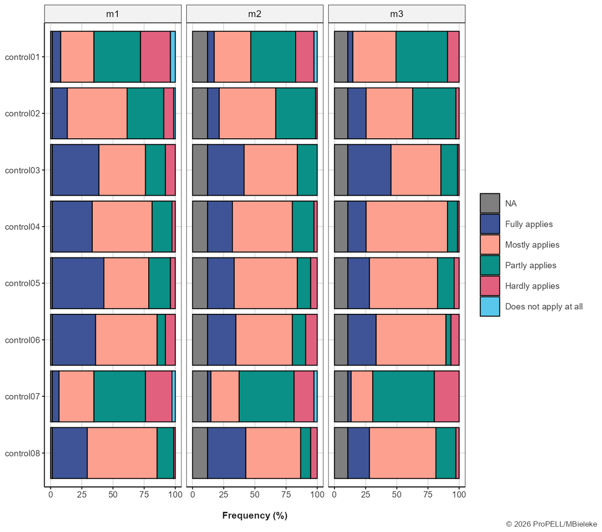

**Scale**

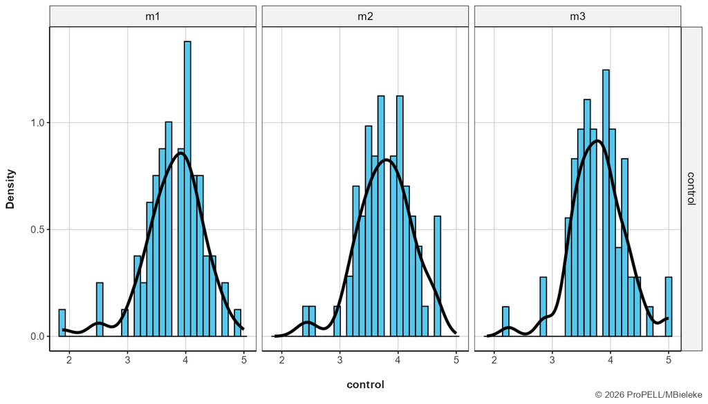

**Statistics**

**Items**

| Variable | N | #Valid | %Valid | Mean | SD | Min | Median | Max |
| --- | --- | --- | --- | --- | --- | --- | --- | --- |
| **control01** |  |  |  |  |  |  |  |  |
| m1 | 75 | 74 | 98.67 | 3.08 | 0.98 | 1 | 3 | 5 |
| m2 | 75 | 66 | 88.00 | 3.23 | 0.91 | 1 | 3 | 5 |
| m3 | 75 | 67 | 89.33 | 3.37 | 0.74 | 2 | 3 | 5 |
| **control02** |  |  |  |  |  |  |  |  |
| m1 | 75 | 74 | 98.67 | 3.62 | 0.86 | 1 | 4 | 5 |
| m2 | 75 | 66 | 88.00 | 3.71 | 0.67 | 2 | 4 | 5 |
| m3 | 75 | 67 | 89.33 | 3.72 | 0.77 | 2 | 4 | 5 |
| **control03** |  |  |  |  |  |  |  |  |
| m1 | 75 | 74 | 98.67 | 4.05 | 0.93 | 2 | 4 | 5 |
| m2 | 75 | 66 | 88.00 | 4.15 | 0.71 | 3 | 4 | 5 |
| m3 | 75 | 67 | 89.33 | 4.21 | 0.75 | 2 | 4 | 5 |
| **control04** |  |  |  |  |  |  |  |  |
| m1 | 75 | 74 | 98.67 | 4.11 | 0.77 | 2 | 4 | 5 |
| m2 | 75 | 66 | 88.00 | 3.97 | 0.74 | 2 | 4 | 5 |
| m3 | 75 | 67 | 89.33 | 4.04 | 0.56 | 2 | 4 | 5 |
| **control05** |  |  |  |  |  |  |  |  |
| m1 | 75 | 74 | 98.67 | 4.16 | 0.86 | 2 | 4 | 5 |
| m2 | 75 | 66 | 88.00 | 4.00 | 0.78 | 2 | 4 | 5 |
| m3 | 75 | 67 | 89.33 | 3.96 | 0.73 | 2 | 4 | 5 |
| **control06** |  |  |  |  |  |  |  |  |
| m1 | 75 | 74 | 98.67 | 4.12 | 0.86 | 2 | 4 | 5 |
| m2 | 75 | 66 | 88.00 | 3.92 | 0.90 | 2 | 4 | 5 |
| m3 | 75 | 67 | 89.33 | 4.06 | 0.78 | 2 | 4 | 5 |
| **control07** |  |  |  |  |  |  |  |  |
| m1 | 75 | 74 | 98.67 | 3.12 | 0.91 | 1 | 3 | 5 |
| m2 | 75 | 66 | 88.00 | 3.08 | 0.83 | 1 | 3 | 5 |
| m3 | 75 | 67 | 89.33 | 3.03 | 0.74 | 2 | 3 | 5 |
| **control08** |  |  |  |  |  |  |  |  |
| m1 | 75 | 74 | 98.67 | 4.12 | 0.68 | 2 | 4 | 5 |
| m2 | 75 | 66 | 88.00 | 4.14 | 0.82 | 2 | 4 | 5 |
| m3 | 75 | 67 | 89.33 | 3.96 | 0.71 | 2 | 4 | 5 |

**Scale**

| Variable | N | #Valid | %Valid | SD | Mean | Min | Median | Max | #Items | Alpha |
| --- | --- | --- | --- | --- | --- | --- | --- | --- | --- | --- |
| **control** |  |  |  |  |  |  |  |  |  |  |
| m1 | 75 | 74 | 98.67 | 0.51 | 3.80 | 1.88 | 3.88 | 4.88 | 8 | 0.73 |
| m2 | 75 | 66 | 88.00 | 0.47 | 3.77 | 2.38 | 3.75 | 4.62 | 8 | 0.72 |
| m3 | 75 | 67 | 89.33 | 0.47 | 3.79 | 2.25 | 3.75 | 5.00 | 8 | 0.80 |

### Overall DWBS mean score

**Overview**

- **Variable Stem: `dwbs`**
- **Time Points:** m1, m2, m3
- **Reference:** Bieleke et al. (2022)

**Details**

**Items**

**Directions**: The following statements refer to how you typically behave when you feel bored. Please read each statement and indicate how much it applies to you.

| Variable | Scale | Prompt |
| --- | --- | --- |
| dwbs01 | Maladaptive | When I am bored ... I do things that are generally known to be bad. |
| dwbs02 | Adaptive | When I am bored ... I do things that bring benefits in the long run. |
| dwbs03 | Adaptive | When I am bored ... I use my time doing something useful. |
| dwbs04 | Maladaptive | When I am bored ... I do nonsense. |
| dwbs05 | Adaptive | When I am bored ... I try to be productive. |
| dwbs06 | Maladaptive | When I am bored ... I do things that are fun, even if I might regret it later. |

Note. Variables with * have been reverse-coded

**Scale**

| Variable | Description |
| --- | --- |
| dwbs | Overall DWBS mean score |
| dwbsa | Mean score of Adaptive items |
| dwbsm | Mean score of Maladaptive items |

**Distribution**

**Items**

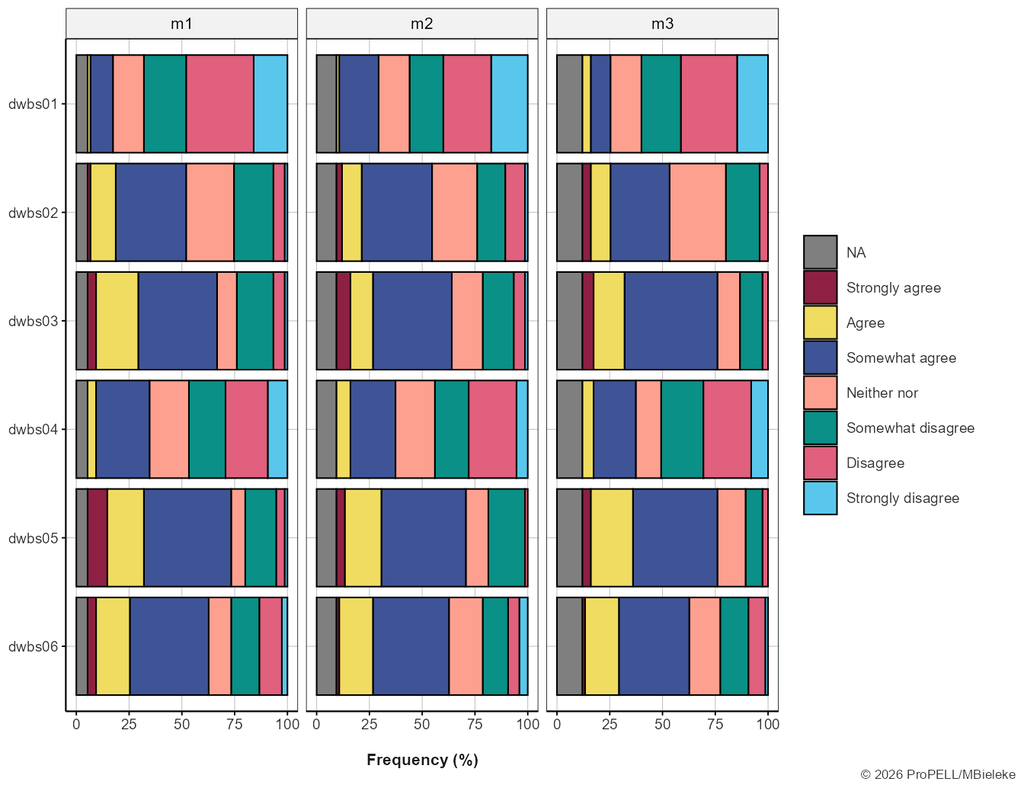

**Scale**

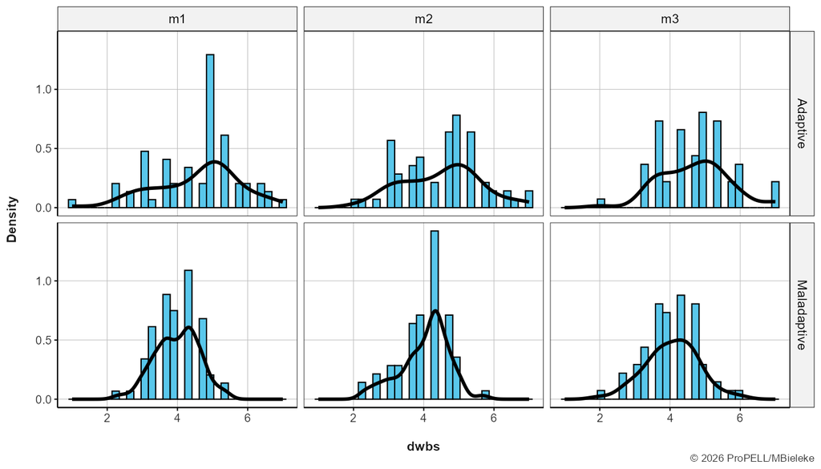

**Statistics**

**Items**

| Variable | N | #Valid | %Valid | Mean | SD | Min | Median | Max |
| --- | --- | --- | --- | --- | --- | --- | --- | --- |
| **dwbs01** |  |  |  |  |  |  |  |  |
| m1 | 75 | 71 | 94.67 | 2.75 | 1.31 | 1 | 2.0 | 6 |
| m2 | 75 | 68 | 90.67 | 2.99 | 1.47 | 1 | 3.0 | 6 |
| m3 | 75 | 66 | 88.00 | 2.88 | 1.41 | 1 | 3.0 | 6 |
| **dwbs02** |  |  |  |  |  |  |  |  |
| m1 | 75 | 71 | 94.67 | 4.30 | 1.21 | 1 | 4.0 | 7 |
| m2 | 75 | 68 | 90.67 | 4.26 | 1.30 | 1 | 4.5 | 7 |
| m3 | 75 | 66 | 88.00 | 4.39 | 1.18 | 2 | 4.0 | 7 |
| **dwbs03** |  |  |  |  |  |  |  |  |
| m1 | 75 | 71 | 94.67 | 4.61 | 1.35 | 1 | 5.0 | 7 |
| m2 | 75 | 68 | 90.67 | 4.54 | 1.34 | 1 | 5.0 | 7 |
| m3 | 75 | 66 | 88.00 | 4.83 | 1.13 | 2 | 5.0 | 7 |
| **dwbs04** |  |  |  |  |  |  |  |  |
| m1 | 75 | 71 | 94.67 | 3.45 | 1.44 | 1 | 4.0 | 6 |
| m2 | 75 | 68 | 90.67 | 3.53 | 1.43 | 1 | 4.0 | 6 |
| m3 | 75 | 66 | 88.00 | 3.33 | 1.46 | 1 | 3.0 | 6 |
| **dwbs05** |  |  |  |  |  |  |  |  |
| m1 | 75 | 71 | 94.67 | 4.82 | 1.37 | 1 | 5.0 | 7 |
| m2 | 75 | 68 | 90.67 | 4.74 | 1.15 | 2 | 5.0 | 7 |
| m3 | 75 | 66 | 88.00 | 4.89 | 1.10 | 2 | 5.0 | 7 |
| **dwbs06** |  |  |  |  |  |  |  |  |
| m1 | 75 | 71 | 94.67 | 4.41 | 1.47 | 1 | 5.0 | 7 |
| m2 | 75 | 68 | 90.67 | 4.41 | 1.36 | 1 | 5.0 | 7 |
| m3 | 75 | 66 | 88.00 | 4.41 | 1.32 | 1 | 5.0 | 7 |

**Scale**

| Variable | N | #Valid | %Valid | SD | Mean | Min | Median | Max | #Items | Alpha |
| --- | --- | --- | --- | --- | --- | --- | --- | --- | --- | --- |
| **dwbsa** |  |  |  |  |  |  |  |  |  |  |
| m1 | 75 | 71 | 94.67 | 1.21 | 4.57 | 1.00 | 5.00 | 7.00 | 3 | 0.91 |
| m2 | 75 | 68 | 90.67 | 1.12 | 4.51 | 2.00 | 4.67 | 7.00 | 3 | 0.86 |
| m3 | 75 | 66 | 88.00 | 0.98 | 4.71 | 2.00 | 4.67 | 7.00 | 3 | 0.83 |
| **dwbsm** |  |  |  |  |  |  |  |  |  |  |
| m1 | 75 | 71 | 94.67 | 0.63 | 3.99 | 2.33 | 4.00 | 5.33 | 3 | 0.62 |
| m2 | 75 | 68 | 90.67 | 0.69 | 4.04 | 2.33 | 4.33 | 5.67 | 3 | 0.68 |
| m3 | 75 | 66 | 88.00 | 0.76 | 4.06 | 2.00 | 4.00 | 6.00 | 3 | 0.77 |

### No overall ERQ score is computed

**Overview**

- **Variable Stem: `erq`**
- **Time Points:** m1, m2, m3
- **Reference:** Gross & John (2003)

**Details**

**Items**

**Directions**: We would like to ask you some questions about your emotions. We are interested in how you control or regulate your emotions. Two aspects of your emotions are of particular interest. On the one hand, this concerns your emotional experience, that is, what you feel internally. On the other hand, it concerns emotional expression, that is, how you express your emotions outwardly through words, gestures, or behavior. Although some of the questions may sound quite similar, they differ in important ways. Please answer the questions using the response options provided.

| Variable | Scale | Prompt |
| --- | --- | --- |
| erq01 | Reappraisal | When I want to feel more positive emotion (such as joy or amusement), I change what I’m thinking about. |
| erq02 | Suppression | I keep my emotions to myself. |
| erq03 | Reappraisal | When I want to feel less negative emotion (such as sadness or anger), I change what I’m thinking about. |
| erq04 | Reappraisal | When I am feeling positive emotions, I am careful not to express them. |
| erq05 | Reappraisal | When I’m faced with a stressful situation, I make myself think about it in a way that helps me stay calm. |
| erq06 | Suppression | I control my emotions by not expressing them. |
| erq07 | Reappraisal | When I want to feel more positive emotion, I change the way I’m thinking about the situation. |
| erq08 | Suppression | I control my emotions by changing the way I think about the situation I’m in. |
| erq09 | Suppression | When I am feeling negative emotions, I make sure not to express them. |
| erq10 | Reappraisal | When I want to feel less negative emotion, I change the way I’m thinking about the situation. |

Note. Variables with * have been reverse-coded

**Scale**

| Variable | Description |
| --- | --- |
| erq | No overall ERQ score is computed |
| erqrea | Mean score of Reappraisal items |
| erqsup | Mean score of Suppression items |

**Distribution**

**Items**

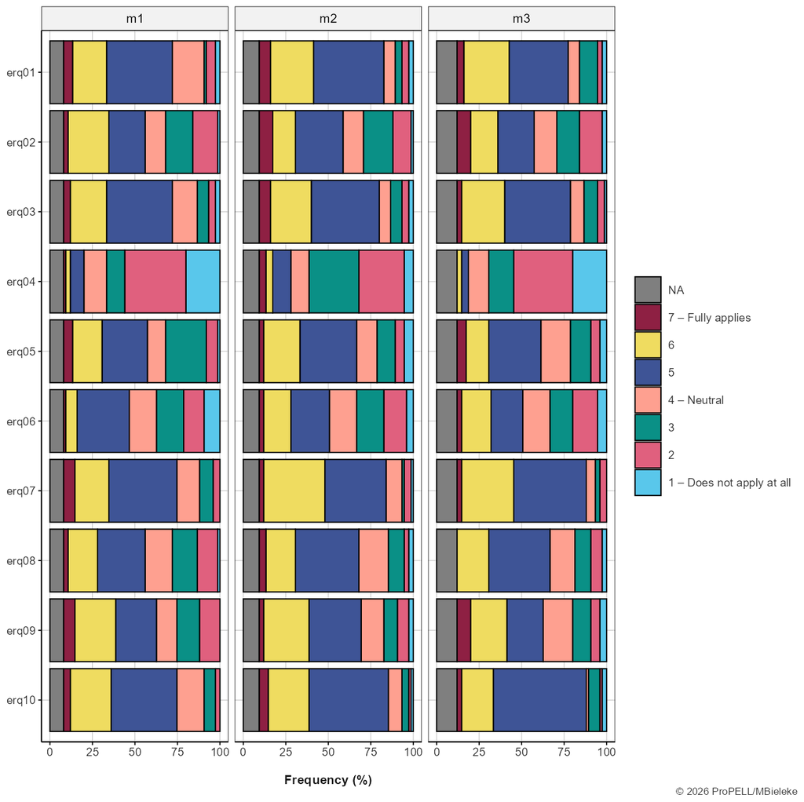

**Scale**

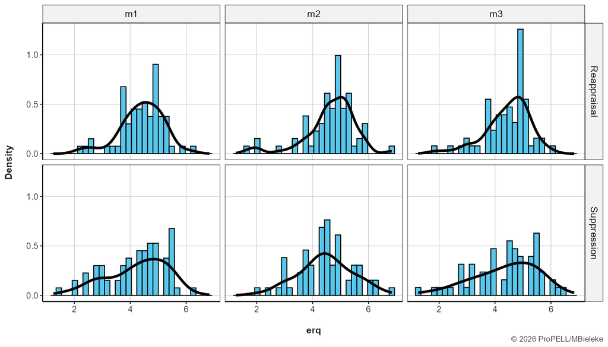

**Statistics**

**Items**

| Variable | N | #Valid | %Valid | Mean | SD | Min | Median | Max |
| --- | --- | --- | --- | --- | --- | --- | --- | --- |
| **erq01** |  |  |  |  |  |  |  |  |
| m1 | 75 | 69 | 92.00 | 4.81 | 1.30 | 1 | 5 | 7 |
| m2 | 75 | 68 | 90.67 | 5.01 | 1.31 | 1 | 5 | 7 |
| m3 | 75 | 66 | 88.00 | 4.86 | 1.35 | 1 | 5 | 7 |
| **erq02** |  |  |  |  |  |  |  |  |
| m1 | 75 | 69 | 92.00 | 4.30 | 1.56 | 1 | 5 | 7 |
| m2 | 75 | 68 | 90.67 | 4.40 | 1.54 | 1 | 5 | 7 |
| m3 | 75 | 66 | 88.00 | 4.33 | 1.66 | 1 | 5 | 7 |
| **erq03** |  |  |  |  |  |  |  |  |
| m1 | 75 | 69 | 92.00 | 4.77 | 1.30 | 1 | 5 | 7 |
| m2 | 75 | 68 | 90.67 | 4.94 | 1.35 | 1 | 5 | 7 |
| m3 | 75 | 66 | 88.00 | 4.88 | 1.23 | 1 | 5 | 7 |
| **erq04** |  |  |  |  |  |  |  |  |
| m1 | 75 | 69 | 92.00 | 2.64 | 1.46 | 1 | 2 | 7 |
| m2 | 75 | 68 | 90.67 | 3.25 | 1.48 | 1 | 3 | 7 |
| m3 | 75 | 66 | 88.00 | 2.47 | 1.28 | 1 | 2 | 6 |
| **erq05** |  |  |  |  |  |  |  |  |
| m1 | 75 | 69 | 92.00 | 4.39 | 1.46 | 1 | 5 | 7 |
| m2 | 75 | 68 | 90.67 | 4.51 | 1.49 | 1 | 5 | 7 |
| m3 | 75 | 66 | 88.00 | 4.44 | 1.46 | 1 | 5 | 7 |
| **erq06** |  |  |  |  |  |  |  |  |
| m1 | 75 | 69 | 92.00 | 3.78 | 1.53 | 1 | 4 | 7 |
| m2 | 75 | 68 | 90.67 | 4.09 | 1.55 | 1 | 4 | 7 |
| m3 | 75 | 66 | 88.00 | 4.03 | 1.64 | 1 | 4 | 7 |
| **erq07** |  |  |  |  |  |  |  |  |
| m1 | 75 | 69 | 92.00 | 4.91 | 1.18 | 2 | 5 | 7 |
| m2 | 75 | 68 | 90.67 | 5.13 | 1.14 | 1 | 5 | 7 |
| m3 | 75 | 66 | 88.00 | 5.15 | 1.03 | 2 | 5 | 7 |
| **erq08** |  |  |  |  |  |  |  |  |
| m1 | 75 | 69 | 92.00 | 4.30 | 1.44 | 1 | 5 | 7 |
| m2 | 75 | 68 | 90.67 | 4.68 | 1.27 | 1 | 5 | 7 |
| m3 | 75 | 66 | 88.00 | 4.48 | 1.32 | 1 | 5 | 6 |
| **erq09** |  |  |  |  |  |  |  |  |
| m1 | 75 | 69 | 92.00 | 4.59 | 1.52 | 2 | 5 | 7 |
| m2 | 75 | 68 | 90.67 | 4.69 | 1.41 | 1 | 5 | 7 |
| m3 | 75 | 66 | 88.00 | 4.62 | 1.57 | 1 | 5 | 7 |
| **erq10** |  |  |  |  |  |  |  |  |
| m1 | 75 | 69 | 92.00 | 4.94 | 1.08 | 2 | 5 | 7 |
| m2 | 75 | 68 | 90.67 | 5.10 | 1.07 | 1 | 5 | 7 |
| m3 | 75 | 66 | 88.00 | 4.94 | 1.14 | 1 | 5 | 7 |

**Scale**

| Variable | N | #Valid | %Valid | SD | Mean | Min | Median | Max | #Items | Alpha |
| --- | --- | --- | --- | --- | --- | --- | --- | --- | --- | --- |
| **erqrea** |  |  |  |  |  |  |  |  |  |  |
| m1 | 75 | 69 | 92.00 | 0.77 | 4.41 | 2.17 | 4.50 | 6.17 | 6 | 0.63 |
| m2 | 75 | 68 | 90.67 | 0.91 | 4.66 | 1.67 | 4.83 | 6.83 | 6 | 0.78 |
| m3 | 75 | 66 | 88.00 | 0.79 | 4.46 | 1.83 | 4.58 | 6.00 | 6 | 0.70 |
| **erqsup** |  |  |  |  |  |  |  |  |  |  |
| m1 | 75 | 69 | 92.00 | 1.07 | 4.25 | 1.50 | 4.50 | 6.25 | 4 | 0.67 |
| m2 | 75 | 68 | 90.67 | 0.97 | 4.46 | 2.00 | 4.50 | 6.75 | 4 | 0.59 |
| m3 | 75 | 66 | 88.00 | 1.16 | 4.37 | 1.25 | 4.50 | 6.50 | 4 | 0.74 |

### Overall ESES mean score

**Overview**

- **Variable Stem: `eses`**
- **Time Points:** m1, m2, m3
- **Reference:** Nigg & Riebe (2002)

**Details**

**Items**

**Directions**: This section is about how confident you are in your ability to exercise under different conditions. Please read the following statements and indicate the extent to which each statement applies to you.

| Variable | Scale | Prompt |
| --- | --- | --- |
| eses01 | Negative Affect | I am confident I can participate in regular exercise when ... I am under a lot of stress. |
| eses02 | Negative Affect | I am confident I can participate in regular exercise when ... I am depressed. |
| eses03 | Negative Affect | I am confident I can participate in regular exercise when ... I am anxious. |
| eses04 | Excuse Making | I am confident I can participate in regular exercise when ... I feel I don’t have the time. |
| eses05 | Excuse Making | I am confident I can participate in regular exercise when ... I don’t feel like it. |
| eses06 | Excuse Making | I am confident I can participate in regular exercise when ... I am busy. |
| eses07 | Must Exercise Alone | I am confident I can participate in regular exercise when ... I am alone. |
| eses08 | Must Exercise Alone | I am confident I can participate in regular exercise when ... I have to exercise alone. |
| eses09 | Must Exercise Alone | I am confident I can participate in regular exercise when ... My exercise partner decides not to exercise that day. |
| eses10 | Inconvenient to Exercise | I am confident I can participate in regular exercise when ... I don’t have access to exercise equipment. |
| eses11 | Inconvenient to Exercise | I am confident I can participate in regular exercise when ... I am traveling. |
| eses12 | Inconvenient to Exercise | I am confident I can participate in regular exercise when ... My gym is closed. |
| eses13 | Resistance from Others | I am confident I can participate in regular exercise when ... My friends don’t want me to exercise. |
| eses14 | Resistance from Others | I am confident I can participate in regular exercise when ... My significant other does not want me to exercise. |
| eses15 | Resistance from Others | I am confident I can participate in regular exercise when ... I am spending time with friends or family who do not exercise. |
| eses16 | Bad Weather | I am confident I can participate in regular exercise when ... It’s raining or snowing. |
| eses17 | Bad Weather | I am confident I can participate in regular exercise when ... It’s cold outside. |
| eses18 | Bad Weather | I am confident I can participate in regular exercise when ... The roads or sidewalks are snowy. |

Note. Variables with * have been reverse-coded

**Scale**

| Variable | Description |
| --- | --- |
| eses | Overall ESES mean score |

**Distribution**

**Items**

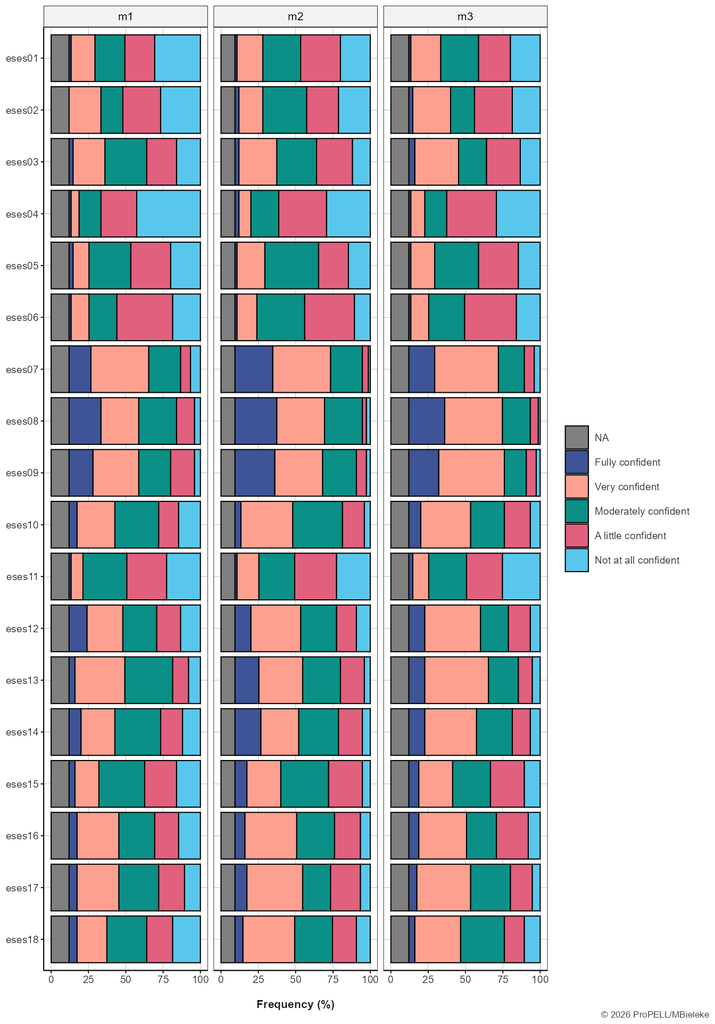

**Scale**

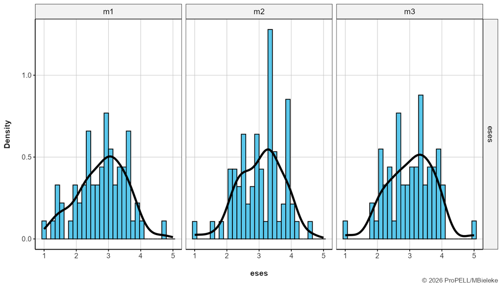

**Statistics**

**Items**

| Variable | N | #Valid | %Valid | Mean | SD | Min | Median | Max |
| --- | --- | --- | --- | --- | --- | --- | --- | --- |
| **eses01** |  |  |  |  |  |  |  |  |
| m1 | 75 | 66 | 88.00 | 2.29 | 1.17 | 1 | 2.0 | 5 |
| m2 | 75 | 68 | 90.67 | 2.49 | 1.09 | 1 | 2.0 | 5 |
| m3 | 75 | 66 | 88.00 | 2.56 | 1.12 | 1 | 3.0 | 5 |
| **eses02** |  |  |  |  |  |  |  |  |
| m1 | 75 | 66 | 88.00 | 2.35 | 1.16 | 1 | 2.0 | 4 |
| m2 | 75 | 68 | 90.67 | 2.53 | 1.13 | 1 | 3.0 | 5 |
| m3 | 75 | 66 | 88.00 | 2.64 | 1.20 | 1 | 2.5 | 5 |
| **eses03** |  |  |  |  |  |  |  |  |
| m1 | 75 | 66 | 88.00 | 2.71 | 1.12 | 1 | 3.0 | 5 |
| m2 | 75 | 68 | 90.67 | 2.81 | 1.08 | 1 | 3.0 | 5 |
| m3 | 75 | 66 | 88.00 | 2.86 | 1.18 | 1 | 3.0 | 5 |
| **eses04** |  |  |  |  |  |  |  |  |
| m1 | 75 | 66 | 88.00 | 1.85 | 1.01 | 1 | 2.0 | 5 |
| m2 | 75 | 68 | 90.67 | 2.15 | 1.07 | 1 | 2.0 | 5 |
| m3 | 75 | 66 | 88.00 | 2.09 | 1.03 | 1 | 2.0 | 5 |
| **eses05** |  |  |  |  |  |  |  |  |
| m1 | 75 | 66 | 88.00 | 2.42 | 1.07 | 1 | 2.0 | 5 |
| m2 | 75 | 68 | 90.67 | 2.69 | 1.03 | 1 | 3.0 | 5 |
| m3 | 75 | 66 | 88.00 | 2.58 | 1.02 | 1 | 3.0 | 5 |
| **eses06** |  |  |  |  |  |  |  |  |
| m1 | 75 | 66 | 88.00 | 2.32 | 1.01 | 1 | 2.0 | 5 |
| m2 | 75 | 68 | 90.67 | 2.57 | 0.94 | 1 | 3.0 | 5 |
| m3 | 75 | 66 | 88.00 | 2.41 | 0.99 | 1 | 2.0 | 5 |
| **eses07** |  |  |  |  |  |  |  |  |
| m1 | 75 | 66 | 88.00 | 3.55 | 1.10 | 1 | 4.0 | 5 |
| m2 | 75 | 68 | 90.67 | 3.91 | 0.91 | 1 | 4.0 | 5 |
| m3 | 75 | 66 | 88.00 | 3.71 | 1.02 | 1 | 4.0 | 5 |
| **eses08** |  |  |  |  |  |  |  |  |
| m1 | 75 | 66 | 88.00 | 3.55 | 1.14 | 1 | 4.0 | 5 |
| m2 | 75 | 68 | 90.67 | 3.88 | 0.99 | 1 | 4.0 | 5 |
| m3 | 75 | 66 | 88.00 | 3.89 | 0.93 | 1 | 4.0 | 5 |
| **eses09** |  |  |  |  |  |  |  |  |
| m1 | 75 | 66 | 88.00 | 3.44 | 1.12 | 1 | 4.0 | 5 |
| m2 | 75 | 68 | 90.67 | 3.81 | 1.04 | 1 | 4.0 | 5 |
| m3 | 75 | 66 | 88.00 | 3.82 | 0.98 | 1 | 4.0 | 5 |
| **eses10** |  |  |  |  |  |  |  |  |
| m1 | 75 | 66 | 88.00 | 2.92 | 1.17 | 1 | 3.0 | 5 |
| m2 | 75 | 68 | 90.67 | 3.22 | 0.93 | 1 | 3.0 | 5 |
| m3 | 75 | 66 | 88.00 | 3.21 | 1.10 | 1 | 3.0 | 5 |
| **eses11** |  |  |  |  |  |  |  |  |
| m1 | 75 | 66 | 88.00 | 2.30 | 1.01 | 1 | 2.0 | 5 |
| m2 | 75 | 68 | 90.67 | 2.38 | 1.08 | 1 | 2.0 | 5 |
| m3 | 75 | 66 | 88.00 | 2.33 | 1.11 | 1 | 2.0 | 5 |
| **eses12** |  |  |  |  |  |  |  |  |
| m1 | 75 | 66 | 88.00 | 3.06 | 1.28 | 1 | 3.0 | 5 |
| m2 | 75 | 68 | 90.67 | 3.25 | 1.16 | 1 | 3.0 | 5 |
| m3 | 75 | 66 | 88.00 | 3.35 | 1.13 | 1 | 4.0 | 5 |
| **eses13** |  |  |  |  |  |  |  |  |
| m1 | 75 | 66 | 88.00 | 3.17 | 1.02 | 1 | 3.0 | 5 |
| m2 | 75 | 68 | 90.67 | 3.41 | 1.11 | 1 | 3.5 | 5 |
| m3 | 75 | 66 | 88.00 | 3.50 | 1.04 | 1 | 4.0 | 5 |
| **eses14** |  |  |  |  |  |  |  |  |
| m1 | 75 | 66 | 88.00 | 3.00 | 1.16 | 1 | 3.0 | 5 |
| m2 | 75 | 68 | 90.67 | 3.37 | 1.16 | 1 | 3.0 | 5 |
| m3 | 75 | 66 | 88.00 | 3.35 | 1.10 | 1 | 4.0 | 5 |
| **eses15** |  |  |  |  |  |  |  |  |
| m1 | 75 | 66 | 88.00 | 2.67 | 1.11 | 1 | 3.0 | 5 |
| m2 | 75 | 68 | 90.67 | 3.06 | 1.05 | 1 | 3.0 | 5 |
| m3 | 75 | 66 | 88.00 | 2.91 | 1.15 | 1 | 3.0 | 5 |
| **eses16** |  |  |  |  |  |  |  |  |
| m1 | 75 | 66 | 88.00 | 2.92 | 1.19 | 1 | 3.0 | 5 |
| m2 | 75 | 68 | 90.67 | 3.19 | 1.07 | 1 | 3.0 | 5 |
| m3 | 75 | 66 | 88.00 | 3.09 | 1.13 | 1 | 3.0 | 5 |
| **eses17** |  |  |  |  |  |  |  |  |
| m1 | 75 | 66 | 88.00 | 3.00 | 1.12 | 1 | 3.0 | 5 |
| m2 | 75 | 68 | 90.67 | 3.22 | 1.12 | 1 | 3.5 | 5 |
| m3 | 75 | 66 | 88.00 | 3.24 | 1.01 | 1 | 3.0 | 5 |
| **eses18** |  |  |  |  |  |  |  |  |
| m1 | 75 | 66 | 88.00 | 2.73 | 1.21 | 1 | 3.0 | 5 |
| m2 | 75 | 68 | 90.67 | 3.12 | 1.10 | 1 | 3.0 | 5 |
| m3 | 75 | 66 | 88.00 | 3.05 | 1.09 | 1 | 3.0 | 5 |

**Scale**

| Variable | N | #Valid | %Valid | SD | Mean | Min | Median | Max | #Items | Alpha |
| --- | --- | --- | --- | --- | --- | --- | --- | --- | --- | --- |
| **eses** |  |  |  |  |  |  |  |  |  |  |
| m1 | 75 | 66 | 88.00 | 0.76 | 2.79 | 1.00 | 2.89 | 4.67 | 18 | 0.93 |
| m2 | 75 | 68 | 90.67 | 0.68 | 3.06 | 1.00 | 3.11 | 4.61 | 18 | 0.92 |
| m3 | 75 | 66 | 88.00 | 0.71 | 3.03 | 1.06 | 3.06 | 5.00 | 18 | 0.92 |

### German Single-Item Self-Esteem (G-SISE) Scale

**Overview**

- **Variable Stem: `esteem`**
- **Time Points:** m1, m2, m3
- **Reference:** Brailovskaia & Margraf (2020)

**Details**

Please indicate to what extent the following statement applies to you: “I have high self-esteem.”

**Distribution**

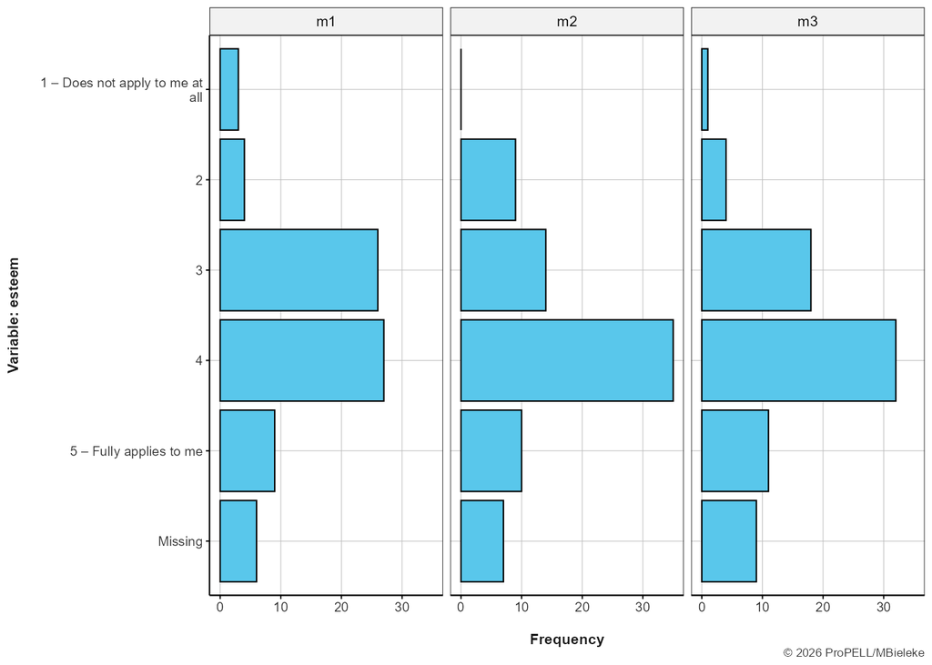

**Statistics**

| Answer | N | % | %Val |
| --- | --- | --- | --- |
| 1 – Does not apply to me at all |  |  |  |
| m1 | 3 | 4.0 | 4.3 |
| m2 | 0 | 0.0 | 0.0 |
| m3 | 1 | 1.3 | 1.5 |
| **2** |  |  |  |
| m1 | 4 | 5.3 | 5.8 |
| m2 | 9 | 12.0 | 13.2 |
| m3 | 4 | 5.3 | 6.1 |
| **3** |  |  |  |
| m1 | 26 | 34.7 | 37.7 |
| m2 | 14 | 18.7 | 20.6 |
| m3 | 18 | 24.0 | 27.3 |
| **4** |  |  |  |
| m1 | 27 | 36.0 | 39.1 |
| m2 | 35 | 46.7 | 51.5 |
| m3 | 32 | 42.7 | 48.5 |
| **5 – Fully applies to me** |  |  |  |
| m1 | 9 | 12.0 | 13.0 |
| m2 | 10 | 13.3 | 14.7 |
| m3 | 11 | 14.7 | 16.7 |
| **Missing** |  |  |  |
| m1 | 6 | 8.0 | --- |
| m2 | 7 | 9.3 | --- |
| m3 | 9 | 12.0 | --- |

### Subjective rating of physical fitness

**Overview**

- **Variable Stem: `fit`**
- **Time Points:** m1, m2, m3
- **Reference:** Petersen et al. (2021)

**Details**

How do you rate your own physical fitness?

**Distribution**

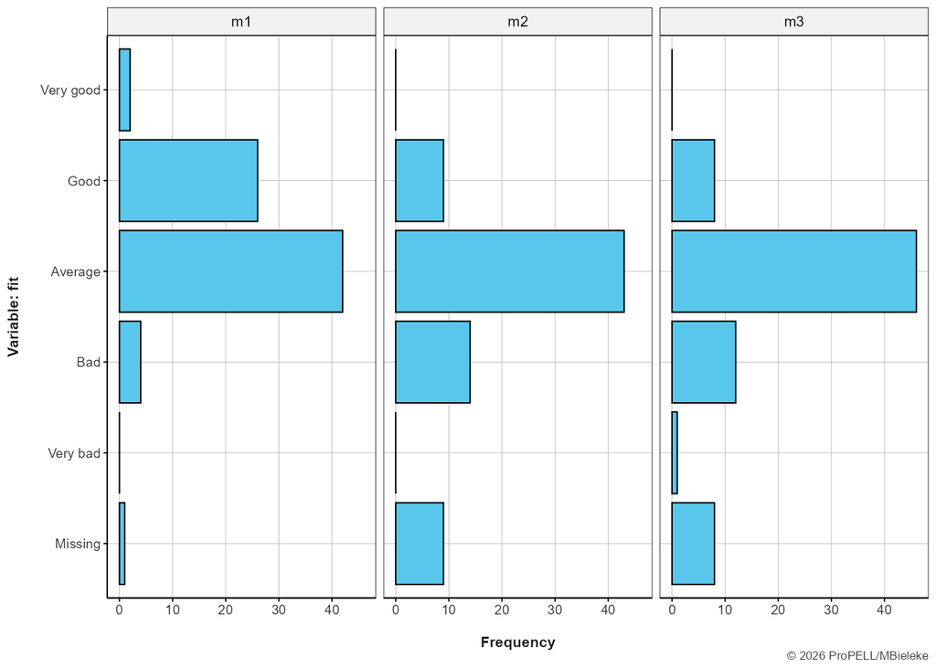

**Statistics**

| Answer | N | % | %Val |
| --- | --- | --- | --- |
| **Very good** |  |  |  |
| m1 | 2 | 2.7 | 2.7 |
| m2 | 0 | 0.0 | 0.0 |
| m3 | 0 | 0.0 | 0.0 |
| **Good** |  |  |  |
| m1 | 26 | 34.7 | 35.1 |
| m2 | 9 | 12.0 | 13.6 |
| m3 | 8 | 10.7 | 11.9 |
| **Average** |  |  |  |
| m1 | 42 | 56.0 | 56.8 |
| m2 | 43 | 57.3 | 65.2 |
| m3 | 46 | 61.3 | 68.7 |
| **Bad** |  |  |  |
| m1 | 4 | 5.3 | 5.4 |
| m2 | 14 | 18.7 | 21.2 |
| m3 | 12 | 16.0 | 17.9 |
| **Very bad** |  |  |  |
| m1 | 0 | 0.0 | 0.0 |
| m2 | 0 | 0.0 | 0.0 |
| m3 | 1 | 1.3 | 1.5 |
| **Missing** |  |  |  |
| m1 | 1 | 1.3 | --- |
| m2 | 9 | 12.0 | --- |
| m3 | 8 | 10.7 | --- |

### No overall GROE score is computed

**Overview**

- **Variable Stem: `groe`**
- **Time Points:** m1, m2, m3
- **Reference:** Custom scale

**Details**

**Items**

**Directions**: The following statements refer to sports activities that are physically demanding. The term physical exertion refers to your perception of how hard, strenuous, and challenging sports activities are. Please read each statement and indicate the extent to which it generally applies to you.

| Variable | Scale | Prompt |
| --- | --- | --- |
| groe01 | Instrument | I exert myself during sports activities because it helps me achieve my goals. |
| groe02 | Instrument | I am satisfied when it is worth exerting myself during a sports activity. |
| groe03 | Value | I exert myself during sports activities because I enjoy the physical exertion. |
| groe04 | Value | I like it when I can fully push myself to my limits during a sports activity. |
| groe05 | Product | I exert myself during sports activities because physical exertion makes my achievements more rewarding. |
| groe06 | Product | The more I have exerted myself during sports activities, the more I celebrate my achievements. |

Note. Variables with * have been reverse-coded

**Scale**

| Variable | Description |
| --- | --- |
| groe | No overall GROE score is computed |
| groei | Mean score of Instrument items |
| groep | Mean score of Product items |
| groev | Mean score of Value items |

**Distribution**

**Items**

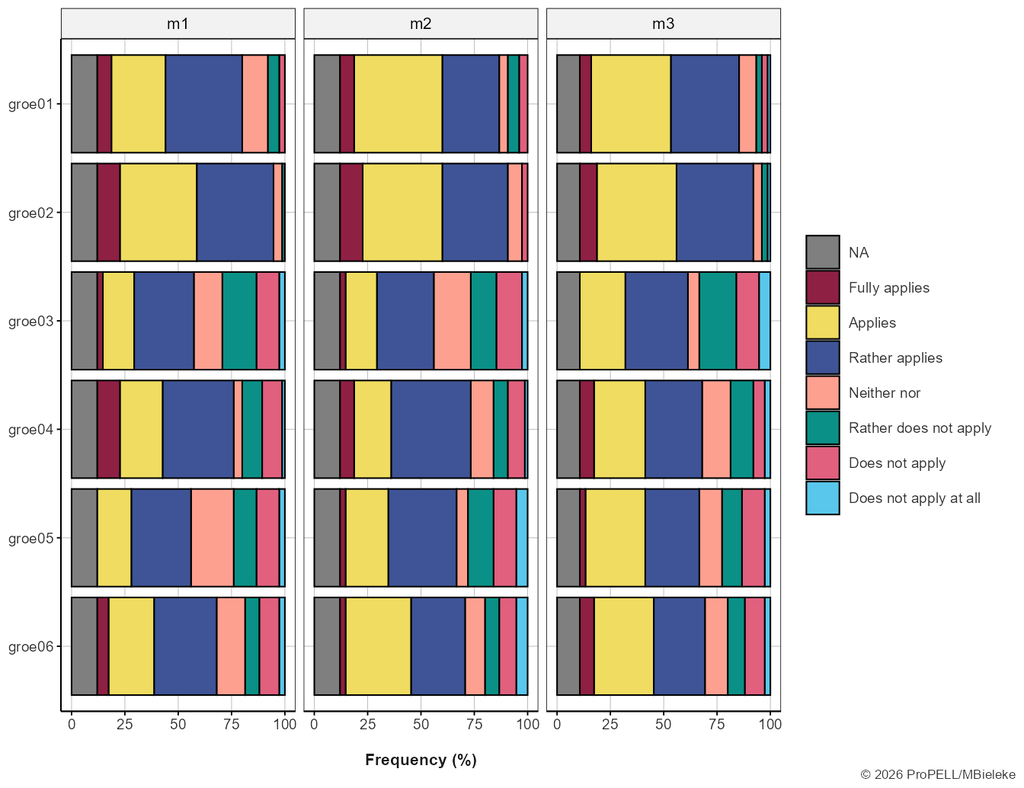

**Scale**

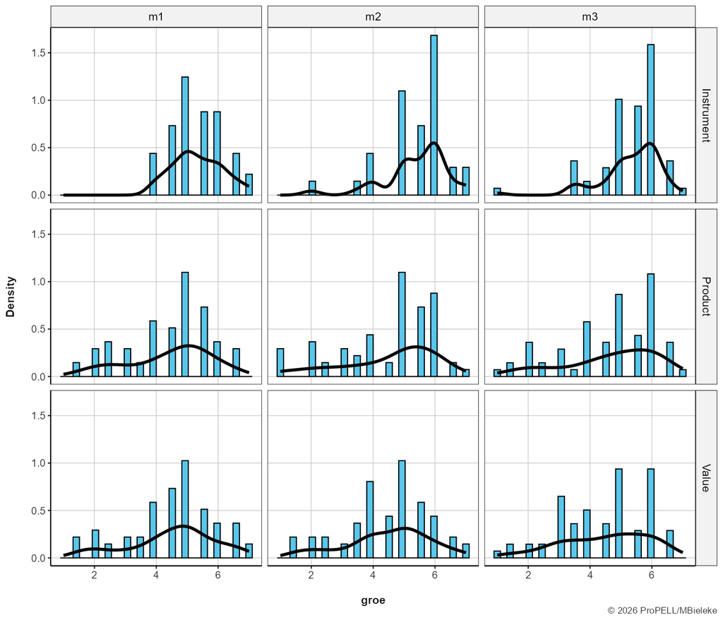

**Statistics**

**Items**

| Variable | N | #Valid | %Valid | Mean | SD | Min | Median | Max |
| --- | --- | --- | --- | --- | --- | --- | --- | --- |
| **groe01** |  |  |  |  |  |  |  |  |
| m1 | 75 | 66 | 88.00 | 5.09 | 1.12 | 2 | 5.0 | 7 |
| m2 | 75 | 66 | 88.00 | 5.32 | 1.18 | 2 | 6.0 | 7 |
| m3 | 75 | 67 | 89.33 | 5.24 | 1.16 | 1 | 5.0 | 7 |
| **groe02** |  |  |  |  |  |  |  |  |
| m1 | 75 | 66 | 88.00 | 5.58 | 0.82 | 3 | 6.0 | 7 |
| m2 | 75 | 66 | 88.00 | 5.50 | 1.01 | 2 | 6.0 | 7 |
| m3 | 75 | 67 | 89.33 | 5.43 | 1.00 | 1 | 6.0 | 7 |
| **groe03** |  |  |  |  |  |  |  |  |
| m1 | 75 | 66 | 88.00 | 4.23 | 1.48 | 1 | 5.0 | 7 |
| m2 | 75 | 66 | 88.00 | 4.23 | 1.48 | 1 | 4.5 | 7 |
| m3 | 75 | 67 | 89.33 | 4.19 | 1.58 | 1 | 5.0 | 6 |
| **groe04** |  |  |  |  |  |  |  |  |
| m1 | 75 | 66 | 88.00 | 4.83 | 1.55 | 1 | 5.0 | 7 |
| m2 | 75 | 66 | 88.00 | 4.74 | 1.40 | 1 | 5.0 | 7 |
| m3 | 75 | 67 | 89.33 | 4.73 | 1.47 | 1 | 5.0 | 7 |
| **groe05** |  |  |  |  |  |  |  |  |
| m1 | 75 | 66 | 88.00 | 4.23 | 1.38 | 1 | 4.5 | 6 |
| m2 | 75 | 66 | 88.00 | 4.35 | 1.62 | 1 | 5.0 | 7 |
| m3 | 75 | 67 | 89.33 | 4.57 | 1.54 | 1 | 5.0 | 7 |
| **groe06** |  |  |  |  |  |  |  |  |
| m1 | 75 | 66 | 88.00 | 4.62 | 1.51 | 1 | 5.0 | 7 |
| m2 | 75 | 66 | 88.00 | 4.64 | 1.60 | 1 | 5.0 | 7 |
| m3 | 75 | 67 | 89.33 | 4.73 | 1.57 | 1 | 5.0 | 7 |

**Scale**

| Variable | N | #Valid | %Valid | SD | Mean | Min | Median | Max | #Items | Alpha |
| --- | --- | --- | --- | --- | --- | --- | --- | --- | --- | --- |
| **groei** |  |  |  |  |  |  |  |  |  |  |
| m1 | 75 | 66 | 88.00 | 0.80 | 5.33 | 4.0 | 5.25 | 7.0 | 2 | 0.49 |
| m2 | 75 | 66 | 88.00 | 1.02 | 5.41 | 2.0 | 5.50 | 7.0 | 2 | 0.85 |
| m3 | 75 | 67 | 89.33 | 0.98 | 5.34 | 1.0 | 5.50 | 7.0 | 2 | 0.78 |
| **groep** |  |  |  |  |  |  |  |  |  |  |
| m1 | 75 | 66 | 88.00 | 1.34 | 4.42 | 1.5 | 5.00 | 6.5 | 2 | 0.84 |
| m2 | 75 | 66 | 88.00 | 1.55 | 4.49 | 1.0 | 5.00 | 7.0 | 2 | 0.92 |
| m3 | 75 | 67 | 89.33 | 1.50 | 4.65 | 1.0 | 5.00 | 7.0 | 2 | 0.93 |
| **groev** |  |  |  |  |  |  |  |  |  |  |
| m1 | 75 | 66 | 88.00 | 1.39 | 4.53 | 1.5 | 4.75 | 7.0 | 2 | 0.82 |
| m2 | 75 | 66 | 88.00 | 1.36 | 4.48 | 1.5 | 4.75 | 7.0 | 2 | 0.88 |
| m3 | 75 | 67 | 89.33 | 1.40 | 4.46 | 1.0 | 5.00 | 6.5 | 2 | 0.82 |

### IPAQ-SF 7 days - MET minutes

**Overview**

- **Variable Stem: `ipaq7`**
- **Time Points:** m1, m3
- **Reference:** Craig et al. (2003)

**Note:** The IPAQ has additionally been assessed in two state questionnaire accompanying the amubulatory assessments.

**Details**

We are interested in finding out what types of physical activities you perform in your daily life. The following questions refer to the time you spent on physical activity during the last 7 days. Please answer all questions (even if you do not consider yourself an active person). Please include activities as part of your work, in the house and garden, to get from one place to another, and in your leisure time for recreation, fitness, and sport. In the following, think about all your strenuous and moderate activities during the past 7 days. Strenuous activities refer to activities that require hard physical effort and make you breathe much harder than normal. Moderate activities refer to activities that require moderate physical effort and make you breathe somewhat harder than normal.

**Distribution**

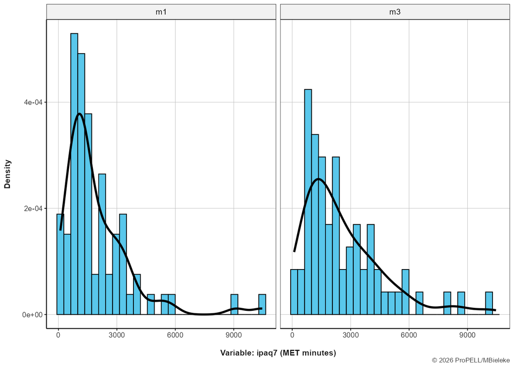

**Statistics**

| Time | N | % | %Val | Mean | SD | Min | Median | Max |
| --- | --- | --- | --- | --- | --- | --- | --- | --- |
| m1 | 75 | 74 | 98.67 | 1968.96 | 1811.48 | 99 | 1390 | 10462 |
| m3 | 75 | 66 | 88.00 | 2591.10 | 2048.61 | 179 | 2043 | 10158 |

### IPAQ-SF 7 days - Frequency of moderate activity

**Overview**

- **Variable Stem: `ipaq7m01`**
- **Time Points:** m1, m3
- **Reference:** Craig et al. (2003)

**Note:** The IPAQ has additionally been assessed in two state questionnaire accompanying the amubulatory assessments.

**Details**

Please think again only about the physical activities that you performed for at least 10 minutes without interruption. On how many of the past 7 days did you perform moderate physical activities, such as carrying light loads, cycling at a regular pace, or swimming at a regular pace? Do not include walking.

**Distribution**

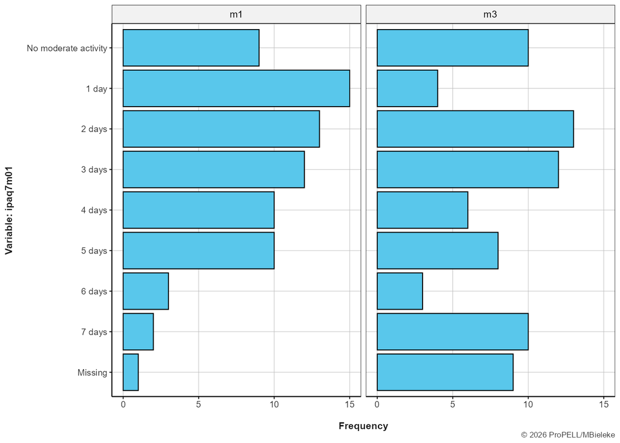

**Statistics**

| Answer | N | % | %Val |
| --- | --- | --- | --- |
| **No moderate activity** |  |  |  |
| m1 | 9 | 12.0 | 12.2 |
| m3 | 10 | 13.3 | 15.2 |
| **1 day** |  |  |  |
| m1 | 15 | 20.0 | 20.3 |
| m3 | 4 | 5.3 | 6.1 |
| **2 days** |  |  |  |
| m1 | 13 | 17.3 | 17.6 |
| m3 | 13 | 17.3 | 19.7 |
| **3 days** |  |  |  |
| m1 | 12 | 16.0 | 16.2 |
| m3 | 12 | 16.0 | 18.2 |
| **4 days** |  |  |  |
| m1 | 10 | 13.3 | 13.5 |
| m3 | 6 | 8.0 | 9.1 |
| **5 days** |  |  |  |
| m1 | 10 | 13.3 | 13.5 |
| m3 | 8 | 10.7 | 12.1 |
| **6 days** |  |  |  |
| m1 | 3 | 4.0 | 4.0 |
| m3 | 3 | 4.0 | 4.6 |
| **7 days** |  |  |  |
| m1 | 2 | 2.7 | 2.7 |
| m3 | 10 | 13.3 | 15.2 |
| **Missing** |  |  |  |
| m1 | 1 | 1.3 | --- |
| m3 | 9 | 12.0 | --- |

### IPAQ-SF 7 days - Duration of moderate activity

**Overview**

- **Variable Stem: `ipaq7m02`**
- **Time Points:** m1, m3
- **Reference:** Craig et al. (2003)

**Note:** The IPAQ has additionally been assessed in two state questionnaire accompanying the amubulatory assessments.

**Details**

How much time did you usually spend on one of those days doing moderate physical activity? Please enter the duration in hours:minutes. For example: 40 minutes ==> 00:40 / one hour ==> 01:00 / two and a half hours ==> 02:30

**Distribution**

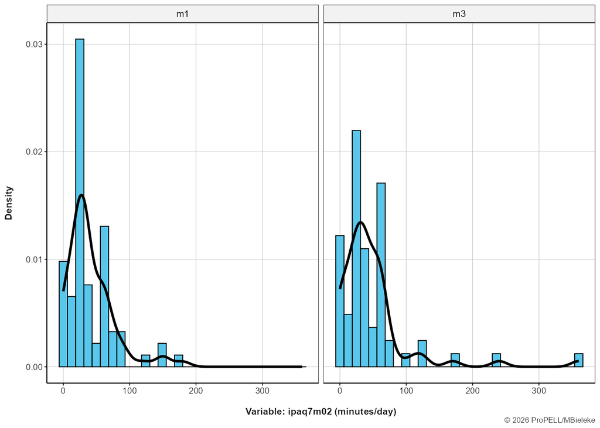

**Statistics**

| Time | N | % | %Val | Mean | SD | Min | Median | Max |
| --- | --- | --- | --- | --- | --- | --- | --- | --- |
| m1 | 75 | 74 | 98.67 | 40.69 | 35.33 | 0 | 30.0 | 180 |
| m3 | 75 | 66 | 88.00 | 47.64 | 56.08 | 0 | 39.5 | 360 |

### IPAQ-SF 7 days - Duration of sitting

**Overview**

- **Variable Stem: `ipaq7s`**
- **Time Points:** m1, m3
- **Reference:** Craig et al. (2003)

**Note:** The IPAQ has additionally been assessed in two state questionnaire accompanying the amubulatory assessments.

**Details**

How much time did you spend sitting on a typical weekday during the last 7 days? This can include time spent sitting at a desk, visiting friends, sitting or lying in front of the television, and sitting on public transport. Please enter the duration in hours:minutes. For example: 40 minutes ==> 00:40 / one hour ==> 01:00 / two and a half hours ==> 02:30

**Distribution**

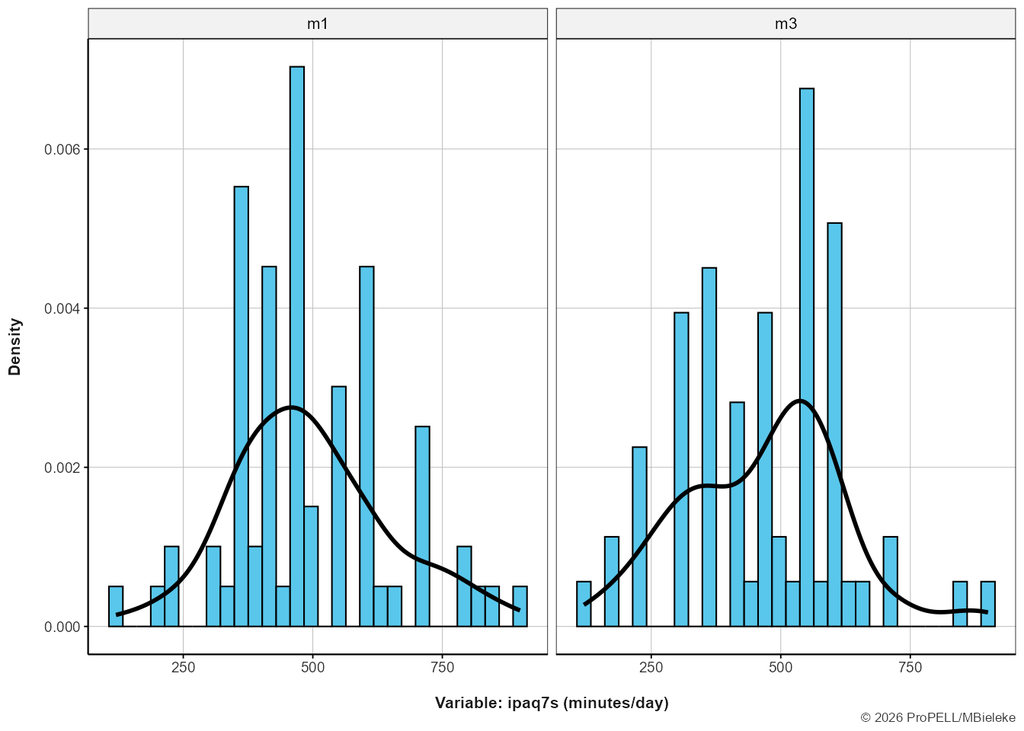

**Statistics**

| Time | N | % | %Val | Mean | SD | Min | Median | Max |
| --- | --- | --- | --- | --- | --- | --- | --- | --- |
| m1 | 75 | 74 | 98.67 | 494.39 | 152.21 | 120 | 480 | 900 |
| m3 | 75 | 66 | 88.00 | 466.30 | 154.32 | 120 | 480 | 900 |

### IPAQ-SF 7 days - Frequency of vigorous activity

**Overview**

- **Variable Stem: `ipaq7v01`**
- **Time Points:** m1, m3
- **Reference:** Craig et al. (2003)

**Note:** The IPAQ has additionally been assessed in two state questionnaire accompanying the amubulatory assessments.

**Details**

Please think only about the physical activities that you performed for at least 10 minutes without interruption. On how many of the past 7 days did you perform strenuous physical activities such as aerobics, running, fast cycling, or fast swimming?

**Distribution**

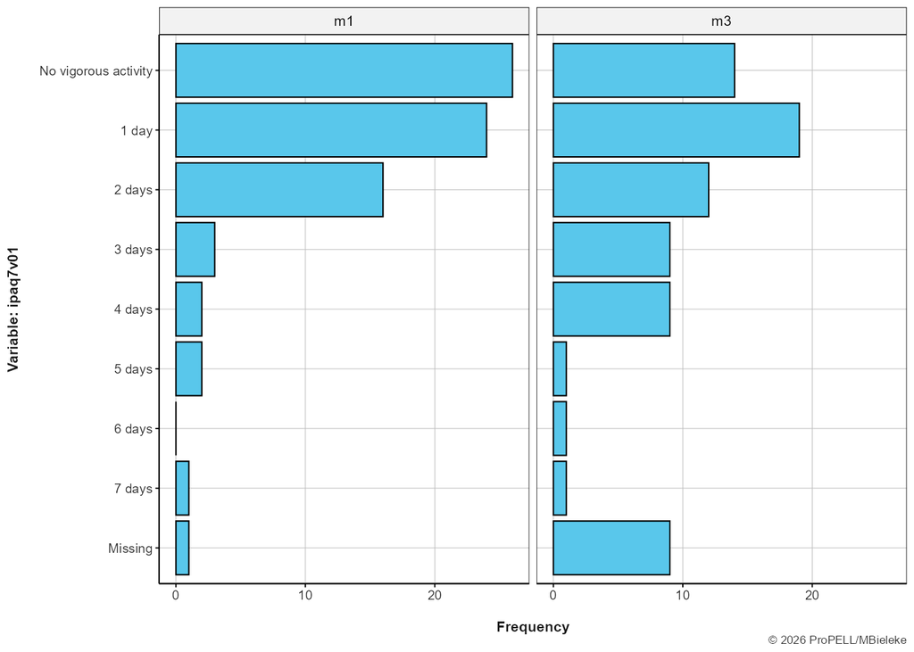

**Statistics**

| Answer | N | % | %Val |
| --- | --- | --- | --- |
| **No vigorous activity** |  |  |  |
| m1 | 26 | 34.7 | 35.1 |
| m3 | 14 | 18.7 | 21.2 |
| **1 day** |  |  |  |
| m1 | 24 | 32.0 | 32.4 |
| m3 | 19 | 25.3 | 28.8 |
| **2 days** |  |  |  |
| m1 | 16 | 21.3 | 21.6 |
| m3 | 12 | 16.0 | 18.2 |
| **3 days** |  |  |  |
| m1 | 3 | 4.0 | 4.0 |
| m3 | 9 | 12.0 | 13.6 |
| **4 days** |  |  |  |
| m1 | 2 | 2.7 | 2.7 |
| m3 | 9 | 12.0 | 13.6 |
| **5 days** |  |  |  |
| m1 | 2 | 2.7 | 2.7 |
| m3 | 1 | 1.3 | 1.5 |
| **6 days** |  |  |  |
| m1 | 0 | 0.0 | 0.0 |
| m3 | 1 | 1.3 | 1.5 |
| **7 days** |  |  |  |
| m1 | 1 | 1.3 | 1.4 |
| m3 | 1 | 1.3 | 1.5 |
| **Missing** |  |  |  |
| m1 | 1 | 1.3 | --- |
| m3 | 9 | 12.0 | --- |

### IPAQ-SF 7 days - Duration of vigorous activity

**Overview**

- **Variable Stem: `ipaq7v02`**
- **Time Points:** m1, m3
- **Reference:** Craig et al. (2003)

**Note:** The IPAQ has additionally been assessed in two state questionnaire accompanying the amubulatory assessments.

**Details**

How much time did you usually spend on one of those days doing strenuous physical activity? Please enter the duration in hours:minutes. For example: 40 minutes ==> 00:40 / one hour ==> 01:00 / two and a half hours ==> 02:30

**Distribution**

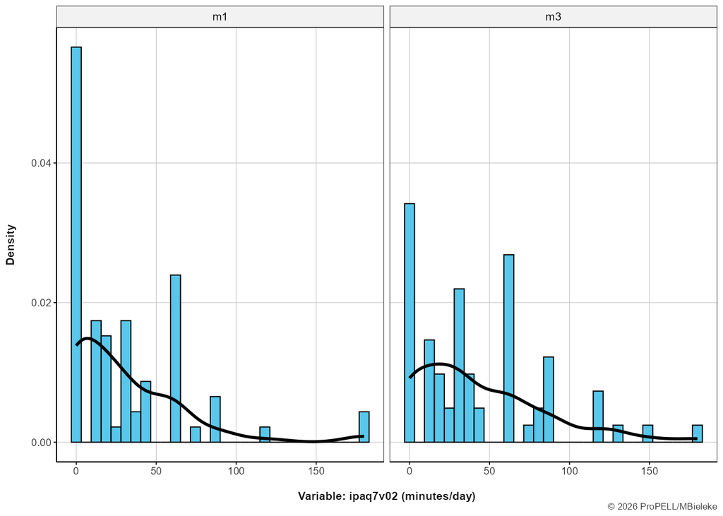

**Statistics**

| Time | N | % | %Val | Mean | SD | Min | Median | Max |
| --- | --- | --- | --- | --- | --- | --- | --- | --- |
| m1 | 75 | 74 | 98.67 | 30.61 | 37.52 | 0 | 20 | 180 |
| m3 | 75 | 66 | 88.00 | 43.79 | 41.02 | 0 | 30 | 180 |

### IPAQ-SF 7 days - Frequency of walking

**Overview**

- **Variable Stem: `ipaq7w01`**
- **Time Points:** m1, m3
- **Reference:** Craig et al. (2003)

**Note:** The IPAQ has additionally been assessed in two state questionnaire accompanying the amubulatory assessments.

**Details**

On how many days per week in the last 7 days did you usually walk for at least 10 minutes without interruption? This includes walking at home or at work, walking to get from one place to another, as well as any other walking for recreation, exercise, or leisure.

**Distribution**

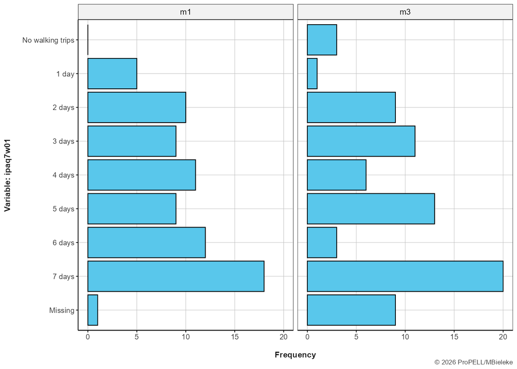

**Statistics**

| Answer | N | % | %Val |
| --- | --- | --- | --- |
| **No walking trips** |  |  |  |
| m1 | 0 | 0.0 | 0.0 |
| m3 | 3 | 4.0 | 4.6 |
| **1 day** |  |  |  |
| m1 | 5 | 6.7 | 6.8 |
| m3 | 1 | 1.3 | 1.5 |
| **2 days** |  |  |  |
| m1 | 10 | 13.3 | 13.5 |
| m3 | 9 | 12.0 | 13.6 |
| **3 days** |  |  |  |
| m1 | 9 | 12.0 | 12.2 |
| m3 | 11 | 14.7 | 16.7 |
| **4 days** |  |  |  |
| m1 | 11 | 14.7 | 14.9 |
| m3 | 6 | 8.0 | 9.1 |
| **5 days** |  |  |  |
| m1 | 9 | 12.0 | 12.2 |
| m3 | 13 | 17.3 | 19.7 |
| **6 days** |  |  |  |
| m1 | 12 | 16.0 | 16.2 |
| m3 | 3 | 4.0 | 4.6 |
| **7 days** |  |  |  |
| m1 | 18 | 24.0 | 24.3 |
| m3 | 20 | 26.7 | 30.3 |
| **Missing** |  |  |  |
| m1 | 1 | 1.3 | --- |
| m3 | 9 | 12.0 | --- |

### IPAQ-SF 7 days - Duration of walking

**Overview**

- **Variable Stem: `ipaq7w02`**
- **Time Points:** m1, m3
- **Reference:** Craig et al. (2003)

**Note:** The IPAQ has additionally been assessed in two state questionnaire accompanying the amubulatory assessments.

**Details**

How much time did you usually spend on one of those days walking? Please enter the duration in hours:minutes. For example: 40 minutes ==> 00:40 / one hour ==> 01:00 / two and a half hours ==> 02:30

**Distribution**

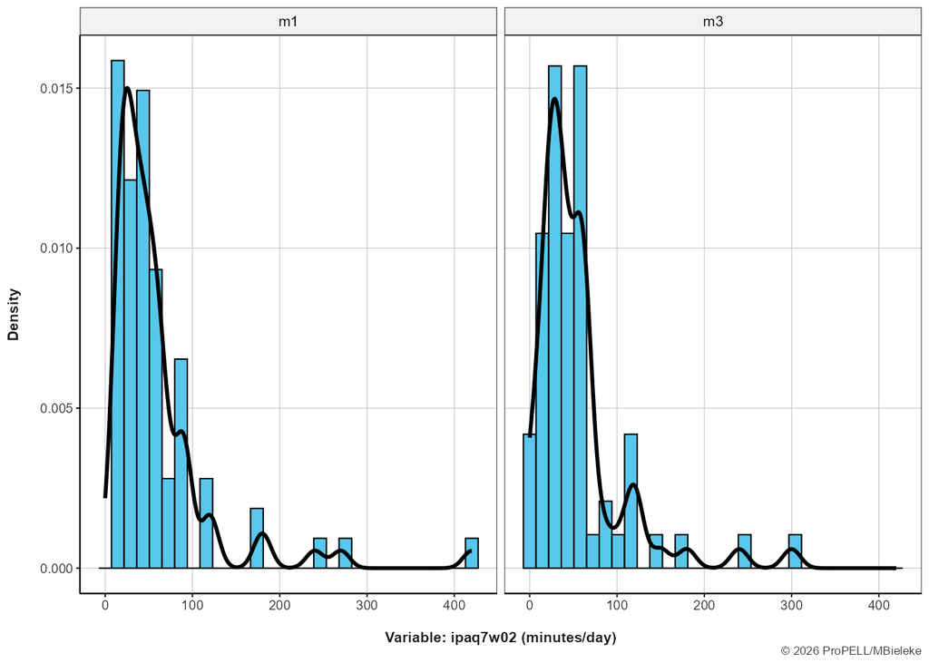

**Statistics**

| Time | N | % | %Val | Mean | SD | Min | Median | Max |
| --- | --- | --- | --- | --- | --- | --- | --- | --- |
| m1 | 75 | 74 | 98.67 | 60.41 | 64.14 | 15 | 45 | 420 |
| m3 | 75 | 66 | 88.00 | 54.85 | 52.52 | 0 | 40 | 300 |

### Overall ITPS mean score

**Overview**

- **Variable Stem: `itps`**
- **Time Points:** m1, m2, m3
- **Reference:** Bieleke & Keller (2021)

**Details**

**Items**

**Directions**: The following statements refer to how you generally approach your exercise goals. Please read each statement and indicate the extent to which it applies to your exercise goals.

| Variable | Scale | Prompt |
| --- | --- | --- |
| itps01 | Identifying Opportunities | I think about when and where decisive moments for the achievement of my athletic goals might occur. |
| itps02 | Identifying Opportunities | I think about chances and possibilities that I could use to achieve my athletic goals. |
| itps03 | Identifying Obstacles | I envisage what obstacles could arise when pursuing my athletic goals. |
| itps04 | Identifying Obstacles | I am concerned with what setbacks to expect when pursuing my athletic goals. |
| itps05 | Action Planning | I plan how best to achieve my athletic goals. |
| itps06 | Action Planning | I plan the concrete actions I will take toward my athletic goals. |
| itps07 | Coping Planning | I plan how to protect myself from distractions when pursuing my athletic goals. |
| itps08 | Coping Planning | I plan ways in which I can deal with difficulties when pursuing my athletic goals. |

Note. Variables with * have been reverse-coded

**Scale**

| Variable | Description |
| --- | --- |
| itps | Overall ITPS mean score |

**Distribution**

**Items**

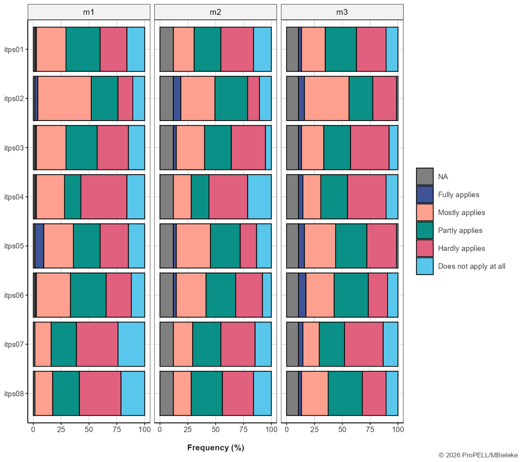

**Scale**

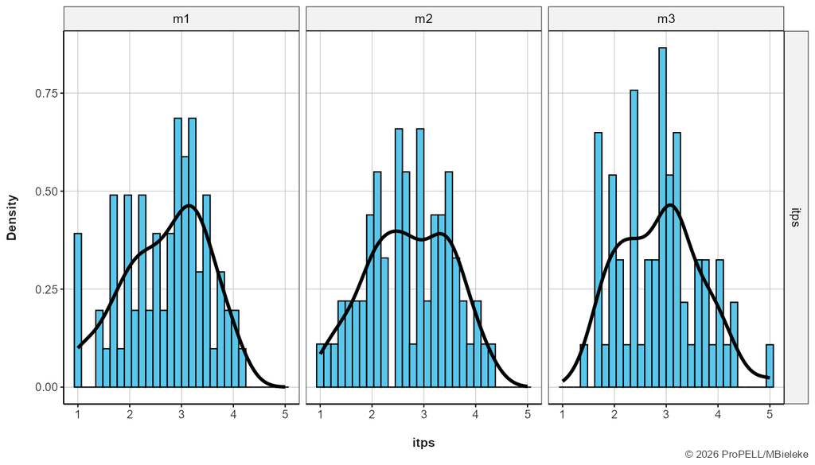

**Statistics**

**Items**

| Variable | N | #Valid | %Valid | Mean | SD | Min | Median | Max |
| --- | --- | --- | --- | --- | --- | --- | --- | --- |
| **itps01** |  |  |  |  |  |  |  |  |
| m1 | 75 | 74 | 98.67 | 2.73 | 1.08 | 1 | 3.0 | 5 |
| m2 | 75 | 66 | 88.00 | 2.52 | 1.03 | 1 | 2.0 | 4 |
| m3 | 75 | 67 | 89.33 | 2.76 | 1.05 | 1 | 3.0 | 5 |
| **itps02** |  |  |  |  |  |  |  |  |
| m1 | 75 | 74 | 98.67 | 3.19 | 1.07 | 1 | 4.0 | 5 |
| m2 | 75 | 66 | 88.00 | 3.14 | 1.12 | 1 | 3.0 | 5 |
| m3 | 75 | 67 | 89.33 | 3.30 | 0.95 | 1 | 4.0 | 5 |
| **itps03** |  |  |  |  |  |  |  |  |
| m1 | 75 | 74 | 98.67 | 2.72 | 1.07 | 1 | 3.0 | 5 |
| m2 | 75 | 66 | 88.00 | 2.88 | 1.00 | 1 | 3.0 | 5 |
| m3 | 75 | 67 | 89.33 | 2.72 | 1.01 | 1 | 3.0 | 5 |
| **itps04** |  |  |  |  |  |  |  |  |
| m1 | 75 | 74 | 98.67 | 2.54 | 1.09 | 1 | 2.0 | 5 |
| m2 | 75 | 66 | 88.00 | 2.30 | 1.04 | 1 | 2.0 | 4 |
| m3 | 75 | 67 | 89.33 | 2.64 | 1.05 | 1 | 2.0 | 5 |
| **itps05** |  |  |  |  |  |  |  |  |
| m1 | 75 | 74 | 98.67 | 2.88 | 1.20 | 1 | 3.0 | 5 |
| m2 | 75 | 66 | 88.00 | 2.94 | 1.12 | 1 | 3.0 | 5 |
| m3 | 75 | 67 | 89.33 | 3.10 | 0.96 | 1 | 3.0 | 5 |
| **itps06** |  |  |  |  |  |  |  |  |
| m1 | 75 | 74 | 98.67 | 2.86 | 1.04 | 1 | 3.0 | 5 |
| m2 | 75 | 66 | 88.00 | 2.91 | 1.03 | 1 | 3.0 | 5 |
| m3 | 75 | 67 | 89.33 | 3.03 | 1.10 | 1 | 3.0 | 5 |
| **itps07** |  |  |  |  |  |  |  |  |
| m1 | 75 | 74 | 98.67 | 2.28 | 1.00 | 1 | 2.0 | 4 |
| m2 | 75 | 66 | 88.00 | 2.52 | 1.00 | 1 | 2.0 | 4 |
| m3 | 75 | 67 | 89.33 | 2.57 | 1.08 | 1 | 2.0 | 5 |
| **itps08** |  |  |  |  |  |  |  |  |
| m1 | 75 | 74 | 98.67 | 2.35 | 1.00 | 1 | 2.0 | 4 |
| m2 | 75 | 66 | 88.00 | 2.50 | 1.00 | 1 | 2.5 | 4 |
| m3 | 75 | 67 | 89.33 | 2.85 | 1.05 | 1 | 3.0 | 5 |

**Scale**

| Variable | N | #Valid | %Valid | SD | Mean | Min | Median | Max | #Items | Alpha |
| --- | --- | --- | --- | --- | --- | --- | --- | --- | --- | --- |
| **itps** |  |  |  |  |  |  |  |  |  |  |
| m1 | 75 | 74 | 98.67 | 0.80 | 2.69 | 1.00 | 2.81 | 4.12 | 8 | 0.89 |
| m2 | 75 | 66 | 88.00 | 0.81 | 2.71 | 1.00 | 2.62 | 4.25 | 8 | 0.90 |
| m3 | 75 | 67 | 89.33 | 0.78 | 2.87 | 1.38 | 3.00 | 5.00 | 8 | 0.89 |

### Overall MoBS mean score

**Overview**

- **Variable Stem: `mobs`**
- **Time Points:** m1, m2, m3
- **Reference:** Schüler et al. (2023)

**Details**

**Items**

**Directions**: The following statements refer to how people think about exercise. Please respond to each statement in the way that best reflects you. Answer spontaneously and do not think too long. There are no right or wrong answers.

| Variable | Scale | Prompt |
| --- | --- | --- |
| mobs01 | Willpower | Every sporting challenge can be accomplished with sufficient willpower. |
| mobs02 | Willpower | Many of those who fail at sports simply did not “want it badly” enough. |
| mobs03 | Willpower | Failure in sports reflects a lack of willpower. |
| mobs04 | Pain | Tolerating pain is a normal part of sports. |
| mobs05 | Pain | No pain, no gain. |
| mobs06 | Pain | Sometimes it is required to push through injuries and just keep going. |
| mobs07 | Effort | If one did not give a full effort in training, then there is no real sense in doing it at all. |
| mobs08 | Effort | Sport is about pushing to one’s personal boundaries. |
| mobs09 | Effort | The motivating thing about sport is leaving one’s comfort zone. |

Note. Variables with * have been reverse-coded

**Scale**

| Variable | Description |
| --- | --- |
| mobs | Overall MoBS mean score |

**Distribution**

**Items**

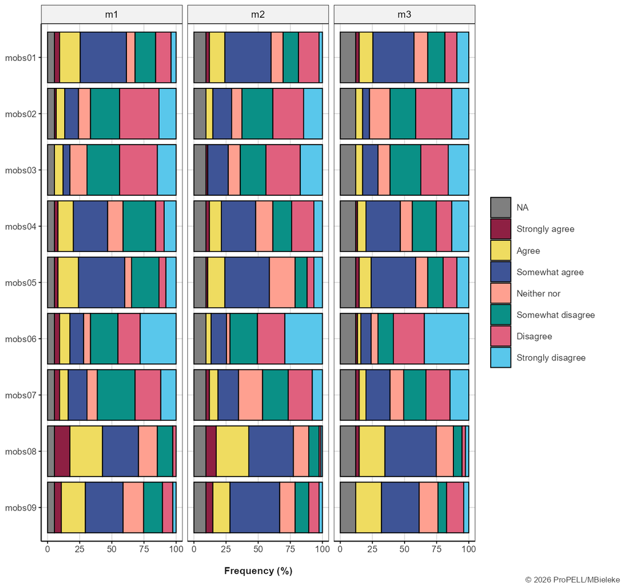

**Scale**

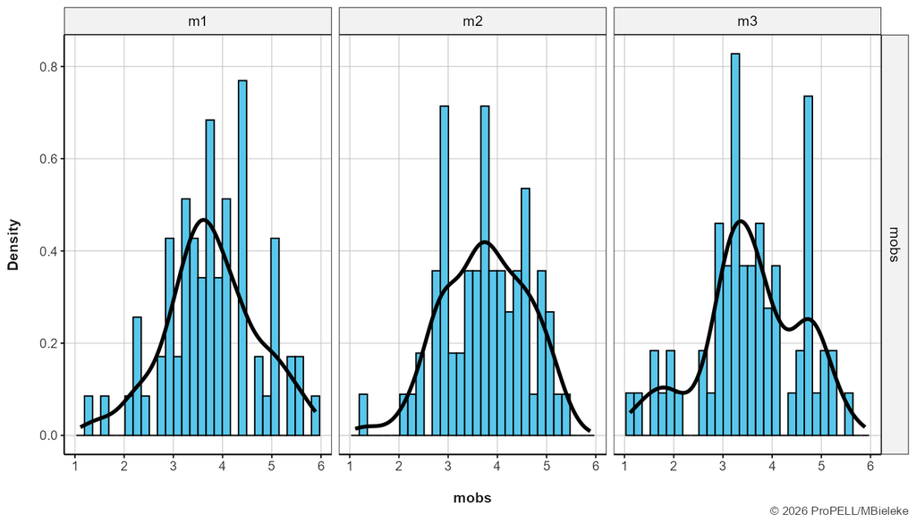

**Statistics**

**Items**

| Variable | N | #Valid | %Valid | Mean | SD | Min | Median | Max |
| --- | --- | --- | --- | --- | --- | --- | --- | --- |
| **mobs01** |  |  |  |  |  |  |  |  |
| m1 | 75 | 71 | 94.67 | 4.30 | 1.56 | 1 | 5.0 | 7 |
| m2 | 75 | 68 | 90.67 | 4.18 | 1.52 | 1 | 5.0 | 7 |
| m3 | 75 | 66 | 88.00 | 4.02 | 1.64 | 1 | 5.0 | 7 |
| **mobs02** |  |  |  |  |  |  |  |  |
| m1 | 75 | 71 | 94.67 | 2.99 | 1.53 | 1 | 3.0 | 7 |
| m2 | 75 | 68 | 90.67 | 3.00 | 1.49 | 1 | 3.0 | 6 |
| m3 | 75 | 66 | 88.00 | 2.86 | 1.38 | 1 | 3.0 | 6 |
| **mobs03** |  |  |  |  |  |  |  |  |
| m1 | 75 | 71 | 94.67 | 2.85 | 1.39 | 1 | 3.0 | 6 |
| m2 | 75 | 68 | 90.67 | 2.84 | 1.45 | 1 | 3.0 | 7 |
| m3 | 75 | 66 | 88.00 | 2.95 | 1.48 | 1 | 3.0 | 6 |
| **mobs04** |  |  |  |  |  |  |  |  |
| m1 | 75 | 71 | 94.67 | 3.92 | 1.58 | 1 | 4.0 | 7 |
| m2 | 75 | 68 | 90.67 | 3.82 | 1.60 | 1 | 4.0 | 7 |
| m3 | 75 | 66 | 88.00 | 3.56 | 1.65 | 1 | 3.5 | 7 |
| **mobs05** |  |  |  |  |  |  |  |  |
| m1 | 75 | 71 | 94.67 | 4.21 | 1.58 | 1 | 5.0 | 7 |
| m2 | 75 | 68 | 90.67 | 4.28 | 1.43 | 1 | 5.0 | 7 |
| m3 | 75 | 66 | 88.00 | 4.00 | 1.65 | 1 | 5.0 | 7 |
| **mobs06** |  |  |  |  |  |  |  |  |
| m1 | 75 | 71 | 94.67 | 2.93 | 1.83 | 1 | 3.0 | 7 |
| m2 | 75 | 68 | 90.67 | 2.54 | 1.52 | 1 | 2.0 | 6 |
| m3 | 75 | 66 | 88.00 | 2.33 | 1.54 | 1 | 2.0 | 7 |
| **mobs07** |  |  |  |  |  |  |  |  |
| m1 | 75 | 71 | 94.67 | 3.31 | 1.64 | 1 | 3.0 | 7 |
| m2 | 75 | 68 | 90.67 | 3.51 | 1.54 | 1 | 3.0 | 7 |
| m3 | 75 | 66 | 88.00 | 3.30 | 1.68 | 1 | 3.0 | 7 |
| **mobs08** |  |  |  |  |  |  |  |  |
| m1 | 75 | 71 | 94.67 | 5.03 | 1.31 | 2 | 5.0 | 7 |
| m2 | 75 | 68 | 90.67 | 5.04 | 1.23 | 1 | 5.0 | 7 |
| m3 | 75 | 66 | 88.00 | 4.77 | 1.24 | 1 | 5.0 | 7 |
| **mobs09** |  |  |  |  |  |  |  |  |
| m1 | 75 | 71 | 94.67 | 4.46 | 1.47 | 1 | 5.0 | 7 |
| m2 | 75 | 68 | 90.67 | 4.51 | 1.43 | 1 | 5.0 | 7 |
| m3 | 75 | 66 | 88.00 | 4.27 | 1.51 | 1 | 5.0 | 6 |

**Scale**

| Variable | N | #Valid | %Valid | SD | Mean | Min | Median | Max | #Items | Alpha |
| --- | --- | --- | --- | --- | --- | --- | --- | --- | --- | --- |
| **mobs** |  |  |  |  |  |  |  |  |  |  |
| m1 | 75 | 71 | 94.67 | 0.93 | 3.78 | 1.33 | 3.67 | 5.89 | 9 | 0.78 |
| m2 | 75 | 68 | 90.67 | 0.85 | 3.75 | 1.33 | 3.78 | 5.33 | 9 | 0.75 |
| m3 | 75 | 66 | 88.00 | 1.01 | 3.56 | 1.11 | 3.50 | 5.56 | 9 | 0.83 |

### Overall MoES mean score

**Overview**

- **Variable Stem: `moes`**
- **Time Points:** m1, m2, m3
- **Reference:** Campbell et al. (2022)

**Details**

**Items**

**Directions**: Please read the following statements and indicate, using the response scale, how strongly you agree with them. There are no right or wrong answers. Respond quickly and choose the answers that best describe what you believe and how you feel.

| Variable | Prompt |
| --- | --- |
| moes01 | Pushing myself helps me see the bigger picture. |
| moes02* | I often don’t understand why I am working so hard. |
| moes03 | I learn the most about myself when I am trying my hardest. |
| moes04 | Things make more sense when I can put my all into them. |
| moes05* | When I work hard, it rarely makes a difference. |
| moes06 | When I push myself, what I’m doing feels important. |
| moes07 | When I push myself, I feel like I’m part of something bigger than me. |
| moes08 | Doing my best gives me a clear purpose in life. |
| moes09 | When I try my hardest, my life has meaning. |
| moes10 | When I exert myself, I feel connected to my ideal life. |

Note. Variables with * have been reverse-coded

**Scale**

| Variable | Description |
| --- | --- |
| moes | Overall MoES mean score |

**Distribution**

**Items**

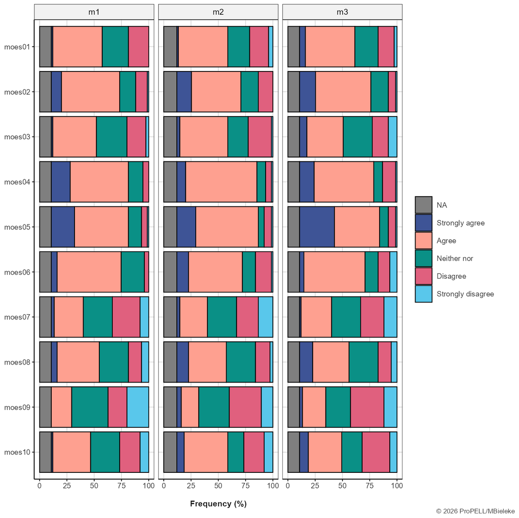

**Scale**

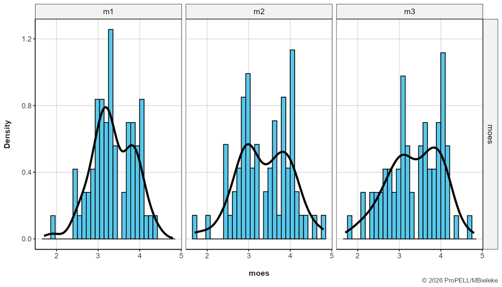

**Statistics**

**Items**

| Variable | N | #Valid | %Valid | Mean | SD | Min | Median | Max |
| --- | --- | --- | --- | --- | --- | --- | --- | --- |
| **moes01** |  |  |  |  |  |  |  |  |
| m1 | 75 | 67 | 89.33 | 3.33 | 0.82 | 2 | 4 | 5 |
| m2 | 75 | 66 | 88.00 | 3.26 | 0.95 | 1 | 4 | 5 |
| m3 | 75 | 67 | 89.33 | 3.40 | 0.94 | 1 | 4 | 5 |
| **moes02** |  |  |  |  |  |  |  |  |
| m1 | 75 | 67 | 89.33 | 3.66 | 0.88 | 1 | 4 | 5 |
| m2 | 75 | 66 | 88.00 | 3.67 | 0.92 | 2 | 4 | 5 |
| m3 | 75 | 67 | 89.33 | 3.79 | 0.86 | 1 | 4 | 5 |
| **moes03** |  |  |  |  |  |  |  |  |
| m1 | 75 | 67 | 89.33 | 3.22 | 0.88 | 1 | 3 | 5 |
| m2 | 75 | 66 | 88.00 | 3.29 | 0.92 | 1 | 4 | 5 |
| m3 | 75 | 67 | 89.33 | 3.18 | 1.09 | 1 | 3 | 5 |
| **moes04** |  |  |  |  |  |  |  |  |
| m1 | 75 | 67 | 89.33 | 3.93 | 0.77 | 2 | 4 | 5 |
| m2 | 75 | 66 | 88.00 | 3.83 | 0.74 | 1 | 4 | 5 |
| m3 | 75 | 67 | 89.33 | 3.75 | 0.93 | 1 | 4 | 5 |
| **moes05** |  |  |  |  |  |  |  |  |
| m1 | 75 | 67 | 89.33 | 3.94 | 0.87 | 1 | 4 | 5 |
| m2 | 75 | 66 | 88.00 | 3.94 | 0.84 | 1 | 4 | 5 |
| m3 | 75 | 67 | 89.33 | 4.07 | 0.94 | 1 | 4 | 5 |
| **moes06** |  |  |  |  |  |  |  |  |
| m1 | 75 | 67 | 89.33 | 3.73 | 0.64 | 2 | 4 | 5 |
| m2 | 75 | 66 | 88.00 | 3.61 | 0.96 | 1 | 4 | 5 |
| m3 | 75 | 67 | 89.33 | 3.45 | 1.02 | 1 | 4 | 5 |
| **moes07** |  |  |  |  |  |  |  |  |
| m1 | 75 | 67 | 89.33 | 2.90 | 1.03 | 1 | 3 | 5 |
| m2 | 75 | 66 | 88.00 | 2.82 | 1.11 | 1 | 3 | 5 |
| m3 | 75 | 67 | 89.33 | 2.84 | 1.07 | 1 | 3 | 5 |
| **moes08** |  |  |  |  |  |  |  |  |
| m1 | 75 | 67 | 89.33 | 3.27 | 1.02 | 1 | 3 | 5 |
| m2 | 75 | 66 | 88.00 | 3.42 | 0.99 | 1 | 4 | 5 |
| m3 | 75 | 67 | 89.33 | 3.39 | 1.07 | 1 | 4 | 5 |
| **moes09** |  |  |  |  |  |  |  |  |
| m1 | 75 | 67 | 89.33 | 2.57 | 1.06 | 1 | 3 | 4 |
| m2 | 75 | 66 | 88.00 | 2.70 | 1.05 | 1 | 3 | 5 |
| m3 | 75 | 67 | 89.33 | 2.69 | 1.08 | 1 | 3 | 5 |
| **moes10** |  |  |  |  |  |  |  |  |
| m1 | 75 | 67 | 89.33 | 3.03 | 1.01 | 1 | 3 | 5 |
| m2 | 75 | 66 | 88.00 | 3.21 | 1.14 | 1 | 4 | 5 |
| m3 | 75 | 67 | 89.33 | 3.09 | 1.14 | 1 | 3 | 5 |

**Scale**

| Variable | N | #Valid | %Valid | SD | Mean | Min | Median | Max | #Items | Alpha |
| --- | --- | --- | --- | --- | --- | --- | --- | --- | --- | --- |
| **moes** |  |  |  |  |  |  |  |  |  |  |
| m1 | 75 | 67 | 89.33 | 0.50 | 3.36 | 1.9 | 3.3 | 4.4 | 10 | 0.74 |
| m2 | 75 | 66 | 88.00 | 0.63 | 3.37 | 1.7 | 3.4 | 4.8 | 10 | 0.85 |
| m3 | 75 | 67 | 89.33 | 0.63 | 3.36 | 1.8 | 3.5 | 4.7 | 10 | 0.82 |

### No overall PANAS score is computed

**Overview**

- **Variable Stem: `panas`**
- **Time Points:** m1, m2, m3
- **Reference:** Breyer & Bluemke (2016)

**Details**

**Items**

**Directions**: Now we would like to know how you have felt over the past 4 weeks. The following words describe different feelings and emotions. Please read each word and indicate the intensity on the scale next to each word. You can choose between five levels. Please indicate how you generally feel.

| Variable | Scale | Prompt |
| --- | --- | --- |
| panas01 | Positive Affect | active |
| panas02 | Negative Affect | distressed |
| panas03 | Positive Affect | interested |
| panas04 | Positive Affect | excited |
| panas05 | Negative Affect | upset |
| panas06 | Positive Affect | strong |
| panas07 | Negative Affect | guilty |
| panas08 | Negative Affect | scared |
| panas09 | Negative Affect | hostile |
| panas10 | Positive Affect | inspired |
| panas11 | Positive Affect | proud |
| panas12 | Negative Affect | irritable |
| panas13 | Positive Affect | enthusiastic |
| panas14 | Negative Affect | ashamed |
| panas15 | Positive Affect | alert |
| panas16 | Negative Affect | nervous |
| panas17 | Positive Affect | determined |
| panas18 | Positive Affect | attentive |
| panas19 | Negative Affect | jittery |
| panas20 | Negative Affect | afraid |

Note. Variables with * have been reverse-coded

**Scale**

| Variable | Description |
| --- | --- |
| panas | No overall PANAS score is computed |
| panasn | Mean score of Negative Affect items |
| panasp | Mean score of Positive Affect items |

**Distribution**

**Items**

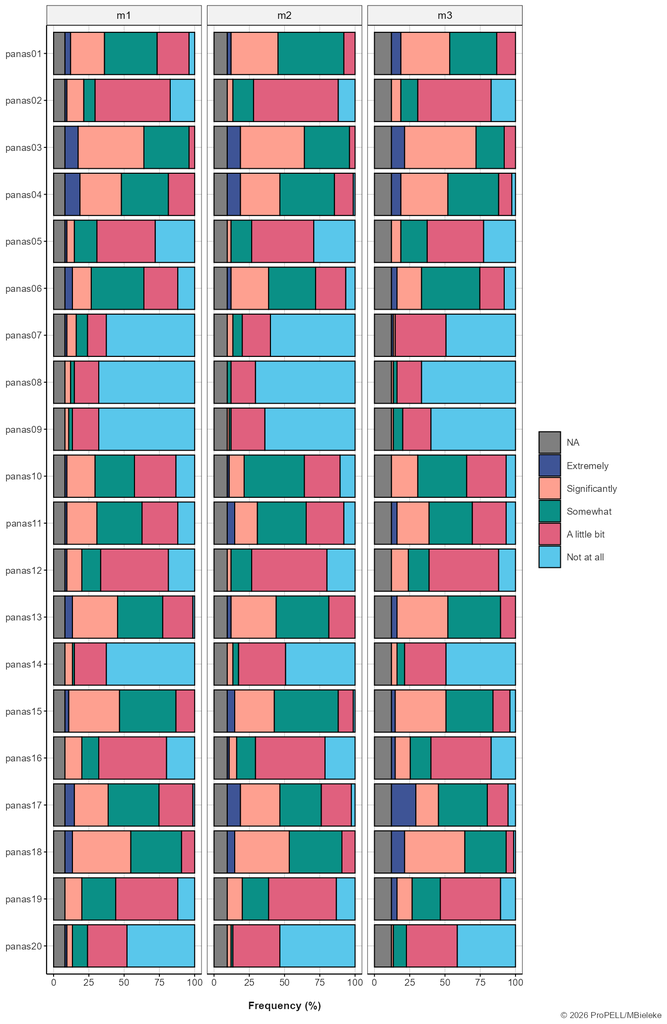

**Scale**

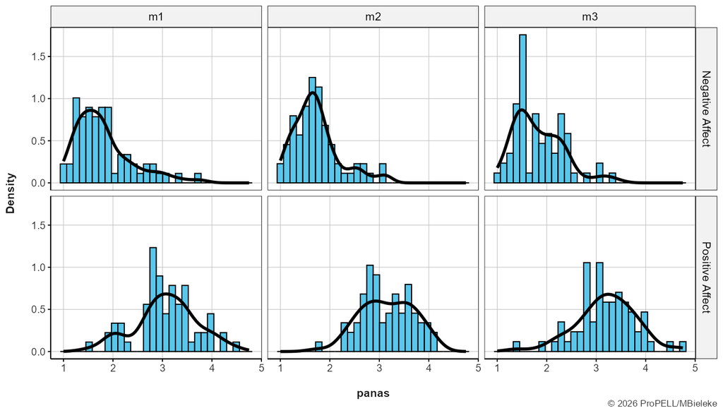

**Statistics**

**Items**

| Variable | N | #Valid | %Valid | Mean | SD | Min | Median | Max |
| --- | --- | --- | --- | --- | --- | --- | --- | --- |
| **panas01** |  |  |  |  |  |  |  |  |
| m1 | 75 | 69 | 92.00 | 3.01 | 0.93 | 1 | 3 | 5 |
| m2 | 75 | 68 | 90.67 | 3.34 | 0.68 | 2 | 3 | 5 |
| m3 | 75 | 66 | 88.00 | 3.39 | 0.84 | 2 | 3 | 5 |
| **panas02** |  |  |  |  |  |  |  |  |
| m1 | 75 | 69 | 92.00 | 2.20 | 0.95 | 1 | 2 | 5 |
| m2 | 75 | 68 | 90.67 | 2.12 | 0.68 | 1 | 2 | 4 |
| m3 | 75 | 66 | 88.00 | 2.09 | 0.80 | 1 | 2 | 4 |
| **panas03** |  |  |  |  |  |  |  |  |
| m1 | 75 | 69 | 92.00 | 3.67 | 0.72 | 2 | 4 | 5 |
| m2 | 75 | 68 | 90.67 | 3.66 | 0.73 | 2 | 4 | 5 |
| m3 | 75 | 66 | 88.00 | 3.70 | 0.78 | 2 | 4 | 5 |
| **panas04** |  |  |  |  |  |  |  |  |
| m1 | 75 | 69 | 92.00 | 3.35 | 0.94 | 2 | 3 | 5 |
| m2 | 75 | 68 | 90.67 | 3.34 | 0.91 | 1 | 3 | 5 |
| m3 | 75 | 66 | 88.00 | 3.36 | 0.89 | 1 | 3 | 5 |
| **panas05** |  |  |  |  |  |  |  |  |
| m1 | 75 | 69 | 92.00 | 2.03 | 0.92 | 1 | 2 | 5 |
| m2 | 75 | 68 | 90.67 | 1.90 | 0.78 | 1 | 2 | 4 |
| m3 | 75 | 66 | 88.00 | 2.11 | 0.88 | 1 | 2 | 4 |
| **panas06** |  |  |  |  |  |  |  |  |
| m1 | 75 | 69 | 92.00 | 2.74 | 1.05 | 1 | 3 | 5 |
| m2 | 75 | 68 | 90.67 | 2.97 | 0.98 | 1 | 3 | 5 |
| m3 | 75 | 66 | 88.00 | 2.91 | 0.97 | 1 | 3 | 5 |
| **panas07** |  |  |  |  |  |  |  |  |
| m1 | 75 | 69 | 92.00 | 1.59 | 1.02 | 1 | 1 | 5 |
| m2 | 75 | 68 | 90.67 | 1.50 | 0.82 | 1 | 1 | 4 |
| m3 | 75 | 66 | 88.00 | 1.52 | 0.73 | 1 | 1 | 5 |
| **panas08** |  |  |  |  |  |  |  |  |
| m1 | 75 | 69 | 92.00 | 1.38 | 0.75 | 1 | 1 | 4 |
| m2 | 75 | 68 | 90.67 | 1.25 | 0.50 | 1 | 1 | 3 |
| m3 | 75 | 66 | 88.00 | 1.30 | 0.61 | 1 | 1 | 4 |
| **panas09** |  |  |  |  |  |  |  |  |
| m1 | 75 | 69 | 92.00 | 1.35 | 0.68 | 1 | 1 | 4 |
| m2 | 75 | 68 | 90.67 | 1.34 | 0.59 | 1 | 1 | 4 |
| m3 | 75 | 66 | 88.00 | 1.42 | 0.70 | 1 | 1 | 4 |
| **panas10** |  |  |  |  |  |  |  |  |
| m1 | 75 | 69 | 92.00 | 2.64 | 1.03 | 1 | 3 | 5 |
| m2 | 75 | 68 | 90.67 | 2.63 | 0.90 | 1 | 3 | 5 |
| m3 | 75 | 66 | 88.00 | 2.74 | 0.88 | 1 | 3 | 4 |
| **panas11** |  |  |  |  |  |  |  |  |
| m1 | 75 | 69 | 92.00 | 2.72 | 1.01 | 1 | 3 | 5 |
| m2 | 75 | 68 | 90.67 | 2.82 | 1.02 | 1 | 3 | 5 |
| m3 | 75 | 66 | 88.00 | 2.92 | 1.01 | 1 | 3 | 5 |
| **panas12** |  |  |  |  |  |  |  |  |
| m1 | 75 | 69 | 92.00 | 2.22 | 0.95 | 1 | 2 | 5 |
| m2 | 75 | 68 | 90.67 | 2.00 | 0.71 | 1 | 2 | 4 |
| m3 | 75 | 66 | 88.00 | 2.30 | 0.88 | 1 | 2 | 4 |
| **panas13** |  |  |  |  |  |  |  |  |
| m1 | 75 | 69 | 92.00 | 3.20 | 0.92 | 1 | 3 | 5 |
| m2 | 75 | 68 | 90.67 | 3.21 | 0.80 | 2 | 3 | 5 |
| m3 | 75 | 66 | 88.00 | 3.38 | 0.76 | 2 | 3 | 5 |
| **panas14** |  |  |  |  |  |  |  |  |
| m1 | 75 | 69 | 92.00 | 1.45 | 0.80 | 1 | 1 | 4 |
| m2 | 75 | 68 | 90.67 | 1.59 | 0.78 | 1 | 1 | 4 |
| m3 | 75 | 66 | 88.00 | 1.59 | 0.80 | 1 | 1 | 4 |
| **panas15** |  |  |  |  |  |  |  |  |
| m1 | 75 | 69 | 92.00 | 3.30 | 0.75 | 2 | 3 | 5 |
| m2 | 75 | 68 | 90.67 | 3.28 | 0.81 | 1 | 3 | 5 |
| m3 | 75 | 66 | 88.00 | 3.24 | 0.90 | 1 | 3 | 5 |
| **panas16** |  |  |  |  |  |  |  |  |
| m1 | 75 | 69 | 92.00 | 2.17 | 0.92 | 1 | 2 | 4 |
| m2 | 75 | 68 | 90.67 | 2.07 | 0.87 | 1 | 2 | 5 |
| m3 | 75 | 66 | 88.00 | 2.30 | 1.02 | 1 | 2 | 5 |
| **panas17** |  |  |  |  |  |  |  |  |
| m1 | 75 | 69 | 92.00 | 3.12 | 0.93 | 1 | 3 | 5 |
| m2 | 75 | 68 | 90.67 | 3.22 | 1.02 | 1 | 3 | 5 |
| m3 | 75 | 66 | 88.00 | 3.29 | 1.15 | 1 | 3 | 5 |
| **panas18** |  |  |  |  |  |  |  |  |
| m1 | 75 | 69 | 92.00 | 3.46 | 0.76 | 2 | 4 | 5 |
| m2 | 75 | 68 | 90.67 | 3.44 | 0.76 | 2 | 3 | 5 |
| m3 | 75 | 66 | 88.00 | 3.61 | 0.82 | 1 | 4 | 5 |
| **panas19** |  |  |  |  |  |  |  |  |
| m1 | 75 | 69 | 92.00 | 2.39 | 0.88 | 1 | 2 | 4 |
| m2 | 75 | 68 | 90.67 | 2.29 | 0.86 | 1 | 2 | 4 |
| m3 | 75 | 66 | 88.00 | 2.48 | 1.01 | 1 | 2 | 5 |
| **panas20** |  |  |  |  |  |  |  |  |
| m1 | 75 | 69 | 92.00 | 1.72 | 0.94 | 1 | 1 | 5 |
| m2 | 75 | 68 | 90.67 | 1.49 | 0.68 | 1 | 1 | 4 |
| m3 | 75 | 66 | 88.00 | 1.67 | 0.73 | 1 | 2 | 4 |

**Scale**

| Variable | N | #Valid | %Valid | SD | Mean | Min | Median | Max | #Items | Alpha |
| --- | --- | --- | --- | --- | --- | --- | --- | --- | --- | --- |
| **panasn** |  |  |  |  |  |  |  |  |  |  |
| m1 | 75 | 69 | 92.00 | 0.57 | 1.80 | 1.00 | 1.62 | 3.75 | 10 | 0.86 |
| m2 | 75 | 68 | 90.67 | 0.47 | 1.72 | 1.00 | 1.62 | 3.12 | 10 | 0.83 |
| m3 | 75 | 66 | 88.00 | 0.50 | 1.83 | 1.00 | 1.75 | 3.38 | 10 | 0.79 |
| **panasp** |  |  |  |  |  |  |  |  |  |  |
| m1 | 75 | 69 | 92.00 | 0.63 | 3.08 | 1.50 | 3.12 | 4.50 | 10 | 0.86 |
| m2 | 75 | 68 | 90.67 | 0.54 | 3.16 | 1.75 | 3.12 | 4.12 | 10 | 0.85 |
| m3 | 75 | 66 | 88.00 | 0.61 | 3.21 | 1.38 | 3.25 | 4.75 | 10 | 0.88 |

### Overall POMS - Vigor mean score

**Overview**

- **Variable Stem: `poms`**
- **Time Points:** m1, m2, m3
- **Reference:** Albani et al. (2005)

**Details**

**Items**

**Directions**: Please use the listed statements to describe your well-being over the past 4 weeks. For each statement, select how much it applies to your well-being.

| Variable | Scale | Prompt |
| --- | --- | --- |
| poms01 | Vigor | full of pep |
| poms02 | Vigor | vigorous |
| poms03 | Vigor | alert |
| poms04 | Vigor | active |
| poms05 | Vigor | cheerful |
| poms06 | Vigor | lively |
| poms07 | Vigor | energetic |

Note. Variables with * have been reverse-coded

**Scale**

| Variable | Description |
| --- | --- |
| poms | Overall POMS - Vigor mean score |

**Distribution**

**Items**

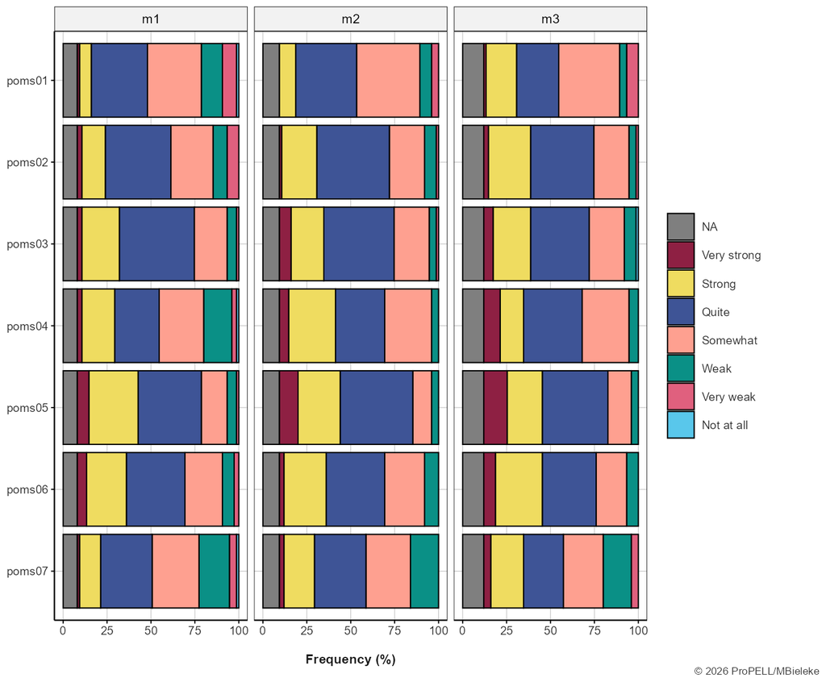

**Scale**

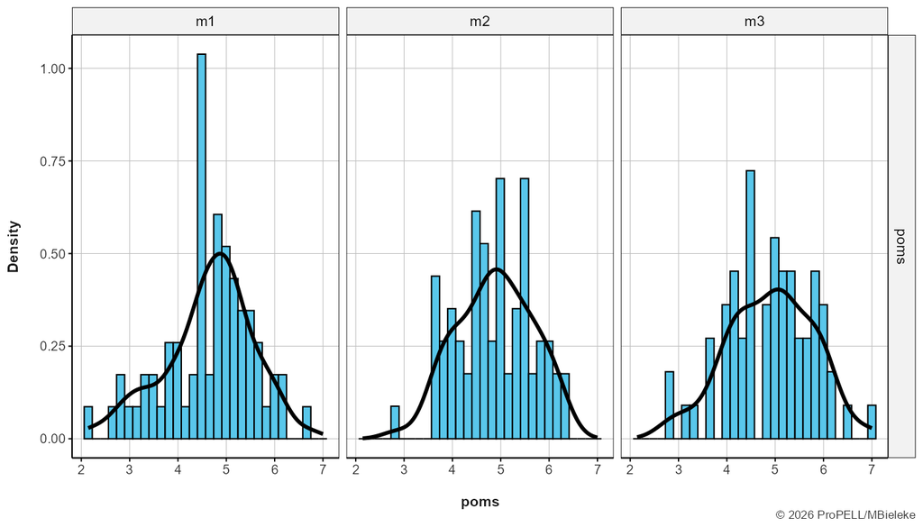

**Statistics**

**Items**

| Variable | N | #Valid | %Valid | Mean | SD | Min | Median | Max |
| --- | --- | --- | --- | --- | --- | --- | --- | --- |
| **poms01** |  |  |  |  |  |  |  |  |
| m1 | 75 | 69 | 92.00 | 4.19 | 1.17 | 1 | 4 | 7 |
| m2 | 75 | 68 | 90.67 | 4.43 | 0.94 | 2 | 4 | 6 |
| m3 | 75 | 66 | 88.00 | 4.52 | 1.14 | 2 | 4 | 7 |
| **poms02** |  |  |  |  |  |  |  |  |
| m1 | 75 | 69 | 92.00 | 4.55 | 1.16 | 2 | 5 | 7 |
| m2 | 75 | 68 | 90.67 | 4.84 | 0.96 | 2 | 5 | 7 |
| m3 | 75 | 66 | 88.00 | 4.97 | 0.98 | 2 | 5 | 7 |
| **poms03** |  |  |  |  |  |  |  |  |
| m1 | 75 | 69 | 92.00 | 4.93 | 0.96 | 2 | 5 | 7 |
| m2 | 75 | 68 | 90.67 | 5.00 | 1.02 | 2 | 5 | 7 |
| m3 | 75 | 66 | 88.00 | 4.92 | 1.13 | 1 | 5 | 7 |
| **poms04** |  |  |  |  |  |  |  |  |
| m1 | 75 | 69 | 92.00 | 4.49 | 1.24 | 1 | 5 | 7 |
| m2 | 75 | 68 | 90.67 | 5.03 | 1.01 | 3 | 5 | 7 |
| m3 | 75 | 66 | 88.00 | 4.94 | 1.07 | 3 | 5 | 7 |
| **poms05** |  |  |  |  |  |  |  |  |
| m1 | 75 | 69 | 92.00 | 5.13 | 1.06 | 2 | 5 | 7 |
| m2 | 75 | 68 | 90.67 | 5.29 | 0.98 | 3 | 5 | 7 |
| m3 | 75 | 66 | 88.00 | 5.29 | 1.05 | 3 | 5 | 7 |
| **poms06** |  |  |  |  |  |  |  |  |
| m1 | 75 | 69 | 92.00 | 4.90 | 1.13 | 2 | 5 | 7 |
| m2 | 75 | 68 | 90.67 | 4.90 | 0.99 | 3 | 5 | 7 |
| m3 | 75 | 66 | 88.00 | 5.11 | 1.05 | 3 | 5 | 7 |
| **poms07** |  |  |  |  |  |  |  |  |
| m1 | 75 | 69 | 92.00 | 4.30 | 1.18 | 1 | 4 | 7 |
| m2 | 75 | 68 | 90.67 | 4.62 | 1.08 | 3 | 5 | 7 |
| m3 | 75 | 66 | 88.00 | 4.55 | 1.27 | 2 | 5 | 7 |

**Scale**

| Variable | N | #Valid | %Valid | SD | Mean | Min | Median | Max | #Items | Alpha |
| --- | --- | --- | --- | --- | --- | --- | --- | --- | --- | --- |
| **poms** |  |  |  |  |  |  |  |  |  |  |
| m1 | 75 | 69 | 92.00 | 0.92 | 4.64 | 2.14 | 4.86 | 6.71 | 7 | 0.92 |
| m2 | 75 | 68 | 90.67 | 0.78 | 4.87 | 2.86 | 4.93 | 6.29 | 7 | 0.89 |
| m3 | 75 | 66 | 88.00 | 0.88 | 4.90 | 2.86 | 5.00 | 7.00 | 7 | 0.91 |

### No overall PRETIE-Q score is computed

**Overview**

- **Variable Stem: `pretieq`**
- **Time Points:** m1, m2, m3
- **Reference:** Ekkekakis et al. (2005)

**Details**

**Items**

**Directions**: Please read the following statements and indicate, using the response scale, how strongly you agree with them. There are no right or wrong answers. Respond quickly and choose the answers that best describe what you believe and how you feel.

| Variable | Scale | Prompt |
| --- | --- | --- |
| pretieq01* | Tolerance | Feeling tired during exercise is my signal to slow down or stop. |
| pretieq02* | Preference | I would rather work out at low intensity levels for a long duration than at high-intensity levels for a short duration. |
| pretieq03* | Tolerance | During exercise, if my muscles begin to burn excessively or if I find myself breathing very hard, it is time for me to ease off. |
| pretieq04* | Preference | I’d rather go slow during my workout, even if that means taking more time. |
| pretieq05 | Tolerance | While exercising, I try to keep going even after I feel exhausted. |
| pretieq06 | Preference | I would rather have a short, intense workout than a long, low-intensity workout. |
| pretieq07 | Tolerance | I block out the feeling of fatigue when exercising. |
| pretieq08* | Preference | When I exercise, I usually prefer a slow, steady pace. |
| pretieq09* | Tolerance | I’d rather slow down or stop when a workout starts to get too tough. |
| pretieq10 | Preference | Exercising at a low intensity does not appeal to me at all. |
| pretieq11 | Tolerance | Fatigue is the last thing that affects when I stop a workout; I have a goal and stop only when I reach it. |
| pretieq12* | Preference | While exercising, I prefer activities that are slow-paced and do not require much exertion. |
| pretieq13* | Tolerance | When my muscles start burning during exercise, I usually ease off some. |
| pretieq14 | Preference | The faster and harder the workout, the more pleasant I feel. |
| pretieq15 | Tolerance | I always push through muscle soreness and fatigue when working out. |
| pretieq16 | Preference | Low-intensity exercise is boring. |

Note. Variables with * have been reverse-coded

**Scale**

| Variable | Description |
| --- | --- |
| pretieq | No overall PRETIE-Q score is computed |
| pretieqp | Mean score of Preference items |
| pretieqt | Mean score of Tolerance items |

**Distribution**

**Items**

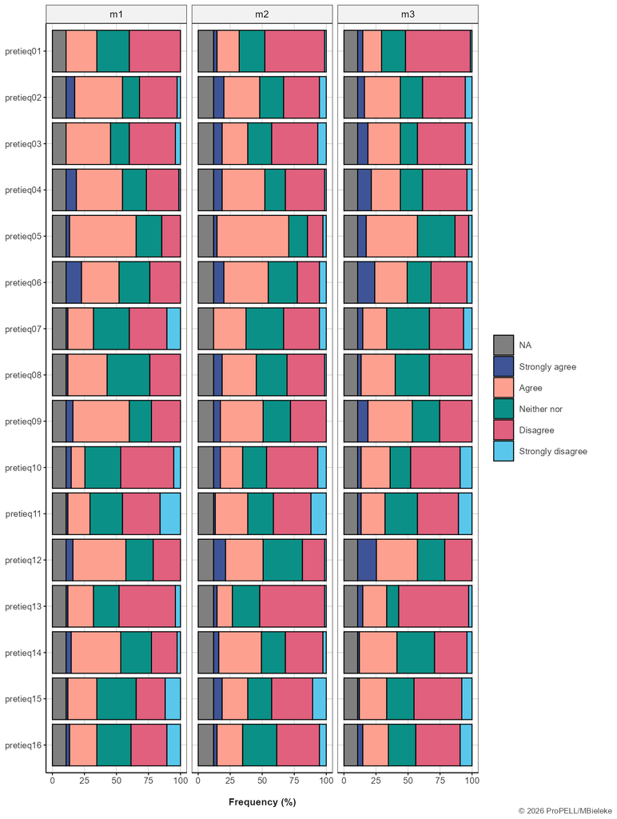

**Scale**

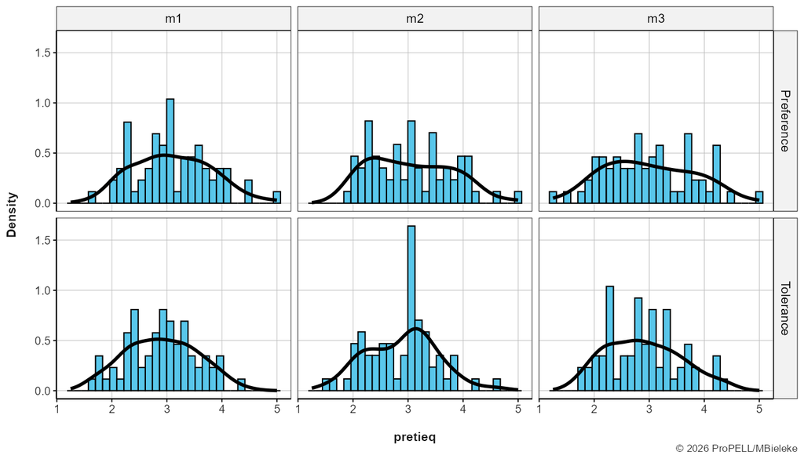

**Statistics**

**Items**

| Variable | N | #Valid | %Valid | Mean | SD | Min | Median | Max |
| --- | --- | --- | --- | --- | --- | --- | --- | --- |
| **pretieq01** |  |  |  |  |  |  |  |  |
| m1 | 75 | 67 | 89.33 | 2.82 | 0.83 | 2 | 3 | 4 |
| m2 | 75 | 66 | 88.00 | 2.70 | 0.91 | 1 | 2 | 5 |
| m3 | 75 | 67 | 89.33 | 2.66 | 0.93 | 1 | 2 | 5 |
| **pretieq02** |  |  |  |  |  |  |  |  |
| m1 | 75 | 67 | 89.33 | 3.18 | 1.07 | 1 | 3 | 5 |
| m2 | 75 | 66 | 88.00 | 3.06 | 1.12 | 1 | 3 | 5 |
| m3 | 75 | 67 | 89.33 | 2.94 | 1.09 | 1 | 3 | 5 |
| **pretieq03** |  |  |  |  |  |  |  |  |
| m1 | 75 | 67 | 89.33 | 2.90 | 0.99 | 1 | 3 | 4 |
| m2 | 75 | 66 | 88.00 | 2.82 | 1.11 | 1 | 3 | 5 |
| m3 | 75 | 67 | 89.33 | 2.93 | 1.15 | 1 | 3 | 5 |
| **pretieq04** |  |  |  |  |  |  |  |  |
| m1 | 75 | 67 | 89.33 | 3.27 | 1.02 | 1 | 3 | 5 |
| m2 | 75 | 66 | 88.00 | 3.15 | 1.04 | 1 | 3 | 5 |
| m3 | 75 | 67 | 89.33 | 3.01 | 1.15 | 1 | 3 | 5 |
| **pretieq05** |  |  |  |  |  |  |  |  |
| m1 | 75 | 67 | 89.33 | 3.48 | 0.80 | 2 | 4 | 5 |
| m2 | 75 | 66 | 88.00 | 3.50 | 0.88 | 1 | 4 | 5 |
| m3 | 75 | 67 | 89.33 | 3.42 | 0.91 | 1 | 4 | 5 |
| **pretieq06** |  |  |  |  |  |  |  |  |
| m1 | 75 | 67 | 89.33 | 3.33 | 1.02 | 2 | 3 | 5 |
| m2 | 75 | 66 | 88.00 | 3.26 | 1.07 | 1 | 3 | 5 |
| m3 | 75 | 67 | 89.33 | 3.18 | 1.17 | 1 | 3 | 5 |
| **pretieq07** |  |  |  |  |  |  |  |  |
| m1 | 75 | 67 | 89.33 | 2.69 | 1.00 | 1 | 3 | 5 |
| m2 | 75 | 66 | 88.00 | 2.85 | 0.92 | 1 | 3 | 4 |
| m3 | 75 | 67 | 89.33 | 2.85 | 0.99 | 1 | 3 | 5 |
| **pretieq08** |  |  |  |  |  |  |  |  |
| m1 | 75 | 67 | 89.33 | 3.10 | 0.82 | 2 | 3 | 5 |
| m2 | 75 | 66 | 88.00 | 3.09 | 1.00 | 1 | 3 | 5 |
| m3 | 75 | 67 | 89.33 | 2.99 | 0.90 | 2 | 3 | 5 |
| **pretieq09** |  |  |  |  |  |  |  |  |
| m1 | 75 | 67 | 89.33 | 3.36 | 0.93 | 2 | 4 | 5 |
| m2 | 75 | 66 | 88.00 | 3.18 | 0.96 | 2 | 3 | 5 |
| m3 | 75 | 67 | 89.33 | 3.28 | 0.98 | 2 | 3 | 5 |
| **pretieq10** |  |  |  |  |  |  |  |  |
| m1 | 75 | 67 | 89.33 | 2.63 | 0.93 | 1 | 2 | 5 |
| m2 | 75 | 66 | 88.00 | 2.71 | 1.06 | 1 | 2 | 5 |
| m3 | 75 | 67 | 89.33 | 2.67 | 1.06 | 1 | 2 | 5 |
| **pretieq11** |  |  |  |  |  |  |  |  |
| m1 | 75 | 67 | 89.33 | 2.54 | 1.05 | 1 | 2 | 5 |
| m2 | 75 | 66 | 88.00 | 2.71 | 1.08 | 1 | 3 | 5 |
| m3 | 75 | 67 | 89.33 | 2.67 | 1.04 | 1 | 3 | 5 |
| **pretieq12** |  |  |  |  |  |  |  |  |
| m1 | 75 | 67 | 89.33 | 3.34 | 0.91 | 2 | 4 | 5 |
| m2 | 75 | 66 | 88.00 | 3.32 | 0.96 | 1 | 3 | 5 |
| m3 | 75 | 67 | 89.33 | 3.45 | 1.03 | 2 | 4 | 5 |
| **pretieq13** |  |  |  |  |  |  |  |  |
| m1 | 75 | 67 | 89.33 | 2.67 | 0.93 | 1 | 2 | 5 |
| m2 | 75 | 66 | 88.00 | 2.59 | 0.86 | 1 | 2 | 5 |
| m3 | 75 | 67 | 89.33 | 2.63 | 1.00 | 1 | 2 | 5 |
| **pretieq14** |  |  |  |  |  |  |  |  |
| m1 | 75 | 67 | 89.33 | 3.24 | 0.95 | 1 | 3 | 5 |
| m2 | 75 | 66 | 88.00 | 3.08 | 1.01 | 1 | 3 | 5 |
| m3 | 75 | 67 | 89.33 | 2.99 | 0.93 | 1 | 3 | 5 |
| **pretieq15** |  |  |  |  |  |  |  |  |
| m1 | 75 | 67 | 89.33 | 2.76 | 1.03 | 1 | 3 | 5 |
| m2 | 75 | 66 | 88.00 | 2.77 | 1.16 | 1 | 3 | 5 |
| m3 | 75 | 67 | 89.33 | 2.67 | 0.99 | 1 | 2 | 5 |
| **pretieq16** |  |  |  |  |  |  |  |  |
| m1 | 75 | 67 | 89.33 | 2.75 | 1.05 | 1 | 3 | 5 |
| m2 | 75 | 66 | 88.00 | 2.79 | 0.97 | 1 | 3 | 5 |
| m3 | 75 | 67 | 89.33 | 2.72 | 1.07 | 1 | 3 | 5 |

**Scale**

| Variable | N | #Valid | %Valid | SD | Mean | Min | Median | Max | #Items | Alpha |
| --- | --- | --- | --- | --- | --- | --- | --- | --- | --- | --- |
| **pretieqp** |  |  |  |  |  |  |  |  |  |  |
| m1 | 75 | 67 | 89.33 | 0.71 | 3.10 | 1.62 | 3.12 | 5.00 | 8 | 0.87 |
| m2 | 75 | 66 | 88.00 | 0.76 | 3.06 | 1.88 | 3.00 | 5.00 | 8 | 0.88 |
| m3 | 75 | 67 | 89.33 | 0.83 | 2.99 | 1.25 | 2.88 | 5.00 | 8 | 0.91 |
| **pretieqt** |  |  |  |  |  |  |  |  |  |  |
| m1 | 75 | 67 | 89.33 | 0.65 | 2.90 | 1.62 | 2.88 | 4.38 | 8 | 0.84 |
| m2 | 75 | 66 | 88.00 | 0.64 | 2.89 | 1.50 | 3.00 | 4.62 | 8 | 0.80 |
| m3 | 75 | 67 | 89.33 | 0.67 | 2.89 | 1.75 | 2.75 | 4.38 | 8 | 0.83 |

### Overall ProBCT mean score

**Overview**

- **Variable Stem: `probct`**
- **Time Points:** m1, m2, m3
- **Reference:** Schüler & Bieleke (2023)

**Details**

**Items**

**Directions**: The following statements describe strategies that people commonly use to change their exercise and physical activity behavior. Please indicate the extent to which you use these strategies for your own exercise and physical activity goals. Strategies I use to achieve my exercise and physical activity goals:

| Variable | Scale | Prompt |
| --- | --- | --- |
| probct01 | Behavior-Health Link | I search for information about the relationship between sport and activity and health (e.g. on the Internet, physician). |
| probct02 | Costs and Benefits | I weigh the benefits and costs of sport and activity in terms of health outcomes. |
| probct03 | Social Approval | I consider whether or not other people like my changed sport and activity behavior. |
| probct04 | Intention Formation | I explicitly stated my desire to sport and activity as a goal (e.g., "I want to exercise more," "I will exercise next week"). |
| probct05 | Barrier Identification | I identify obstacles that interfere with my sport and activity behavior and look for solutions to overcome them. |
| probct06 | Self-Encouragement | I encourage myself to exert effort and perform (e.g., encouragement, reward). |
| probct07 | Graded Tasks | I start with easy tasks and increase the difficulty until I reach my sport and activity goal. |
| probct08 | Behavior Instruction | I look for information on how to best perform the sport and activity behavior (e.g., on the Internet, from friends). |
| probct09 | Expert Models | I am looking for experts (coaches, videos) to show me how to properly perform the sport and activity behavior. |
| probct10 | Goals and Plans | I make detailed plans for my sports and activity behavior (e.g., where, when, how, and with whom). |
| probct11 | Review and Rethink | I review and rethink my set sport and activity goal (e.g., Does it fit me? Is it realistic?). |
| probct12 | Self-Monitoring | I document my sport and activity behavior (e.g. diary, weekly log). |
| probct13 | Goal Feedback | I match my actual sport and activity behavior with my set goals and use this as feedback. |
| probct14 | Self-reward | I reward myself for achieving specific behavioral and subgoals (e.g., going to the movies for regular exercise participation; eating well for reaching step count). |
| probct15 | Cues and Prompts | I use cues from my environment to remind me to do sport and activity (e.g., fixed time, reminders). |
| probct16 | Behavioral Contract | I make my sport and activity goal public and binding (e.g., tell my partner or friends; write it down). |
| probct17 | Practice and Repetition | I practice and repeat behaviors that bring me closer to my sport and activity goal. |
| probct18 | Follow-up Prompts | I take precautions to remind myself to perform the sport and activity behavior in the future (e.g., automatic reminders, other reminders). |
| probct19 | Social Comparison | I seek opportunities to compare myself with others in my sport and activity behavior. |
| probct20 | Social Support | I look for social support to achieve my sport and activity goal (e.g., how can others support me?). |
| probct21 | Role Model | I try to be a role model for others with my sport and activity behavior and to positively influence their behavior. |
| probct22 | Self-Talk | I use self-instructions to motivate me to achieve my sport and activity goal (e.g., mental encouragement, concrete instructions). |
| probct23 | Relapse Prevention | I identify situations in which I could fall back into a sedentary behavior and try to avoid them. |
| probct24 | Stress Management | I specifically try to regulate stress (e.g., progressive muscle relaxation). |
| probct25 | Self-Motivation | I use self-motivating statements to minimize possible inner resistance to the sport and activity goal (e.g., "I can do it","Come on now, pull yourself together"). |
| probct26 | Time Management | I plan my time so that my sport and activity behavior fits into everyday life. |

Note. Variables with * have been reverse-coded

**Scale**

| Variable | Description |
| --- | --- |
| probct | Overall ProBCT mean score |

**Distribution**

**Items**

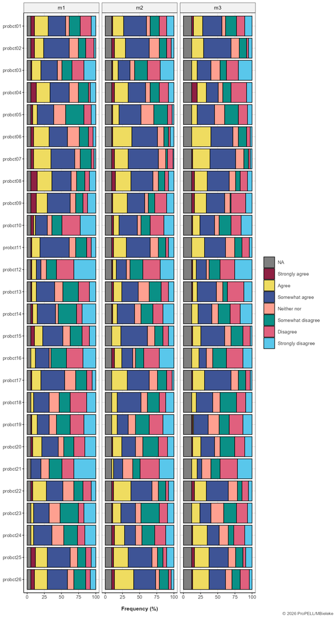

**Scale**

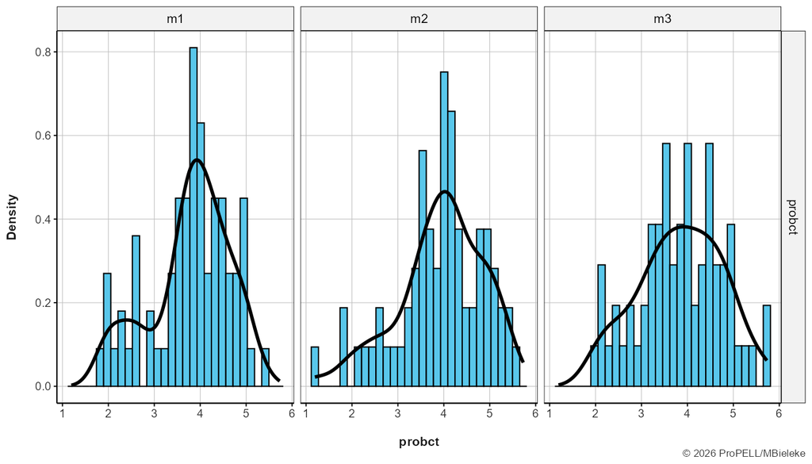

**Statistics**

**Items**

| Variable | N | #Valid | %Valid | Mean | SD | Min | Median | Max |
| --- | --- | --- | --- | --- | --- | --- | --- | --- |
| **probct01** |  |  |  |  |  |  |  |  |
| m1 | 75 | 71 | 94.67 | 4.14 | 1.77 | 1 | 5.0 | 7 |
| m2 | 75 | 68 | 90.67 | 4.03 | 1.71 | 1 | 5.0 | 7 |
| m3 | 75 | 66 | 88.00 | 3.89 | 1.75 | 1 | 4.5 | 7 |
| **probct02** |  |  |  |  |  |  |  |  |
| m1 | 75 | 71 | 94.67 | 4.39 | 1.49 | 1 | 5.0 | 7 |
| m2 | 75 | 68 | 90.67 | 4.47 | 1.45 | 1 | 5.0 | 7 |
| m3 | 75 | 66 | 88.00 | 4.48 | 1.35 | 1 | 5.0 | 6 |
| **probct03** |  |  |  |  |  |  |  |  |
| m1 | 75 | 71 | 94.67 | 3.51 | 1.81 | 1 | 3.0 | 7 |
| m2 | 75 | 68 | 90.67 | 3.13 | 1.73 | 1 | 3.0 | 7 |
| m3 | 75 | 66 | 88.00 | 3.23 | 1.73 | 1 | 3.0 | 6 |
| **probct04** |  |  |  |  |  |  |  |  |
| m1 | 75 | 71 | 94.67 | 4.51 | 1.65 | 1 | 5.0 | 7 |
| m2 | 75 | 68 | 90.67 | 4.15 | 1.76 | 1 | 5.0 | 7 |
| m3 | 75 | 66 | 88.00 | 3.85 | 1.91 | 1 | 4.0 | 7 |
| **probct05** |  |  |  |  |  |  |  |  |
| m1 | 75 | 71 | 94.67 | 3.76 | 1.46 | 1 | 4.0 | 7 |
| m2 | 75 | 68 | 90.67 | 4.15 | 1.30 | 1 | 4.0 | 7 |
| m3 | 75 | 66 | 88.00 | 3.71 | 1.45 | 1 | 4.0 | 6 |
| **probct06** |  |  |  |  |  |  |  |  |
| m1 | 75 | 71 | 94.67 | 4.48 | 1.49 | 1 | 5.0 | 7 |
| m2 | 75 | 68 | 90.67 | 4.76 | 1.39 | 1 | 5.0 | 7 |
| m3 | 75 | 66 | 88.00 | 4.65 | 1.38 | 1 | 5.0 | 6 |
| **probct07** |  |  |  |  |  |  |  |  |
| m1 | 75 | 71 | 94.67 | 4.69 | 1.40 | 1 | 5.0 | 7 |
| m2 | 75 | 68 | 90.67 | 4.81 | 1.28 | 1 | 5.0 | 7 |
| m3 | 75 | 66 | 88.00 | 4.82 | 1.24 | 1 | 5.0 | 7 |
| **probct08** |  |  |  |  |  |  |  |  |
| m1 | 75 | 71 | 94.67 | 4.48 | 1.79 | 1 | 5.0 | 7 |

[output cut: 74 more lines]

**Scale**

| Variable | N | #Valid | %Valid | SD | Mean | Min | Median | Max | #Items | Alpha |
| --- | --- | --- | --- | --- | --- | --- | --- | --- | --- | --- |
| **probct** |  |  |  |  |  |  |  |  |  |  |
| m1 | 75 | 71 | 94.67 | 0.86 | 3.79 | 1.81 | 3.92 | 5.38 | 26 | 0.90 |
| m2 | 75 | 68 | 90.67 | 0.93 | 3.94 | 1.19 | 4.02 | 5.50 | 26 | 0.92 |
| m3 | 75 | 66 | 88.00 | 0.91 | 3.85 | 2.00 | 3.90 | 5.73 | 26 | 0.92 |

### Overall PSDQ mean score

**Overview**

- **Variable Stem: `psdq`**
- **Time Points:** m1, m2, m3
- **Reference:** Stiller & Alfermann (2007)

**Details**

**Items**

**Directions**: The following statements concern your body awareness and how you would describe yourself in relation to your body. Please read each statement and choose a response.

| Variable | Scale | Prompt |
| --- | --- | --- |
| psdq01 | Coordination | I feel confident when doing coordinated movements. |
| psdq02 | Competence | Other people think that I am good at sports. |
| psdq03 | Flexibility | I'm quite good at bending, twisting, and turning my body. |
| psdq04 | Endurance | I can run a long way without stopping. |
| psdq05 | Coordination | Controlling movements of my body comes easily to me. |
| psdq06 | Competence | I am good at most sports. |
| psdq07 | Stength | I have a lot of power in my body. |
| psdq08 | Flexibility | My body is flexible. |
| psdq09 | Endurance | I would do well in a test of physical endurance and stamina. |
| psdq10 | Coordination | I am good at coordinated movements. |
| psdq11 | Competence | Most sports are easy for me. |
| psdq12 | Stength | I am stronger than most people my age. |
| psdq13* | Flexibility | My body is stiff and inflexible. |
| psdq14 | Endurance | I could jog 5 kilometers without stopping. |
| psdq15 | Coordination | I can perform movements smoothly in most physical activities. |
| psdq16 | Competence | I have good sport skills. |
| psdq17* | Stength | I am weak and have no muscles. |
| psdq18 | Flexibility | My body parts bend and move in most directions well. |
| psdq19 | Endurance | I think I could run a long way without getting tired. |
| psdq20 | Coordination | I find my body handles coordinated movements with ease. |
| psdq21 | Competence | I am better at sports than most of my friends. |
| psdq22 | Stength | I would do well in a test of strength. |
| psdq23 | Flexibility | I think I am flexible enough for most sports. |
| psdq24 | Endurance | I can be physically active for a long period of time without getting tired. |
| psdq25 | Coordination | I am graceful and coordinated when I do sports and activities. |
| psdq26 | Competence | I play sports well. |
| psdq27 | Stength | I am good at lifting heavy objects. |
| psdq28 | Flexibility | I think I would perform well on a test measuring flexibility. |
| psdq29 | Endurance | I am good at endurance activities like distance running, aerobics, bicycling, swimming, or cross-country skiing. |

Note. Variables with * have been reverse-coded

**Scale**

| Variable | Description |
| --- | --- |
| psdq | Overall PSDQ mean score |

**Distribution**

**Items**

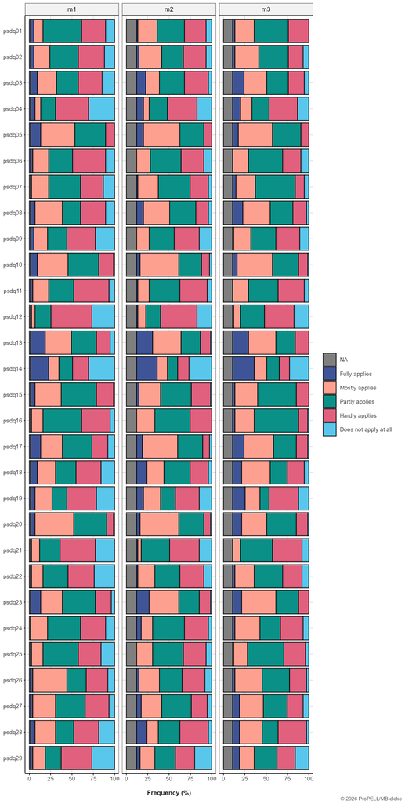

**Scale**

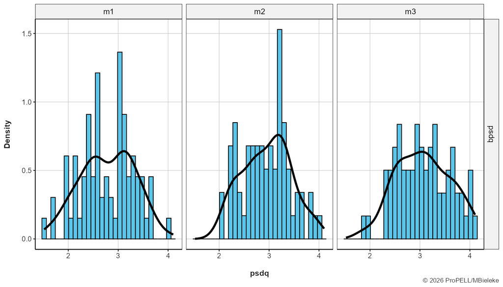

**Statistics**

**Items**

| Variable | N | #Valid | %Valid | Mean | SD | Min | Median | Max |
| --- | --- | --- | --- | --- | --- | --- | --- | --- |
| **psdq01** |  |  |  |  |  |  |  |  |
| m1 | 75 | 74 | 98.67 | 2.69 | 0.95 | 1 | 3.0 | 5 |
| m2 | 75 | 66 | 88.00 | 2.85 | 0.95 | 1 | 3.0 | 5 |
| m3 | 75 | 67 | 89.33 | 3.04 | 0.81 | 2 | 3.0 | 5 |
| **psdq02** |  |  |  |  |  |  |  |  |
| m1 | 75 | 74 | 98.67 | 2.72 | 1.04 | 1 | 3.0 | 5 |
| m2 | 75 | 66 | 88.00 | 2.91 | 1.02 | 1 | 3.0 | 5 |
| m3 | 75 | 67 | 89.33 | 3.03 | 0.97 | 1 | 3.0 | 5 |
| **psdq03** |  |  |  |  |  |  |  |  |
| m1 | 75 | 74 | 98.67 | 2.81 | 1.19 | 1 | 3.0 | 5 |
| m2 | 75 | 66 | 88.00 | 3.02 | 1.09 | 1 | 3.0 | 5 |
| m3 | 75 | 67 | 89.33 | 3.27 | 1.14 | 1 | 3.0 | 5 |
| **psdq04** |  |  |  |  |  |  |  |  |
| m1 | 75 | 74 | 98.67 | 2.16 | 1.11 | 1 | 2.0 | 5 |
| m2 | 75 | 66 | 88.00 | 2.47 | 1.17 | 1 | 2.0 | 5 |
| m3 | 75 | 67 | 89.33 | 2.69 | 1.21 | 1 | 2.0 | 5 |
| **psdq05** |  |  |  |  |  |  |  |  |
| m1 | 75 | 74 | 98.67 | 3.54 | 0.85 | 2 | 4.0 | 5 |
| m2 | 75 | 66 | 88.00 | 3.56 | 0.81 | 2 | 4.0 | 5 |
| m3 | 75 | 67 | 89.33 | 3.49 | 0.79 | 2 | 4.0 | 5 |
| **psdq06** |  |  |  |  |  |  |  |  |
| m1 | 75 | 74 | 98.67 | 2.64 | 1.00 | 1 | 2.5 | 5 |
| m2 | 75 | 66 | 88.00 | 2.67 | 0.90 | 1 | 3.0 | 4 |
| m3 | 75 | 67 | 89.33 | 2.76 | 0.91 | 1 | 3.0 | 4 |
| **psdq07** |  |  |  |  |  |  |  |  |
| m1 | 75 | 74 | 98.67 | 2.69 | 0.99 | 1 | 3.0 | 5 |
| m2 | 75 | 66 | 88.00 | 2.97 | 0.88 | 1 | 3.0 | 5 |
| m3 | 75 | 67 | 89.33 | 3.10 | 0.89 | 1 | 3.0 | 5 |
| **psdq08** |  |  |  |  |  |  |  |  |
| m1 | 75 | 74 | 98.67 | 2.92 | 1.13 | 1 | 3.0 | 5 |

[output cut: 86 more lines]

**Scale**

| Variable | N | #Valid | %Valid | SD | Mean | Min | Median | Max | #Items | Alpha |
| --- | --- | --- | --- | --- | --- | --- | --- | --- | --- | --- |
| **psdq** |  |  |  |  |  |  |  |  |  |  |
| m1 | 75 | 74 | 98.67 | 0.54 | 2.78 | 1.52 | 2.78 | 4.0 | 29 | 0.90 |
| m2 | 75 | 66 | 88.00 | 0.48 | 2.96 | 2.03 | 2.98 | 4.0 | 29 | 0.88 |
| m3 | 75 | 67 | 89.33 | 0.53 | 3.07 | 1.90 | 3.03 | 4.1 | 29 | 0.91 |

### Subjective rating of physical activity relative to peers

**Overview**

- **Variable Stem: `relfit`**
- **Time Points:** m1, m2, m3
- **Reference:** Custom item

**Details**

Imagine that the following scale represents the typical physical activity of people of your age and sex. A value of 0 represents people with the lowest level of physical activity (in terms of the amount of movement, sport and training). A value of 100 represents people with the highest level of physical activity. Please indicate your own position on this scale:

**Distribution**

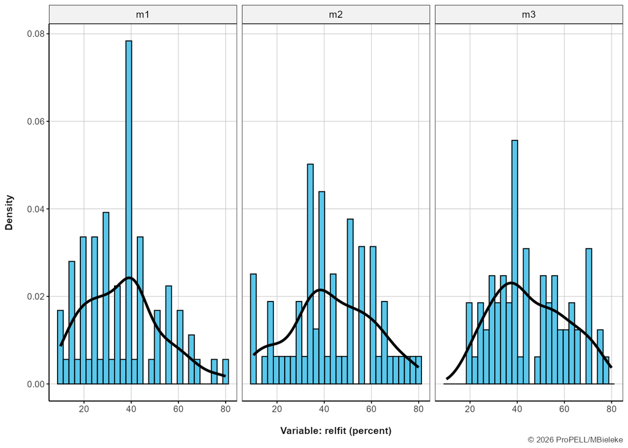

**Statistics**

| Time | N | % | %Val | Mean | SD | Min | Median | Max |
| --- | --- | --- | --- | --- | --- | --- | --- | --- |
| m1 | 75 | 74 | 98.67 | 36.36 | 16.01 | 10 | 38 | 80 |
| m2 | 75 | 66 | 88.00 | 43.21 | 17.77 | 10 | 41 | 80 |
| m3 | 75 | 67 | 89.33 | 45.60 | 15.55 | 20 | 44 | 77 |

### Overall RSES mean score

**Overview**

- **Variable Stem: `rses`**
- **Time Points:** m1, m2, m3
- **Reference:** Von Collani & Herzberg (2003)

**Details**

**Items**

**Directions**: There are no right or wrong answers. Please select the option that applies.

| Variable | Prompt |
| --- | --- |
| rses01 | On the whole, I am satisfied with myself. |
| rses02* | At times I think I am no good at all. |
| rses03 | I feel that I have a number of good qualities. |
| rses04 | I am able to do things as well as most other people. |
| rses05* | I feel 1do not have much to be proud of. |
| rses06* | I certainly feel useless at times. |
| rses07 | I feel that I'm a person of worth. |
| rses08* | I wish I could have more respect for myself. |
| rses09* | All in all, I am inclined to think that I am a failure. |
| rses10 | I take a positive attitude toward myself. |

Note. Variables with * have been reverse-coded

**Scale**

| Variable | Description |
| --- | --- |
| rses | Overall RSES mean score |

**Distribution**

**Items**

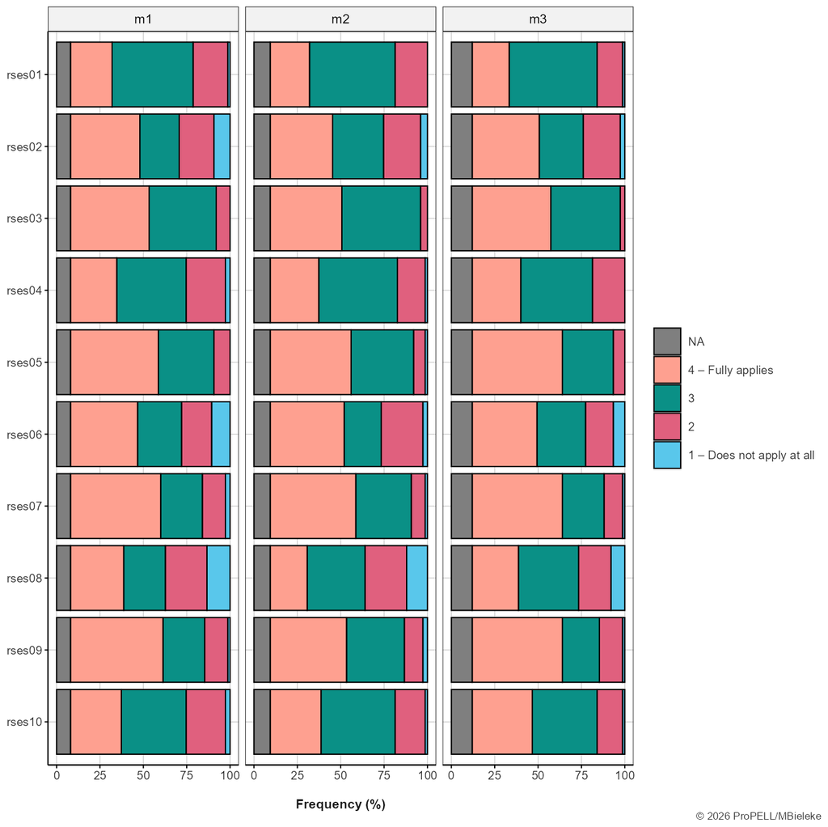

**Scale**

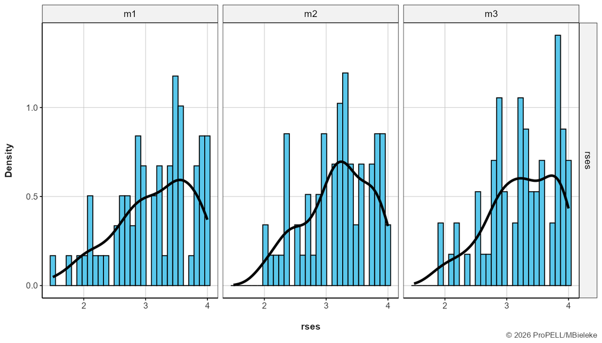

**Statistics**

**Items**

| Variable | N | #Valid | %Valid | Mean | SD | Min | Median | Max |
| --- | --- | --- | --- | --- | --- | --- | --- | --- |
| **rses01** |  |  |  |  |  |  |  |  |
| m1 | 75 | 69 | 92.00 | 3.01 | 0.74 | 1 | 3 | 4 |
| m2 | 75 | 68 | 90.67 | 3.04 | 0.68 | 2 | 3 | 4 |
| m3 | 75 | 66 | 88.00 | 3.05 | 0.69 | 1 | 3 | 4 |
| **rses02** |  |  |  |  |  |  |  |  |
| m1 | 75 | 69 | 92.00 | 3.01 | 1.04 | 1 | 3 | 4 |
| m2 | 75 | 68 | 90.67 | 3.07 | 0.90 | 1 | 3 | 4 |
| m3 | 75 | 66 | 88.00 | 3.14 | 0.89 | 1 | 3 | 4 |
| **rses03** |  |  |  |  |  |  |  |  |
| m1 | 75 | 69 | 92.00 | 3.41 | 0.65 | 2 | 3 | 4 |
| m2 | 75 | 68 | 90.67 | 3.41 | 0.58 | 2 | 3 | 4 |
| m3 | 75 | 66 | 88.00 | 3.48 | 0.56 | 2 | 4 | 4 |
| **rses04** |  |  |  |  |  |  |  |  |
| m1 | 75 | 69 | 92.00 | 2.99 | 0.81 | 1 | 3 | 4 |
| m2 | 75 | 68 | 90.67 | 3.10 | 0.74 | 1 | 3 | 4 |
| m3 | 75 | 66 | 88.00 | 3.11 | 0.73 | 2 | 3 | 4 |
| **rses05** |  |  |  |  |  |  |  |  |
| m1 | 75 | 69 | 92.00 | 3.45 | 0.68 | 2 | 4 | 4 |
| m2 | 75 | 68 | 90.67 | 3.41 | 0.70 | 1 | 4 | 4 |
| m3 | 75 | 66 | 88.00 | 3.52 | 0.64 | 2 | 4 | 4 |
| **rses06** |  |  |  |  |  |  |  |  |
| m1 | 75 | 69 | 92.00 | 3.00 | 1.04 | 1 | 3 | 4 |
| m2 | 75 | 68 | 90.67 | 3.15 | 0.92 | 1 | 3 | 4 |
| m3 | 75 | 66 | 88.00 | 3.09 | 0.96 | 1 | 3 | 4 |
| **rses07** |  |  |  |  |  |  |  |  |
| m1 | 75 | 69 | 92.00 | 3.36 | 0.84 | 1 | 4 | 4 |
| m2 | 75 | 68 | 90.67 | 3.43 | 0.72 | 1 | 4 | 4 |
| m3 | 75 | 66 | 88.00 | 3.44 | 0.77 | 1 | 4 | 4 |
| **rses08** |  |  |  |  |  |  |  |  |
| m1 | 75 | 69 | 92.00 | 2.78 | 1.07 | 1 | 3 | 4 |
| m2 | 75 | 68 | 90.67 | 2.71 | 0.98 | 1 | 3 | 4 |
| m3 | 75 | 66 | 88.00 | 2.91 | 0.94 | 1 | 3 | 4 |
| **rses09** |  |  |  |  |  |  |  |  |
| m1 | 75 | 69 | 92.00 | 3.41 | 0.79 | 1 | 4 | 4 |
| m2 | 75 | 68 | 90.67 | 3.31 | 0.80 | 1 | 3 | 4 |
| m3 | 75 | 66 | 88.00 | 3.41 | 0.80 | 1 | 4 | 4 |
| **rses10** |  |  |  |  |  |  |  |  |
| m1 | 75 | 69 | 92.00 | 3.01 | 0.83 | 1 | 3 | 4 |
| m2 | 75 | 68 | 90.67 | 3.10 | 0.76 | 1 | 3 | 4 |
| m3 | 75 | 66 | 88.00 | 3.20 | 0.77 | 1 | 3 | 4 |

**Scale**

| Variable | N | #Valid | %Valid | SD | Mean | Min | Median | Max | #Items | Alpha |
| --- | --- | --- | --- | --- | --- | --- | --- | --- | --- | --- |
| **rses** |  |  |  |  |  |  |  |  |  |  |
| m1 | 75 | 69 | 92.00 | 0.63 | 3.14 | 1.5 | 3.2 | 4 | 10 | 0.90 |
| m2 | 75 | 68 | 90.67 | 0.54 | 3.17 | 2.0 | 3.2 | 4 | 10 | 0.87 |
| m3 | 75 | 66 | 88.00 | 0.56 | 3.23 | 1.9 | 3.3 | 4 | 10 | 0.89 |

### No overall RSQD score is computed

**Overview**

- **Variable Stem: `rsqd`**
- **Time Points:** m1, m2, m3
- **Reference:** Kühner et al. (2007)

**Details**

**Items**

**Directions**: People think and behave differently when they feel sad or down. Please indicate for each of the following statements whether you “almost never,” “sometimes,” “often,” or “almost always” think or do this when you feel sad, down, or depressed. Please indicate what you usually do when you feel sad or down, not what you think you should do.

[output not shown]

Note. Variables with * have been reverse-coded

**Scale**

| Variable | Description |
| --- | --- |
| rsqd | No overall RSQD score is computed |
| rsqddis | Mean score of Distraction items |
| rsqdser | Mean score of Self-Focused Rumination items |
| rsqdsyr | Mean score of Symptom-Focused Rumination items |

**Distribution**

**Items**

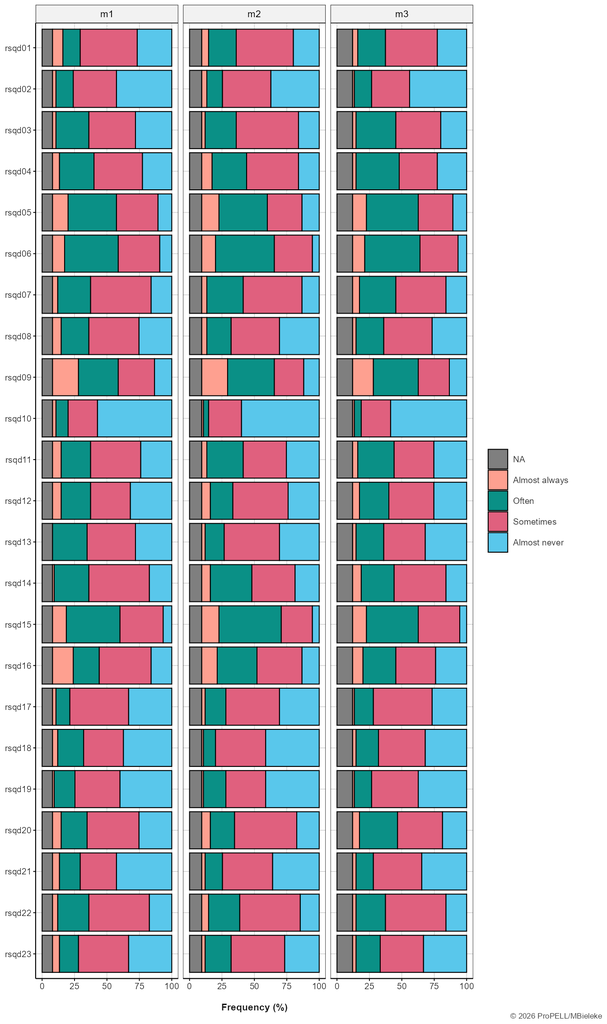

**Scale**

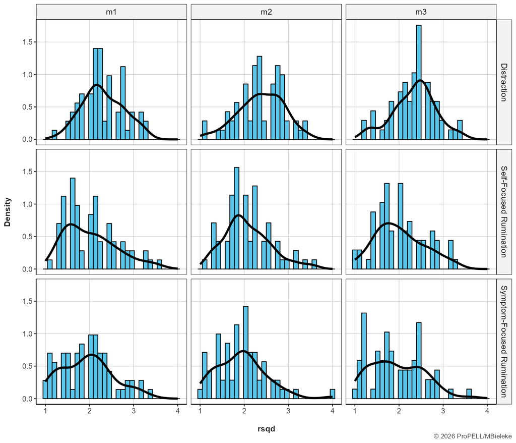

**Statistics**

**Items**

| Variable | N | #Valid | %Valid | Mean | SD | Min | Median | Max |
| --- | --- | --- | --- | --- | --- | --- | --- | --- |
| **rsqd01** |  |  |  |  |  |  |  |  |
| m1 | 75 | 69 | 92.00 | 2.03 | 0.89 | 1 | 2.0 | 4 |
| m2 | 75 | 68 | 90.67 | 2.13 | 0.83 | 1 | 2.0 | 4 |
| m3 | 75 | 66 | 88.00 | 2.08 | 0.83 | 1 | 2.0 | 4 |
| **rsqd02** |  |  |  |  |  |  |  |  |
| m1 | 75 | 69 | 92.00 | 1.74 | 0.82 | 1 | 2.0 | 4 |
| m2 | 75 | 68 | 90.67 | 1.81 | 0.83 | 1 | 2.0 | 4 |
| m3 | 75 | 66 | 88.00 | 1.68 | 0.79 | 1 | 1.5 | 4 |
| **rsqd03** |  |  |  |  |  |  |  |  |
| m1 | 75 | 69 | 92.00 | 2.03 | 0.84 | 1 | 2.0 | 4 |
| m2 | 75 | 68 | 90.67 | 2.15 | 0.74 | 1 | 2.0 | 4 |
| m3 | 75 | 66 | 88.00 | 2.18 | 0.82 | 1 | 2.0 | 4 |
| **rsqd04** |  |  |  |  |  |  |  |  |
| m1 | 75 | 69 | 92.00 | 2.16 | 0.87 | 1 | 2.0 | 4 |
| m2 | 75 | 68 | 90.67 | 2.29 | 0.86 | 1 | 2.0 | 4 |
| m3 | 75 | 66 | 88.00 | 2.18 | 0.86 | 1 | 2.0 | 4 |
| **rsqd05** |  |  |  |  |  |  |  |  |
| m1 | 75 | 69 | 92.00 | 2.55 | 0.87 | 1 | 3.0 | 4 |
| m2 | 75 | 68 | 90.67 | 2.56 | 0.92 | 1 | 3.0 | 4 |
| m3 | 75 | 66 | 88.00 | 2.58 | 0.86 | 1 | 3.0 | 4 |
| **rsqd06** |  |  |  |  |  |  |  |  |
| m1 | 75 | 69 | 92.00 | 2.55 | 0.81 | 1 | 3.0 | 4 |
| m2 | 75 | 68 | 90.67 | 2.68 | 0.76 | 1 | 3.0 | 4 |
| m3 | 75 | 66 | 88.00 | 2.62 | 0.78 | 1 | 3.0 | 4 |
| **rsqd07** |  |  |  |  |  |  |  |  |
| m1 | 75 | 69 | 92.00 | 2.19 | 0.77 | 1 | 2.0 | 4 |
| m2 | 75 | 68 | 90.67 | 2.25 | 0.76 | 1 | 2.0 | 4 |
| m3 | 75 | 66 | 88.00 | 2.26 | 0.83 | 1 | 2.0 | 4 |
| **rsqd08** |  |  |  |  |  |  |  |  |
| m1 | 75 | 69 | 92.00 | 2.10 | 0.89 | 1 | 2.0 | 4 |

[output cut: 62 more lines]

**Scale**

[output not shown]

### Overall SBPS mean score

**Overview**

- **Variable Stem: `sbps`**
- **Time Points:** m1, m2, m3
- **Reference:** Struk et al. (2017)

**Details**

**Items**

**Directions**: Please indicate how much the following statements apply to you.

| Variable | Prompt |
| --- | --- |
| sbps01 | I often find myself at "loose ends," not knowing what to do. |
| sbps02 | I find it hard to entertain myself. |
| sbps03 | Many things I have to do are repetitive and monotonous. |
| sbps04 | It takes more stimulation to get me going than most people. |
| sbps05 | I don’t feel motivated by most things that I do. |
| sbps06 | In most situations, it is hard for me to find something to do or see to keep me interested. |
| sbps07 | Much of the time, I just sit around doing nothing. |
| sbps08 | Unless I am doing something exciting, even dangerous, I feel half-dead and dull. |

Note. Variables with * have been reverse-coded

**Scale**

| Variable | Description |
| --- | --- |
| sbps | Overall SBPS mean score |

**Distribution**

**Items**

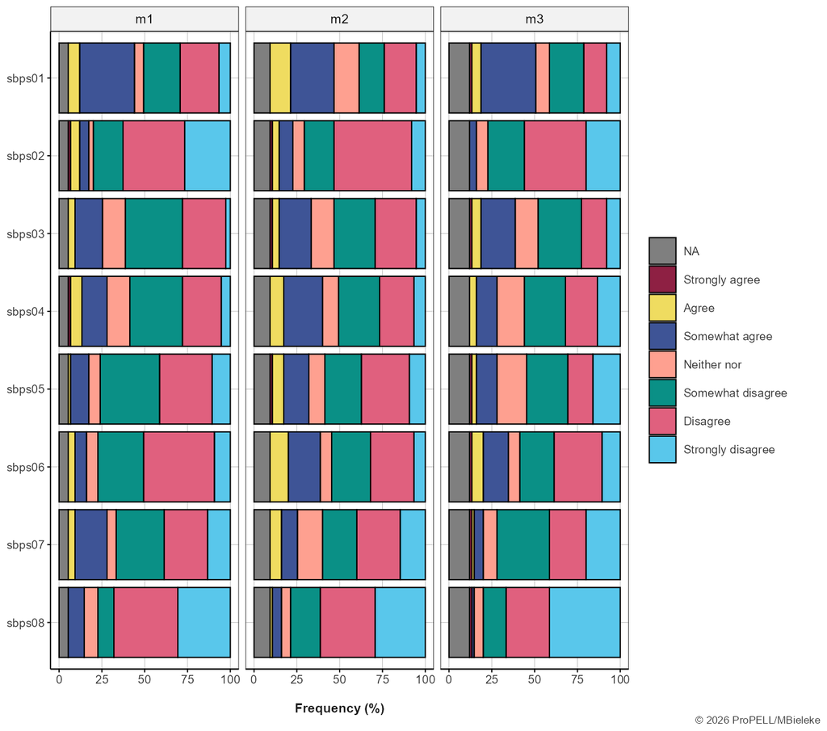

**Scale**

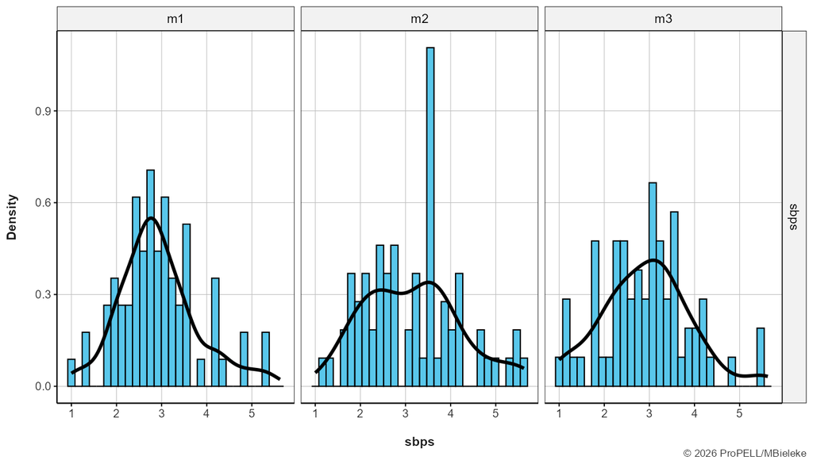

**Statistics**

**Items**

| Variable | N | #Valid | %Valid | Mean | SD | Min | Median | Max |
| --- | --- | --- | --- | --- | --- | --- | --- | --- |
| **sbps01** |  |  |  |  |  |  |  |  |
| m1 | 75 | 71 | 94.67 | 3.56 | 1.51 | 1 | 3 | 6 |
| m2 | 75 | 68 | 90.67 | 3.79 | 1.52 | 1 | 4 | 6 |
| m3 | 75 | 66 | 88.00 | 3.73 | 1.53 | 1 | 4 | 7 |
| **sbps02** |  |  |  |  |  |  |  |  |
| m1 | 75 | 71 | 94.67 | 2.42 | 1.48 | 1 | 2 | 7 |
| m2 | 75 | 68 | 90.67 | 2.76 | 1.37 | 1 | 2 | 7 |
| m3 | 75 | 66 | 88.00 | 2.30 | 1.05 | 1 | 2 | 5 |
| **sbps03** |  |  |  |  |  |  |  |  |
| m1 | 75 | 71 | 94.67 | 3.28 | 1.23 | 1 | 3 | 6 |
| m2 | 75 | 68 | 90.67 | 3.37 | 1.41 | 1 | 3 | 7 |
| m3 | 75 | 66 | 88.00 | 3.50 | 1.47 | 1 | 3 | 7 |
| **sbps04** |  |  |  |  |  |  |  |  |
| m1 | 75 | 71 | 94.67 | 3.37 | 1.41 | 1 | 3 | 7 |
| m2 | 75 | 68 | 90.67 | 3.50 | 1.48 | 1 | 3 | 6 |
| m3 | 75 | 66 | 88.00 | 3.08 | 1.41 | 1 | 3 | 6 |
| **sbps05** |  |  |  |  |  |  |  |  |
| m1 | 75 | 71 | 94.67 | 2.79 | 1.18 | 1 | 3 | 6 |
| m2 | 75 | 68 | 90.67 | 3.19 | 1.54 | 1 | 3 | 7 |
| m3 | 75 | 66 | 88.00 | 3.09 | 1.48 | 1 | 3 | 7 |
| **sbps06** |  |  |  |  |  |  |  |  |
| m1 | 75 | 71 | 94.67 | 2.70 | 1.22 | 1 | 2 | 6 |
| m2 | 75 | 68 | 90.67 | 3.41 | 1.55 | 1 | 3 | 6 |
| m3 | 75 | 66 | 88.00 | 3.14 | 1.58 | 1 | 3 | 7 |
| **sbps07** |  |  |  |  |  |  |  |  |
| m1 | 75 | 71 | 94.67 | 3.03 | 1.44 | 1 | 3 | 6 |
| m2 | 75 | 68 | 90.67 | 2.99 | 1.48 | 1 | 3 | 6 |
| m3 | 75 | 66 | 88.00 | 2.62 | 1.32 | 1 | 3 | 7 |
| **sbps08** |  |  |  |  |  |  |  |  |
| m1 | 75 | 71 | 94.67 | 2.24 | 1.27 | 1 | 2 | 5 |
| m2 | 75 | 68 | 90.67 | 2.22 | 1.22 | 1 | 2 | 6 |
| m3 | 75 | 66 | 88.00 | 1.92 | 1.18 | 1 | 2 | 7 |

**Scale**

| Variable | N | #Valid | %Valid | SD | Mean | Min | Median | Max | #Items | Alpha |
| --- | --- | --- | --- | --- | --- | --- | --- | --- | --- | --- |
| **sbps** |  |  |  |  |  |  |  |  |  |  |
| m1 | 75 | 71 | 94.67 | 0.87 | 2.92 | 1.00 | 2.75 | 5.38 | 8 | 0.80 |
| m2 | 75 | 68 | 90.67 | 1.06 | 3.15 | 1.12 | 3.25 | 5.62 | 8 | 0.87 |
| m3 | 75 | 66 | 88.00 | 0.97 | 2.92 | 1.00 | 2.94 | 5.50 | 8 | 0.85 |

### No overall SCQ score is computed

**Overview**

- **Variable Stem: `scq`**
- **Time Points:** m1, m2, m3
- **Reference:** Scanlan et al. (2016)

**Details**

**Items**

**Directions**: Based on your experiences with sport, please indicate how much you agree or disagree with each statement. There are no right or wrong answers. We are only interested in your honest opinion regarding the following statements.

[output not shown]

Note. Variables with * have been reverse-coded

**Scale**

| Variable | Description |
| --- | --- |
| scq | No overall SCQ score is computed |
| scqcc | Mean score of Constrained items |
| scqec | Mean score of Enthusiastic items |

**Distribution**

**Items**

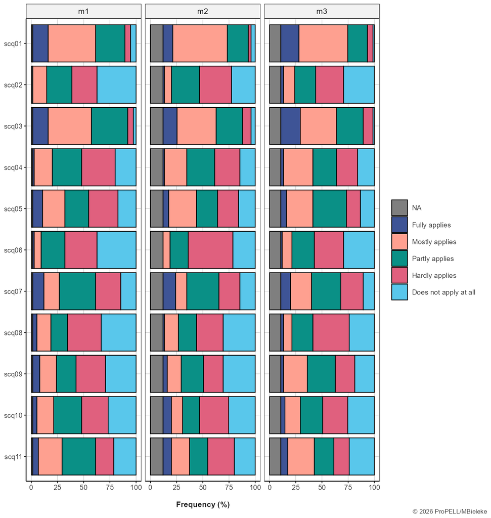

**Scale**

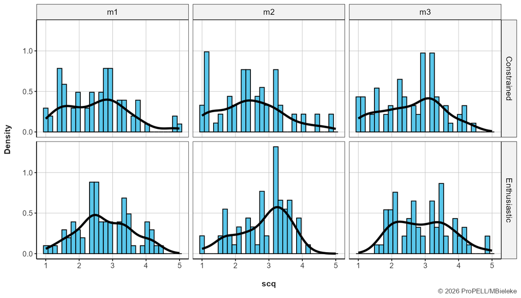

**Statistics**

**Items**

| Variable | N | #Valid | %Valid | Mean | SD | Min | Median | Max |
| --- | --- | --- | --- | --- | --- | --- | --- | --- |
| **scq01** |  |  |  |  |  |  |  |  |
| m1 | 75 | 74 | 98.67 | 3.59 | 0.99 | 1 | 4 | 5 |
| m2 | 75 | 66 | 88.00 | 3.68 | 0.88 | 1 | 4 | 5 |
| m3 | 75 | 67 | 89.33 | 3.82 | 0.87 | 1 | 4 | 5 |
| **scq02** |  |  |  |  |  |  |  |  |
| m1 | 75 | 74 | 98.67 | 2.14 | 1.08 | 1 | 2 | 4 |
| m2 | 75 | 66 | 88.00 | 2.24 | 0.98 | 1 | 2 | 5 |
| m3 | 75 | 67 | 89.33 | 2.22 | 1.13 | 1 | 2 | 5 |
| **scq03** |  |  |  |  |  |  |  |  |
| m1 | 75 | 74 | 98.67 | 3.61 | 0.90 | 1 | 4 | 5 |
| m2 | 75 | 66 | 88.00 | 3.55 | 1.01 | 1 | 4 | 5 |
| m3 | 75 | 67 | 89.33 | 3.67 | 0.98 | 1 | 4 | 5 |
| **scq04** |  |  |  |  |  |  |  |  |
| m1 | 75 | 74 | 98.67 | 2.47 | 1.05 | 1 | 2 | 5 |
| m2 | 75 | 66 | 88.00 | 2.67 | 1.07 | 1 | 3 | 5 |
| m3 | 75 | 67 | 89.33 | 2.79 | 1.16 | 1 | 3 | 5 |
| **scq05** |  |  |  |  |  |  |  |  |
| m1 | 75 | 74 | 98.67 | 2.77 | 1.24 | 1 | 3 | 5 |
| m2 | 75 | 66 | 88.00 | 2.83 | 1.22 | 1 | 3 | 5 |
| m3 | 75 | 67 | 89.33 | 2.96 | 1.13 | 1 | 3 | 5 |
| **scq06** |  |  |  |  |  |  |  |  |
| m1 | 75 | 74 | 98.67 | 2.03 | 1.01 | 1 | 2 | 5 |
| m2 | 75 | 66 | 88.00 | 2.11 | 0.86 | 1 | 2 | 4 |
| m3 | 75 | 67 | 89.33 | 2.16 | 1.05 | 1 | 2 | 5 |
| **scq07** |  |  |  |  |  |  |  |  |
| m1 | 75 | 74 | 98.67 | 2.82 | 1.19 | 1 | 3 | 5 |
| m2 | 75 | 66 | 88.00 | 2.83 | 1.25 | 1 | 3 | 5 |
| m3 | 75 | 67 | 89.33 | 2.96 | 1.17 | 1 | 3 | 5 |
| **scq08** |  |  |  |  |  |  |  |  |
| m1 | 75 | 74 | 98.67 | 2.22 | 1.17 | 1 | 2 | 5 |
| m2 | 75 | 66 | 88.00 | 2.20 | 1.13 | 1 | 2 | 5 |
| m3 | 75 | 67 | 89.33 | 2.22 | 1.04 | 1 | 2 | 5 |
| **scq09** |  |  |  |  |  |  |  |  |
| m1 | 75 | 74 | 98.67 | 2.42 | 1.26 | 1 | 2 | 5 |
| m2 | 75 | 66 | 88.00 | 2.33 | 1.23 | 1 | 2 | 5 |
| m3 | 75 | 67 | 89.33 | 2.69 | 1.16 | 1 | 3 | 5 |
| **scq10** |  |  |  |  |  |  |  |  |
| m1 | 75 | 74 | 98.67 | 2.45 | 1.17 | 1 | 2 | 5 |
| m2 | 75 | 66 | 88.00 | 2.41 | 1.28 | 1 | 2 | 5 |
| m3 | 75 | 67 | 89.33 | 2.42 | 1.20 | 1 | 2 | 5 |
| **scq11** |  |  |  |  |  |  |  |  |
| m1 | 75 | 74 | 98.67 | 2.73 | 1.20 | 1 | 3 | 5 |
| m2 | 75 | 66 | 88.00 | 2.64 | 1.28 | 1 | 2 | 5 |
| m3 | 75 | 67 | 89.33 | 2.73 | 1.33 | 1 | 3 | 5 |

**Scale**

[output not shown]

### Biological sex of participant

**Overview**

- **Variable Stem: `sex`**
- **Time Points:** m1
- **Reference:** Custom item

**Details**

What is your sex?

**Distribution**

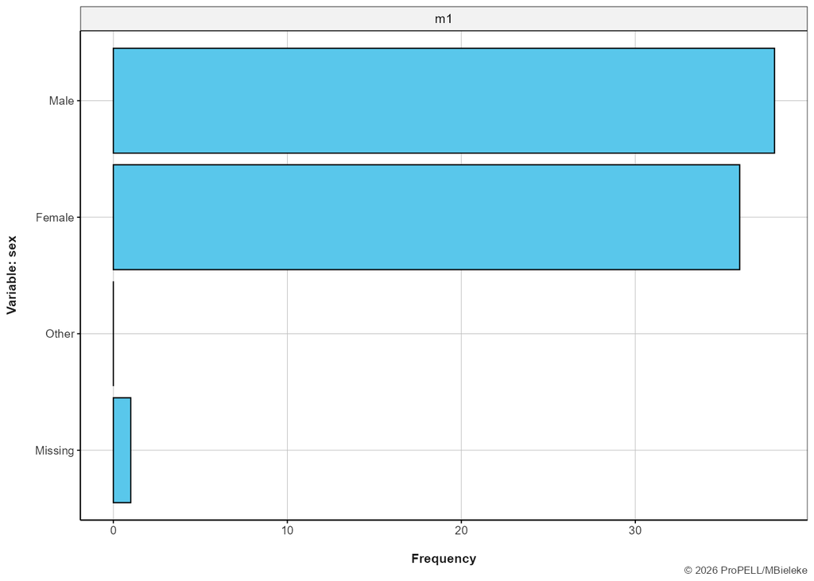

**Statistics**

| Answer | N | % | %Val |
| --- | --- | --- | --- |
| **Male** |  |  |  |
| m1 | 38 | 50.7 | 51.4 |
| **Female** |  |  |  |
| m1 | 36 | 48.0 | 48.6 |
| **Other** |  |  |  |
| m1 | 0 | 0.0 | 0.0 |
| **Missing** |  |  |  |
| m1 | 1 | 1.3 | --- |

### No overall SOER score is computed

**Overview**

- **Variable Stem: `soer`**
- **Time Points:** m1, m2, m3
- **Reference:** Custom scale

**Details**

**Items**

**Directions**: Which of the following “symptoms of exertion” do you experience during exercise? Please use the following scale to rate how you perceive them.

| Variable | Prompt |
| --- | --- |
| soer01 | Sweating |
| soer02 | Red face |
| soer03 | Burning in the muscles |
| soer04 | Muscle trembling |
| soer05 | Heavier breathing |
| soer06 | Being out of breath |
| soer07 | Stronger and faster heartbeat |

Note. Variables with * have been reverse-coded

**Scale**

| Variable | Description |
| --- | --- |
| soer | No overall SOER score is computed |

**Distribution**

**Items**

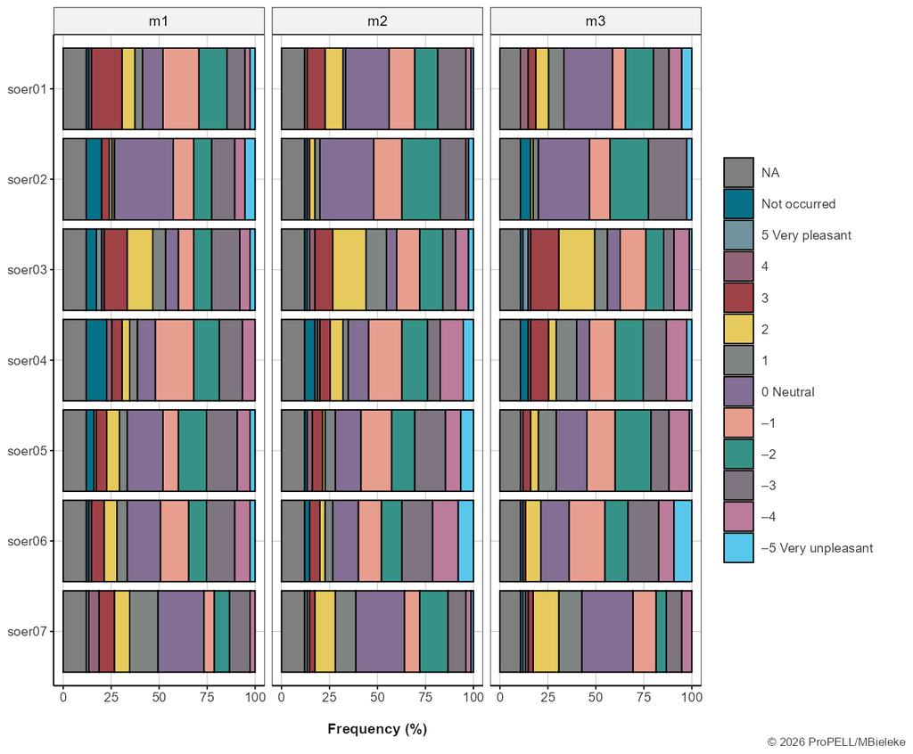

**Scale**

No overall score is available for this scale.

**Statistics**

**Items**

| Variable | N | #Valid | %Valid | Mean | SD | Min | Median | Max |
| --- | --- | --- | --- | --- | --- | --- | --- | --- |
| **soer01** |  |  |  |  |  |  |  |  |
| m1 | 75 | 66 | 88.00 | 5.76 | 2.42 | 1 | 5.0 | 12 |
| m2 | 75 | 66 | 88.00 | 5.48 | 2.12 | 1 | 5.5 | 10 |
| m3 | 75 | 67 | 89.33 | 5.28 | 2.30 | 1 | 6.0 | 10 |
| **soer02** |  |  |  |  |  |  |  |  |
| m1 | 75 | 66 | 88.00 | 5.44 | 2.80 | 1 | 6.0 | 12 |
| m2 | 75 | 66 | 88.00 | 4.94 | 1.79 | 1 | 5.0 | 12 |
| m3 | 75 | 67 | 89.33 | 5.03 | 2.27 | 1 | 5.0 | 12 |
| **soer03** |  |  |  |  |  |  |  |  |
| m1 | 75 | 66 | 88.00 | 6.17 | 2.99 | 1 | 6.0 | 12 |
| m2 | 75 | 66 | 88.00 | 6.03 | 2.59 | 1 | 6.0 | 12 |
| m3 | 75 | 67 | 89.33 | 6.31 | 2.61 | 1 | 7.0 | 12 |
| **soer04** |  |  |  |  |  |  |  |  |
| m1 | 75 | 66 | 88.00 | 5.92 | 3.00 | 2 | 5.0 | 12 |
| m2 | 75 | 66 | 88.00 | 5.29 | 2.91 | 1 | 5.0 | 12 |
| m3 | 75 | 67 | 89.33 | 5.34 | 2.73 | 1 | 5.0 | 12 |
| **soer05** |  |  |  |  |  |  |  |  |
| m1 | 75 | 66 | 88.00 | 5.29 | 2.59 | 1 | 5.0 | 12 |
| m2 | 75 | 66 | 88.00 | 4.74 | 2.43 | 1 | 5.0 | 12 |
| m3 | 75 | 67 | 89.33 | 4.94 | 2.02 | 1 | 5.0 | 10 |
| **soer06** |  |  |  |  |  |  |  |  |
| m1 | 75 | 66 | 88.00 | 5.20 | 2.36 | 1 | 5.0 | 12 |
| m2 | 75 | 66 | 88.00 | 4.48 | 2.56 | 1 | 4.0 | 12 |
| m3 | 75 | 67 | 89.33 | 4.42 | 2.24 | 1 | 4.0 | 12 |
| **soer07** |  |  |  |  |  |  |  |  |
| m1 | 75 | 66 | 88.00 | 6.21 | 2.17 | 2 | 6.0 | 11 |
| m2 | 75 | 66 | 88.00 | 5.65 | 2.00 | 1 | 6.0 | 11 |
| m3 | 75 | 67 | 89.33 | 5.99 | 2.09 | 2 | 6.0 | 12 |

**Scale**

No overall score is available for this scale.

### Overall SRHI mean score

**Overview**

- **Variable Stem: `srhi`**
- **Time Points:** m1, m2, m3
- **Reference:** Verplanken & Orbell (2003)

**Details**

**Items**

**Directions**: Please indicate how strongly you agree with each of the following statements.

| Variable | Prompt |
| --- | --- |
| srhi01 | Sport is something ... I do frequently. |
| srhi02 | Sport is something ... I do automatically. |
| srhi03 | Sport is something ... I do without having to consciously remember. |
| srhi04 | Sport is something ... that makes me feel weird if I do not do it. |
| srhi05 | Sport is something ... I do without thinking. |
| srhi06 | Sport is something ... that would require effort not to do it. |
| srhi07 | Sport is something ... that belongs to my weekly routine. |
| srhi08 | Sport is something ... I start doing before I realize I’m doing it. |
| srhi09 | Sport is something ... I would find hard not to do. |
| srhi10 | Sport is something ... I have no need to think about doing. |
| srhi11 | Sport is something ... that’s typically "me." |
| srhi12 | Sport is something ... I have been doing for a long time. |

Note. Variables with * have been reverse-coded

**Scale**

| Variable | Description |
| --- | --- |
| srhi | Overall SRHI mean score |

**Distribution**

**Items**

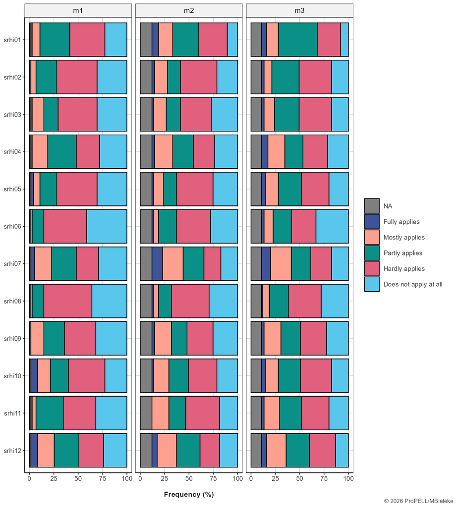

**Scale**

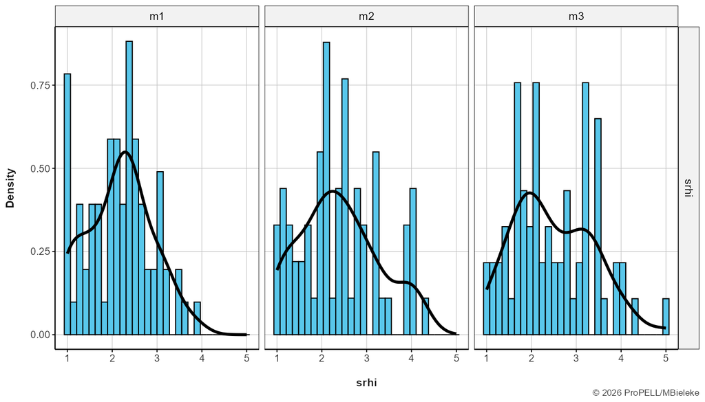

**Statistics**

**Items**

| Variable | N | #Valid | %Valid | Mean | SD | Min | Median | Max |
| --- | --- | --- | --- | --- | --- | --- | --- | --- |
| **srhi01** |  |  |  |  |  |  |  |  |
| m1 | 75 | 74 | 98.67 | 2.28 | 0.96 | 1 | 2.0 | 5 |
| m2 | 75 | 66 | 88.00 | 2.74 | 1.11 | 1 | 3.0 | 5 |
| m3 | 75 | 67 | 89.33 | 2.81 | 0.99 | 1 | 3.0 | 5 |
| **srhi02** |  |  |  |  |  |  |  |  |
| m1 | 75 | 74 | 98.67 | 2.01 | 0.87 | 1 | 2.0 | 4 |
| m2 | 75 | 66 | 88.00 | 2.30 | 1.10 | 1 | 2.0 | 5 |
| m3 | 75 | 67 | 89.33 | 2.39 | 1.00 | 1 | 2.0 | 5 |
| **srhi03** |  |  |  |  |  |  |  |  |
| m1 | 75 | 74 | 98.67 | 2.12 | 1.03 | 1 | 2.0 | 5 |
| m2 | 75 | 66 | 88.00 | 2.21 | 1.09 | 1 | 2.0 | 5 |
| m3 | 75 | 67 | 89.33 | 2.42 | 1.03 | 1 | 2.0 | 5 |
| **srhi04** |  |  |  |  |  |  |  |  |
| m1 | 75 | 74 | 98.67 | 2.38 | 1.11 | 1 | 2.0 | 5 |
| m2 | 75 | 66 | 88.00 | 2.48 | 1.19 | 1 | 2.0 | 5 |
| m3 | 75 | 67 | 89.33 | 2.58 | 1.26 | 1 | 2.0 | 5 |
| **srhi05** |  |  |  |  |  |  |  |  |
| m1 | 75 | 74 | 98.67 | 2.08 | 1.00 | 1 | 2.0 | 5 |
| m2 | 75 | 66 | 88.00 | 2.15 | 1.03 | 1 | 2.0 | 5 |
| m3 | 75 | 67 | 89.33 | 2.48 | 1.13 | 1 | 2.0 | 5 |
| **srhi06** |  |  |  |  |  |  |  |  |
| m1 | 75 | 74 | 98.67 | 1.73 | 0.73 | 1 | 2.0 | 4 |
| m2 | 75 | 66 | 88.00 | 2.06 | 0.96 | 1 | 2.0 | 5 |
| m3 | 75 | 67 | 89.33 | 2.13 | 1.13 | 1 | 2.0 | 5 |
| **srhi07** |  |  |  |  |  |  |  |  |
| m1 | 75 | 74 | 98.67 | 2.43 | 1.21 | 1 | 2.0 | 5 |
| m2 | 75 | 66 | 88.00 | 2.89 | 1.31 | 1 | 3.0 | 5 |
| m3 | 75 | 67 | 89.33 | 2.82 | 1.29 | 1 | 3.0 | 5 |
| **srhi08** |  |  |  |  |  |  |  |  |
| m1 | 75 | 74 | 98.67 | 1.78 | 0.71 | 1 | 2.0 | 4 |
| m2 | 75 | 66 | 88.00 | 1.98 | 0.94 | 1 | 2.0 | 5 |
| m3 | 75 | 67 | 89.33 | 2.10 | 0.99 | 1 | 2.0 | 5 |
| **srhi09** |  |  |  |  |  |  |  |  |
| m1 | 75 | 74 | 98.67 | 2.16 | 1.03 | 1 | 2.0 | 4 |
| m2 | 75 | 66 | 88.00 | 2.38 | 1.19 | 1 | 2.0 | 5 |
| m3 | 75 | 67 | 89.33 | 2.45 | 1.16 | 1 | 2.0 | 5 |
| **srhi10** |  |  |  |  |  |  |  |  |
| m1 | 75 | 74 | 98.67 | 2.43 | 1.18 | 1 | 2.0 | 5 |
| m2 | 75 | 66 | 88.00 | 2.39 | 1.09 | 1 | 2.0 | 5 |
| m3 | 75 | 67 | 89.33 | 2.49 | 1.11 | 1 | 2.0 | 5 |
| **srhi11** |  |  |  |  |  |  |  |  |
| m1 | 75 | 74 | 98.67 | 2.08 | 0.95 | 1 | 2.0 | 5 |
| m2 | 75 | 66 | 88.00 | 2.38 | 1.03 | 1 | 2.0 | 4 |
| m3 | 75 | 67 | 89.33 | 2.48 | 1.12 | 1 | 2.0 | 5 |
| **srhi12** |  |  |  |  |  |  |  |  |
| m1 | 75 | 74 | 98.67 | 2.57 | 1.23 | 1 | 2.5 | 5 |
| m2 | 75 | 66 | 88.00 | 2.70 | 1.21 | 1 | 3.0 | 5 |
| m3 | 75 | 67 | 89.33 | 2.75 | 1.15 | 1 | 3.0 | 5 |

**Scale**

| Variable | N | #Valid | %Valid | SD | Mean | Min | Median | Max | #Items | Alpha |
| --- | --- | --- | --- | --- | --- | --- | --- | --- | --- | --- |
| **srhi** |  |  |  |  |  |  |  |  |  |  |
| m1 | 75 | 74 | 98.67 | 0.72 | 2.17 | 1 | 2.25 | 3.92 | 12 | 0.91 |
| m2 | 75 | 66 | 88.00 | 0.88 | 2.39 | 1 | 2.33 | 4.25 | 12 | 0.95 |
| m3 | 75 | 67 | 89.33 | 0.89 | 2.49 | 1 | 2.33 | 5.00 | 12 | 0.95 |

**Overview**

- **Variable Stem: `sscs`**
- **Time Points:** m1, m2, m3
- **Reference:** Seelig & Fuchs (2006)

**Details**

**Items**

| Variable | Scale | Prompt |
| --- | --- | --- |
| sscs01 | Intrinsic Motivation | I intend to exert myself physically in the next weeks and months ... because I simply enjoy it. |
| sscs02 | Extrinsic Motivation | I intend to exert myself physically in the next weeks and months ... because people who are important to me pressure me to do so. |
| sscs03 | Identified Motivation | I intend to exert myself physically in the next weeks and months ... because the positive outcomes are worth the effort. |
| sscs04 | Introjected Motivation | I intend to exert myself physically in the next weeks and months ... because otherwise I would blame myself. |
| sscs05 | Intrinsic Motivation | I intend to exert myself physically in the next weeks and months ... because physical exertion is simply part of my life. |
| sscs06 | Extrinsic Motivation | I intend to exert myself physically in the next weeks and months ... because otherwise I would have difficulties with other people. |
| sscs07 | Identified Motivation | I intend to exert myself physically in the next weeks and months ... because it is good for me. |
| sscs08 | Introjected Motivation | I intend to exert myself physically in the next weeks and months ... because otherwise I would feel guilty. |
| sscs09 | Intrinsic Motivation | I intend to exert myself physically in the next weeks and months ... because I have experiences that I would not want to miss. |
| sscs10 | Extrinsic Motivation | I intend to exert myself physically in the next weeks and months ... because others tell me that I should exert myself physically. |
| sscs11 | Identified Motivation | I intend to exert myself physically in the next weeks and months ... because I have good reasons for doing so. |
| sscs12 | Introjected Motivation | I intend to exert myself physically in the next weeks and months ... because I think that sometimes you have to force yourself to do something. |

Note. Variables with * have been reverse-coded

**Scale**

[output not shown]

**Distribution**

**Items**

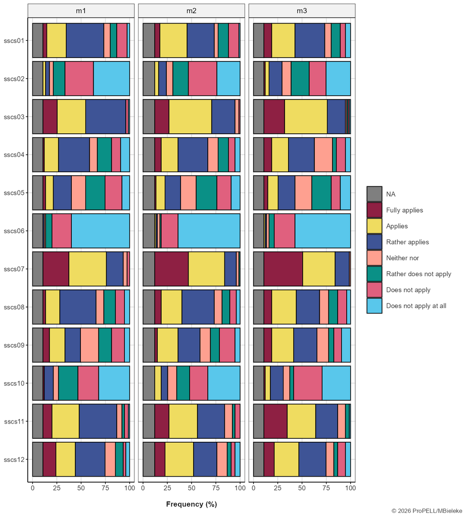

**Scale**

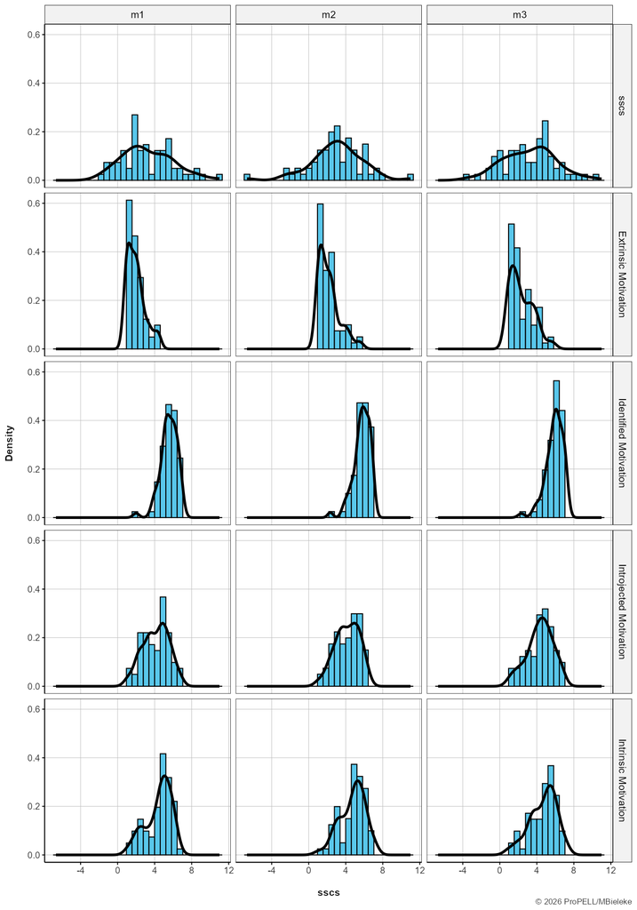

**Statistics**

**Items**

| Variable | N | #Valid | %Valid | Mean | SD | Min | Median | Max |
| --- | --- | --- | --- | --- | --- | --- | --- | --- |
| **sscs01** |  |  |  |  |  |  |  |  |
| m1 | 75 | 67 | 89.33 | 4.61 | 1.49 | 1 | 5.0 | 7 |
| m2 | 75 | 66 | 88.00 | 4.73 | 1.54 | 1 | 5.0 | 7 |
| m3 | 75 | 67 | 89.33 | 4.75 | 1.61 | 1 | 5.0 | 7 |
| **sscs02** |  |  |  |  |  |  |  |  |
| m1 | 75 | 67 | 89.33 | 2.06 | 1.28 | 1 | 2.0 | 6 |
| m2 | 75 | 66 | 88.00 | 2.52 | 1.44 | 1 | 2.0 | 6 |
| m3 | 75 | 67 | 89.33 | 2.84 | 1.64 | 1 | 3.0 | 7 |
| **sscs03** |  |  |  |  |  |  |  |  |
| m1 | 75 | 67 | 89.33 | 5.51 | 1.12 | 1 | 5.0 | 7 |
| m2 | 75 | 66 | 88.00 | 5.74 | 0.90 | 2 | 6.0 | 7 |
| m3 | 75 | 67 | 89.33 | 5.82 | 1.11 | 1 | 6.0 | 7 |
| **sscs04** |  |  |  |  |  |  |  |  |
| m1 | 75 | 67 | 89.33 | 4.04 | 1.65 | 1 | 5.0 | 7 |
| m2 | 75 | 66 | 88.00 | 4.52 | 1.60 | 1 | 5.0 | 7 |
| m3 | 75 | 67 | 89.33 | 4.52 | 1.63 | 1 | 5.0 | 7 |
| **sscs05** |  |  |  |  |  |  |  |  |
| m1 | 75 | 67 | 89.33 | 3.60 | 1.59 | 1 | 3.0 | 7 |
| m2 | 75 | 66 | 88.00 | 3.55 | 1.56 | 1 | 3.0 | 7 |
| m3 | 75 | 67 | 89.33 | 3.78 | 1.67 | 1 | 4.0 | 7 |
| **sscs06** |  |  |  |  |  |  |  |  |
| m1 | 75 | 67 | 89.33 | 1.48 | 0.82 | 1 | 1.0 | 5 |
| m2 | 75 | 66 | 88.00 | 1.45 | 0.98 | 1 | 1.0 | 6 |
| m3 | 75 | 67 | 89.33 | 1.58 | 1.02 | 1 | 1.0 | 6 |
| **sscs07** |  |  |  |  |  |  |  |  |
| m1 | 75 | 67 | 89.33 | 5.90 | 1.07 | 2 | 6.0 | 7 |
| m2 | 75 | 66 | 88.00 | 6.15 | 0.88 | 3 | 6.0 | 7 |
| m3 | 75 | 67 | 89.33 | 6.25 | 0.79 | 4 | 6.0 | 7 |
| **sscs08** |  |  |  |  |  |  |  |  |
| m1 | 75 | 67 | 89.33 | 4.31 | 1.54 | 1 | 5.0 | 7 |
| m2 | 75 | 66 | 88.00 | 4.71 | 1.54 | 1 | 5.0 | 7 |
| m3 | 75 | 67 | 89.33 | 4.66 | 1.66 | 1 | 5.0 | 7 |
| **sscs09** |  |  |  |  |  |  |  |  |
| m1 | 75 | 67 | 89.33 | 4.13 | 1.70 | 1 | 4.0 | 7 |
| m2 | 75 | 66 | 88.00 | 4.18 | 1.70 | 1 | 5.0 | 7 |
| m3 | 75 | 67 | 89.33 | 4.49 | 1.80 | 1 | 5.0 | 7 |
| **sscs10** |  |  |  |  |  |  |  |  |
| m1 | 75 | 67 | 89.33 | 2.37 | 1.42 | 1 | 2.0 | 7 |
| m2 | 75 | 66 | 88.00 | 2.52 | 1.62 | 1 | 2.0 | 6 |
| m3 | 75 | 67 | 89.33 | 2.63 | 1.73 | 1 | 2.0 | 7 |
| **sscs11** |  |  |  |  |  |  |  |  |
| m1 | 75 | 67 | 89.33 | 5.21 | 1.24 | 1 | 5.0 | 7 |
| m2 | 75 | 66 | 88.00 | 5.33 | 1.29 | 2 | 5.5 | 7 |
| m3 | 75 | 67 | 89.33 | 5.63 | 1.24 | 1 | 6.0 | 7 |
| **sscs12** |  |  |  |  |  |  |  |  |
| m1 | 75 | 67 | 89.33 | 4.96 | 1.52 | 1 | 5.0 | 7 |
| m2 | 75 | 66 | 88.00 | 4.98 | 1.59 | 1 | 5.0 | 7 |
| m3 | 75 | 67 | 89.33 | 4.84 | 1.68 | 1 | 5.0 | 7 |

**Scale**

| Variable | N | #Valid | %Valid | SD | Mean | Min | Median | Max | #Items | Alpha |
| --- | --- | --- | --- | --- | --- | --- | --- | --- | --- | --- |
| **sscs** |  |  |  |  |  |  |  |  |  |  |
| m1 | 75 | 67 | 89.33 | 2.74 | 3.24 | -2.00 | 3.00 | 11.00 | 12 | 0.74 |
| m2 | 75 | 66 | 88.00 | 2.83 | 2.99 | -6.67 | 3.17 | 11.00 | 12 | 0.71 |
| m3 | 75 | 67 | 89.33 | 2.79 | 3.22 | -3.33 | 3.67 | 10.33 | 12 | 0.76 |
| **sscsext** |  |  |  |  |  |  |  |  |  |  |
| m1 | 75 | 67 | 89.33 | 0.95 | 1.97 | 1.00 | 1.67 | 4.33 | 3 | 0.70 |
| m2 | 75 | 66 | 88.00 | 1.13 | 2.16 | 1.00 | 1.83 | 5.67 | 3 | 0.77 |
| m3 | 75 | 67 | 89.33 | 1.25 | 2.35 | 1.00 | 2.00 | 5.67 | 3 | 0.78 |
| **sscsidn** |  |  |  |  |  |  |  |  |  |  |
| m1 | 75 | 67 | 89.33 | 0.91 | 5.54 | 2.00 | 5.67 | 7.00 | 3 | 0.70 |
| m2 | 75 | 66 | 88.00 | 0.90 | 5.74 | 2.33 | 6.00 | 7.00 | 3 | 0.83 |
| m3 | 75 | 67 | 89.33 | 0.94 | 5.90 | 2.33 | 6.00 | 7.00 | 3 | 0.86 |
| **sscsinj** |  |  |  |  |  |  |  |  |  |  |
| m1 | 75 | 67 | 89.33 | 1.40 | 4.11 | 1.00 | 4.33 | 6.67 | 3 | 0.85 |
| m2 | 75 | 66 | 88.00 | 1.28 | 4.15 | 1.00 | 4.33 | 6.33 | 3 | 0.72 |
| m3 | 75 | 67 | 89.33 | 1.40 | 4.34 | 1.00 | 4.33 | 6.67 | 3 | 0.76 |
| **sscsint** |  |  |  |  |  |  |  |  |  |  |
| m1 | 75 | 67 | 89.33 | 1.38 | 4.44 | 1.00 | 4.67 | 6.67 | 3 | 0.85 |
| m2 | 75 | 66 | 88.00 | 1.35 | 4.74 | 1.00 | 5.00 | 7.00 | 3 | 0.82 |
| m3 | 75 | 67 | 89.33 | 1.45 | 4.67 | 1.00 | 5.00 | 7.00 | 3 | 0.85 |

### Stage of physical activity behavior change

**Overview**

- **Variable Stem: `stage`**
- **Time Points:** m1, m2, m3
- **Reference:** Marcus et al. (1992)

**Details**

Please choose the statement that best describes your current physical activity behaviour.

**Distribution**

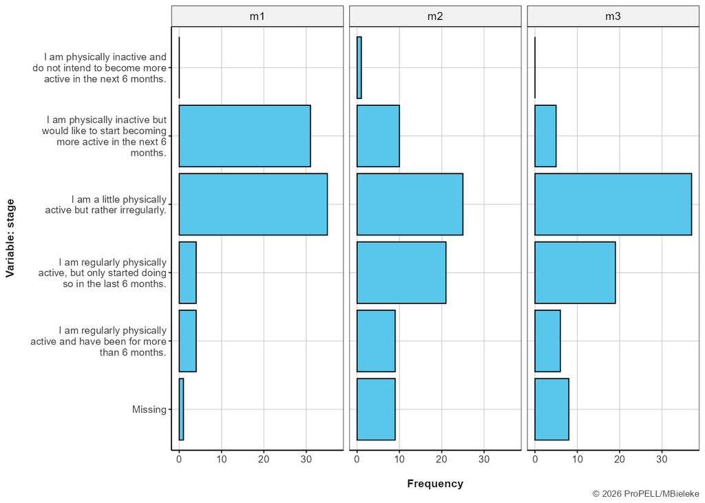

**Statistics**

| Answer | N | % | %Val |
| --- | --- | --- | --- |
| I am physically inactive and do not intend to become more active in the next 6 months. |  |  |  |
| m1 | 0 | 0.0 | 0.0 |
| m2 | 1 | 1.3 | 1.5 |
| m3 | 0 | 0.0 | 0.0 |
| I am physically inactive but would like to start becoming more active in the next 6 months. |  |  |  |
| m1 | 31 | 41.3 | 41.9 |
| m2 | 10 | 13.3 | 15.2 |
| m3 | 5 | 6.7 | 7.5 |
| I am a little physically active but rather irregularly. |  |  |  |
| m1 | 35 | 46.7 | 47.3 |
| m2 | 25 | 33.3 | 37.9 |
| m3 | 37 | 49.3 | 55.2 |
| I am regularly physically active, but only started doing so in the last 6 months. |  |  |  |
| m1 | 4 | 5.3 | 5.4 |
| m2 | 21 | 28.0 | 31.8 |
| m3 | 19 | 25.3 | 28.4 |
| I am regularly physically active and have been for more than 6 months. |  |  |  |
| m1 | 4 | 5.3 | 5.4 |
| m2 | 9 | 12.0 | 13.6 |
| m3 | 6 | 8.0 | 9.0 |
| **Missing** |  |  |  |
| m1 | 1 | 1.3 | --- |
| m2 | 9 | 12.0 | --- |
| m3 | 8 | 10.7 | --- |

### Overall SVSG mean score

**Overview**

- **Variable Stem: `svsg`**
- **Time Points:** m1, m2, m3
- **Reference:** Bertrams et al. (2020)

**Details**

**Items**

**Directions**: Please indicate for each of the following statements how much it applied to you over the past 4 weeks.

| Variable | Prompt |
| --- | --- |
| svsg01 | I feel alive and vital. |
| svsg02 | Sometimes I feel so alive I just want to burst. |
| svsg03 | I have energy and spirit. |
| svsg04 | I nearly always feel alert and awake. |
| svsg05 | I feel energized. |

Note. Variables with * have been reverse-coded

**Scale**

| Variable | Description |
| --- | --- |
| svsg | Overall SVSG mean score |

**Distribution**

**Items**

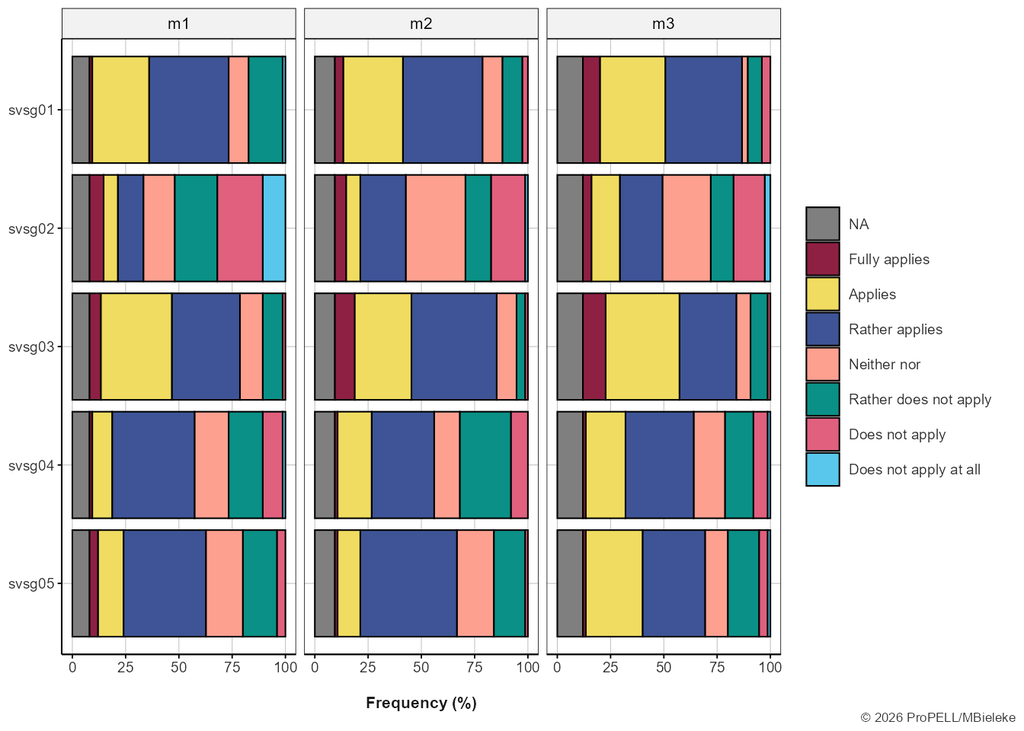

**Scale**

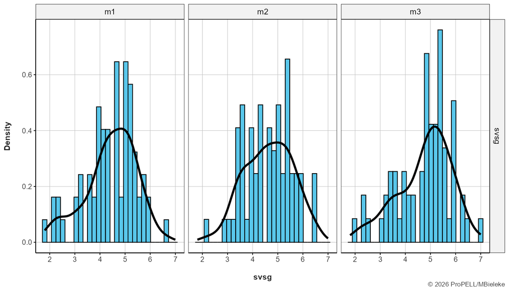

**Statistics**

**Items**

| Variable | N | #Valid | %Valid | Mean | SD | Min | Median | Max |
| --- | --- | --- | --- | --- | --- | --- | --- | --- |
| **svsg01** |  |  |  |  |  |  |  |  |
| m1 | 75 | 69 | 92.00 | 4.81 | 1.17 | 1 | 5 | 7 |
| m2 | 75 | 68 | 90.67 | 5.00 | 1.13 | 2 | 5 | 7 |
| m3 | 75 | 66 | 88.00 | 5.21 | 1.20 | 2 | 5 | 7 |
| **svsg02** |  |  |  |  |  |  |  |  |
| m1 | 75 | 69 | 92.00 | 3.46 | 1.74 | 1 | 3 | 7 |
| m2 | 75 | 68 | 90.67 | 4.03 | 1.43 | 1 | 4 | 7 |
| m3 | 75 | 66 | 88.00 | 4.12 | 1.52 | 1 | 4 | 7 |
| **svsg03** |  |  |  |  |  |  |  |  |
| m1 | 75 | 69 | 92.00 | 5.12 | 1.12 | 2 | 5 | 7 |
| m2 | 75 | 68 | 90.67 | 5.26 | 1.03 | 2 | 5 | 7 |
| m3 | 75 | 66 | 88.00 | 5.33 | 1.17 | 2 | 6 | 7 |
| **svsg04** |  |  |  |  |  |  |  |  |
| m1 | 75 | 69 | 92.00 | 4.25 | 1.28 | 1 | 5 | 7 |
| m2 | 75 | 68 | 90.67 | 4.28 | 1.31 | 2 | 5 | 7 |
| m3 | 75 | 66 | 88.00 | 4.48 | 1.32 | 1 | 5 | 7 |
| **svsg05** |  |  |  |  |  |  |  |  |
| m1 | 75 | 69 | 92.00 | 4.55 | 1.18 | 2 | 5 | 7 |
| m2 | 75 | 68 | 90.67 | 4.59 | 1.00 | 2 | 5 | 7 |
| m3 | 75 | 66 | 88.00 | 4.68 | 1.31 | 1 | 5 | 7 |

**Scale**

| Variable | N | #Valid | %Valid | SD | Mean | Min | Median | Max | #Items | Alpha |
| --- | --- | --- | --- | --- | --- | --- | --- | --- | --- | --- |
| **svsg** |  |  |  |  |  |  |  |  |  |  |
| m1 | 75 | 69 | 92.00 | 1.02 | 4.44 | 1.8 | 4.6 | 6.6 | 5 | 0.83 |
| m2 | 75 | 68 | 90.67 | 0.95 | 4.63 | 2.2 | 4.6 | 6.4 | 5 | 0.85 |
| m3 | 75 | 66 | 88.00 | 1.07 | 4.77 | 2.0 | 5.0 | 7.0 | 5 | 0.88 |

### Overall THISQ mean score

**Overview**

- **Variable Stem: `thisq`**
- **Time Points:** m1, m2, m3
- **Reference:** Vlemincx et al. (2021)

**Details**

**Items**

**Directions**: Below you will find a series of statements about physical sensations. Please indicate how often each statement applies to you in your daily life.

| Variable | Scale | Prompt |
| --- | --- | --- |
| thisq01 | Cardiorespiratory Activation | When I make a light physical effort, I notice that my breathing is faster than normal. |
| thisq02 | Cardiorespiratory Activation | When I am moderately physically active I feel that my heart beats fast. |
| thisq03 | Cardiorespiratory Activation | During a moderately intense physical effort, I feel that I breathe fast and deep. |
| thisq04 | Cardiorespiratory Activation | I notice when my heart is racing. |
| thisq05 | Cardiorespiratory Activation | During a light physical effort, I feel my heart beat. |
| thisq06 | Cardiorespiratory Activation | I notice when I pant. |
| thisq07 | Cardiorespiratory Deactivation | When I relax, I feel that my breathing slows down. |
| thisq08 | Cardiorespiratory Deactivation | When I come to rest, I feel my heart rate slow down. |
| thisq09 | Cardiorespiratory Deactivation | When I am relaxed, I notice that my heart rate is slow. |
| thisq10 | Cardiorespiratory Deactivation | When I feel well-rested, I notice that I breathe slowly. |
| thisq11 | Cardiorespiratory Deactivation | When I rest after a physical effort, I feel my heart rate decrease. |
| thisq12 | Cardiorespiratory Deactivation | Before I fall asleep, I feel that my breathing is slow and deep. |

Note. Variables with * have been reverse-coded

**Scale**

| Variable | Description |
| --- | --- |
| thisq | Overall THISQ mean score |
| thisqca | Mean score of Cardiorespiratory Activation items |
| thisqcd | Mean score of Cardiorespiratory Deactivation items |

**Distribution**

**Items**

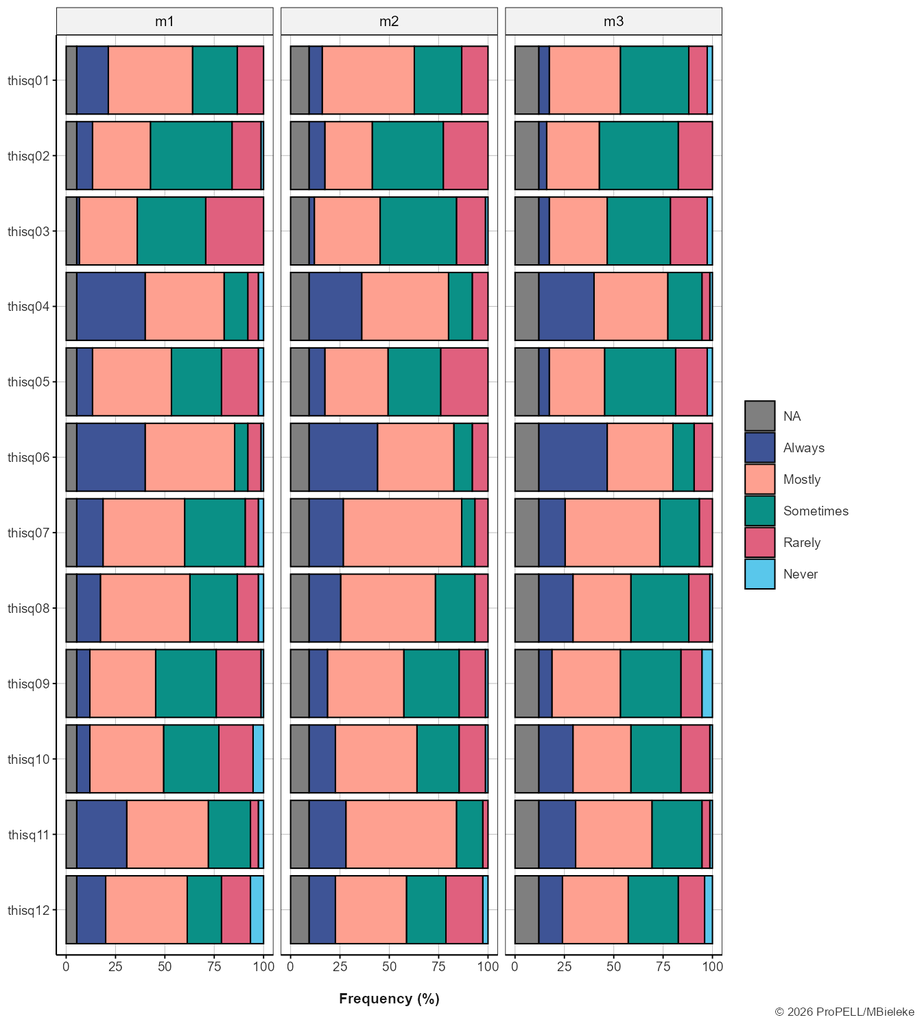

**Scale**

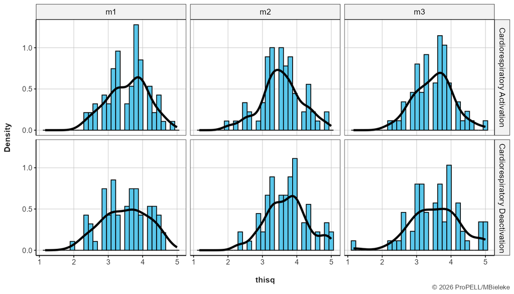

**Statistics**

**Items**

| Variable | N | #Valid | %Valid | Mean | SD | Min | Median | Max |
| --- | --- | --- | --- | --- | --- | --- | --- | --- |
| **thisq01** |  |  |  |  |  |  |  |  |
| m1 | 75 | 71 | 94.67 | 3.65 | 0.93 | 2 | 4 | 5 |
| m2 | 75 | 68 | 90.67 | 3.51 | 0.84 | 2 | 4 | 5 |
| m3 | 75 | 66 | 88.00 | 3.36 | 0.87 | 1 | 3 | 5 |
| **thisq02** |  |  |  |  |  |  |  |  |
| m1 | 75 | 71 | 94.67 | 3.30 | 0.88 | 1 | 3 | 5 |
| m2 | 75 | 68 | 90.67 | 3.19 | 0.92 | 2 | 3 | 5 |
| m3 | 75 | 66 | 88.00 | 3.20 | 0.81 | 2 | 3 | 5 |
| **thisq03** |  |  |  |  |  |  |  |  |
| m1 | 75 | 71 | 94.67 | 3.03 | 0.83 | 2 | 3 | 5 |
| m2 | 75 | 68 | 90.67 | 3.24 | 0.81 | 1 | 3 | 5 |
| m3 | 75 | 66 | 88.00 | 3.18 | 0.94 | 1 | 3 | 5 |
| **thisq04** |  |  |  |  |  |  |  |  |
| m1 | 75 | 71 | 94.67 | 4.04 | 0.99 | 1 | 4 | 5 |
| m2 | 75 | 68 | 90.67 | 3.99 | 0.89 | 2 | 4 | 5 |
| m3 | 75 | 66 | 88.00 | 3.98 | 0.92 | 1 | 4 | 5 |
| **thisq05** |  |  |  |  |  |  |  |  |
| m1 | 75 | 71 | 94.67 | 3.34 | 0.98 | 1 | 4 | 5 |
| m2 | 75 | 68 | 90.67 | 3.26 | 0.96 | 2 | 3 | 5 |
| m3 | 75 | 66 | 88.00 | 3.20 | 0.92 | 1 | 3 | 5 |
| **thisq06** |  |  |  |  |  |  |  |  |
| m1 | 75 | 71 | 94.67 | 4.11 | 0.92 | 1 | 4 | 5 |
| m2 | 75 | 68 | 90.67 | 4.10 | 0.92 | 2 | 4 | 5 |
| m3 | 75 | 66 | 88.00 | 4.06 | 0.97 | 2 | 4 | 5 |
| **thisq07** |  |  |  |  |  |  |  |  |
| m1 | 75 | 71 | 94.67 | 3.59 | 0.92 | 1 | 4 | 5 |
| m2 | 75 | 68 | 90.67 | 3.97 | 0.75 | 2 | 4 | 5 |
| m3 | 75 | 66 | 88.00 | 3.77 | 0.80 | 2 | 4 | 5 |
| **thisq08** |  |  |  |  |  |  |  |  |
| m1 | 75 | 71 | 94.67 | 3.56 | 0.95 | 1 | 4 | 5 |
| m2 | 75 | 68 | 90.67 | 3.81 | 0.82 | 2 | 4 | 5 |
| m3 | 75 | 66 | 88.00 | 3.58 | 0.99 | 1 | 4 | 5 |
| **thisq09** |  |  |  |  |  |  |  |  |
| m1 | 75 | 71 | 94.67 | 3.23 | 0.94 | 1 | 3 | 5 |
| m2 | 75 | 68 | 90.67 | 3.46 | 0.92 | 1 | 4 | 5 |
| m3 | 75 | 66 | 88.00 | 3.30 | 0.99 | 1 | 3 | 5 |
| **thisq10** |  |  |  |  |  |  |  |  |
| m1 | 75 | 71 | 94.67 | 3.24 | 1.02 | 1 | 3 | 5 |
| m2 | 75 | 68 | 90.67 | 3.57 | 0.97 | 1 | 4 | 5 |
| m3 | 75 | 66 | 88.00 | 3.53 | 1.04 | 1 | 4 | 5 |
| **thisq11** |  |  |  |  |  |  |  |  |
| m1 | 75 | 71 | 94.67 | 3.87 | 0.96 | 1 | 4 | 5 |
| m2 | 75 | 68 | 90.67 | 4.00 | 0.69 | 2 | 4 | 5 |
| m3 | 75 | 66 | 88.00 | 3.79 | 0.89 | 1 | 4 | 5 |
| **thisq12** |  |  |  |  |  |  |  |  |
| m1 | 75 | 71 | 94.67 | 3.45 | 1.14 | 1 | 4 | 5 |
| m2 | 75 | 68 | 90.67 | 3.43 | 1.07 | 1 | 4 | 5 |
| m3 | 75 | 66 | 88.00 | 3.41 | 1.05 | 1 | 4 | 5 |

**Scale**

| Variable | N | #Valid | %Valid | SD | Mean | Min | Median | Max | #Items | Alpha |
| --- | --- | --- | --- | --- | --- | --- | --- | --- | --- | --- |
| **thisqca** |  |  |  |  |  |  |  |  |  |  |
| m1 | 75 | 71 | 94.67 | 0.59 | 3.58 | 2.33 | 3.67 | 4.83 | 6 | 0.70 |
| m2 | 75 | 68 | 90.67 | 0.60 | 3.55 | 2.00 | 3.50 | 4.83 | 6 | 0.76 |
| m3 | 75 | 66 | 88.00 | 0.56 | 3.50 | 2.17 | 3.50 | 5.00 | 6 | 0.68 |
| **thisqcd** |  |  |  |  |  |  |  |  |  |  |
| m1 | 75 | 71 | 94.67 | 0.66 | 3.49 | 2.00 | 3.50 | 4.67 | 6 | 0.75 |
| m2 | 75 | 68 | 90.67 | 0.61 | 3.71 | 2.33 | 3.67 | 5.00 | 6 | 0.78 |
| m3 | 75 | 66 | 88.00 | 0.73 | 3.56 | 1.17 | 3.58 | 5.00 | 6 | 0.86 |

### Mean score of Attitude items

**Overview**

- **Variable Stem: `tpba`**
- **Time Points:** m1, m2, m3
- **Reference:** González et al. (2012)

**Details**

**Items**

| Variable | Scale | Prompt |
| --- | --- | --- |
| tpba01 | Significance | For me, exercising regularly is ... unimportant\|important |
| tpba02 | Pleasantness | For me, exercising regularly is ... unpleasant\|pleasant |
| tpba03 | Purposefulness | For me, exercising regularly is ... meaningless\|meaningful |
| tpba04 | Benefit | For me, exercising regularly is ... harmful\|beneficial |
| tpba05 | Enjoyment | For me, exercising regularly is ... disagreeable\|agreeable |
| tpba06 | Reasonableness | For me, exercising regularly is ... unreasonable\|reasonable |
| tpba07 | Quality | For me, exercising regularly is ... bad\|good |

Note. Variables with * have been reverse-coded

**Scale**

| Variable | Description |
| --- | --- |
| tpba | Mean score of Attitude items |

**Distribution**

**Items**

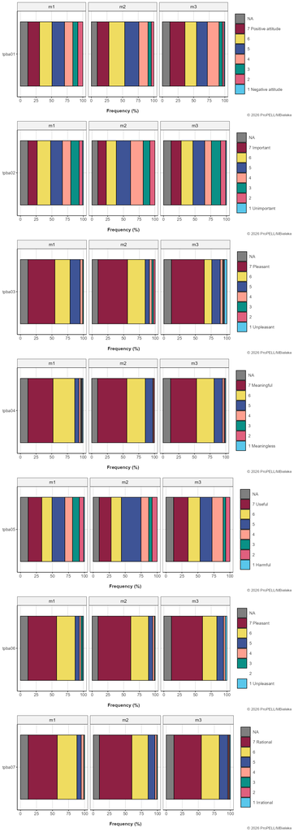

**Scale**

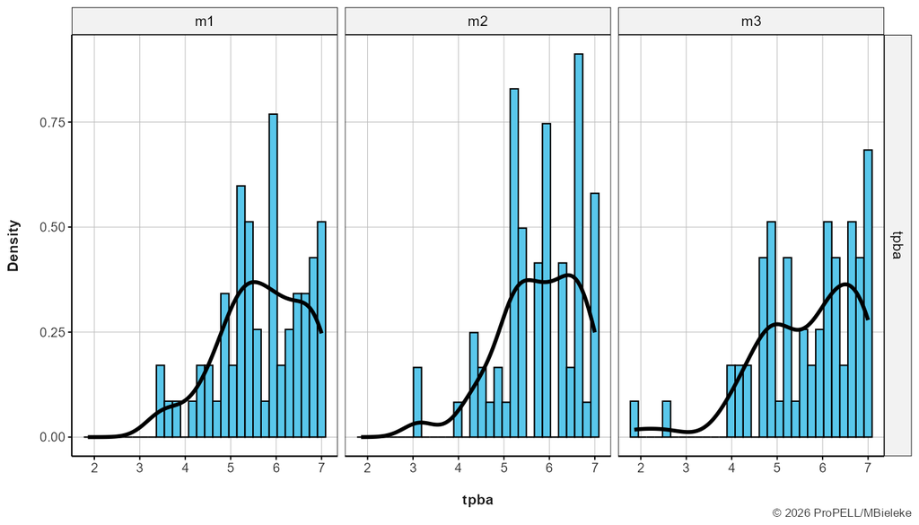

**Statistics**

**Items**

| Variable | N | #Valid | %Valid | Mean | SD | Min | Median | Max |
| --- | --- | --- | --- | --- | --- | --- | --- | --- |
| **tpba01** |  |  |  |  |  |  |  |  |
| m1 | 75 | 66 | 88.00 | 5.05 | 1.56 | 2 | 5 | 7 |
| m2 | 75 | 68 | 90.67 | 5.28 | 1.36 | 2 | 5 | 7 |
| m3 | 75 | 66 | 88.00 | 5.27 | 1.49 | 1 | 5 | 7 |
| **tpba02** |  |  |  |  |  |  |  |  |
| m1 | 75 | 66 | 88.00 | 4.88 | 1.57 | 1 | 5 | 7 |
| m2 | 75 | 68 | 90.67 | 4.75 | 1.49 | 2 | 5 | 7 |
| m3 | 75 | 66 | 88.00 | 4.79 | 1.67 | 1 | 5 | 7 |
| **tpba03** |  |  |  |  |  |  |  |  |
| m1 | 75 | 66 | 88.00 | 6.17 | 0.99 | 3 | 6 | 7 |
| m2 | 75 | 68 | 90.67 | 6.15 | 1.22 | 2 | 7 | 7 |
| m3 | 75 | 66 | 88.00 | 6.02 | 1.57 | 1 | 7 | 7 |
| **tpba04** |  |  |  |  |  |  |  |  |
| m1 | 75 | 66 | 88.00 | 6.14 | 1.19 | 1 | 6 | 7 |
| m2 | 75 | 68 | 90.67 | 6.29 | 0.93 | 2 | 7 | 7 |
| m3 | 75 | 66 | 88.00 | 6.12 | 1.17 | 1 | 6 | 7 |
| **tpba05** |  |  |  |  |  |  |  |  |
| m1 | 75 | 66 | 88.00 | 5.00 | 1.65 | 1 | 5 | 7 |
| m2 | 75 | 68 | 90.67 | 5.07 | 1.48 | 2 | 5 | 7 |
| m3 | 75 | 66 | 88.00 | 5.21 | 1.51 | 2 | 5 | 7 |
| **tpba06** |  |  |  |  |  |  |  |  |
| m1 | 75 | 66 | 88.00 | 6.21 | 1.16 | 1 | 7 | 7 |
| m2 | 75 | 68 | 90.67 | 6.40 | 0.87 | 3 | 7 | 7 |
| m3 | 75 | 66 | 88.00 | 6.23 | 1.24 | 1 | 7 | 7 |
| **tpba07** |  |  |  |  |  |  |  |  |
| m1 | 75 | 66 | 88.00 | 6.30 | 0.91 | 3 | 7 | 7 |
| m2 | 75 | 68 | 90.67 | 6.34 | 0.91 | 3 | 7 | 7 |
| m3 | 75 | 66 | 88.00 | 6.17 | 1.14 | 1 | 6 | 7 |

**Scale**

| Variable | N | #Valid | %Valid | SD | Mean | Min | Median | Max | #Items | Alpha |
| --- | --- | --- | --- | --- | --- | --- | --- | --- | --- | --- |
| **tpba** |  |  |  |  |  |  |  |  |  |  |
| m1 | 75 | 66 | 88.00 | 0.95 | 5.68 | 3.43 | 5.79 | 7 | 7 | 0.84 |
| m2 | 75 | 68 | 90.67 | 0.91 | 5.75 | 3.14 | 5.86 | 7 | 7 | 0.87 |
| m3 | 75 | 66 | 88.00 | 1.11 | 5.69 | 1.86 | 5.93 | 7 | 7 | 0.89 |

### Theory of Planned Behavior - Behavior (TPB-B)

**Overview**

- **Variable Stem: `tpbb`**
- **Time Points:** m1, m2, m3
- **Reference:** González et al. (2012)

**Details**

I exercise regularly.

**Distribution**

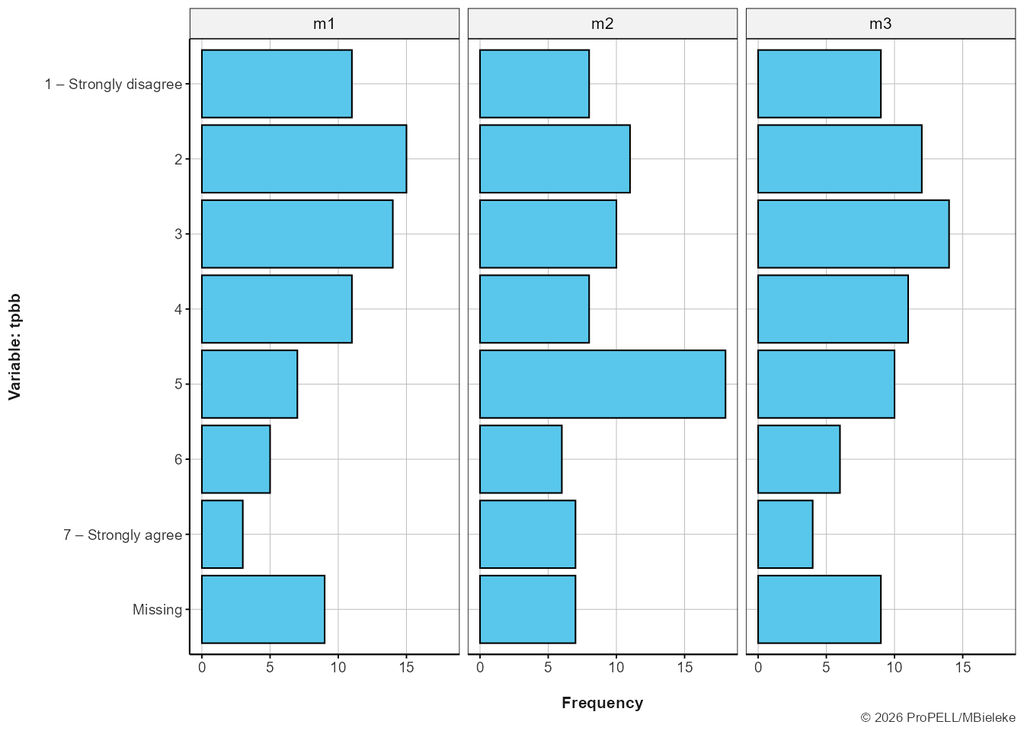

**Statistics**

| Answer | N | % | %Val |
| --- | --- | --- | --- |
| **1 – Strongly disagree** |  |  |  |
| m1 | 11 | 14.7 | 16.7 |
| m2 | 8 | 10.7 | 11.8 |
| m3 | 9 | 12.0 | 13.6 |
| **2** |  |  |  |
| m1 | 15 | 20.0 | 22.7 |
| m2 | 11 | 14.7 | 16.2 |
| m3 | 12 | 16.0 | 18.2 |
| **3** |  |  |  |
| m1 | 14 | 18.7 | 21.2 |
| m2 | 10 | 13.3 | 14.7 |
| m3 | 14 | 18.7 | 21.2 |
| **4** |  |  |  |
| m1 | 11 | 14.7 | 16.7 |
| m2 | 8 | 10.7 | 11.8 |
| m3 | 11 | 14.7 | 16.7 |
| **5** |  |  |  |
| m1 | 7 | 9.3 | 10.6 |
| m2 | 18 | 24.0 | 26.5 |
| m3 | 10 | 13.3 | 15.2 |
| **6** |  |  |  |
| m1 | 5 | 6.7 | 7.6 |
| m2 | 6 | 8.0 | 8.8 |
| m3 | 6 | 8.0 | 9.1 |
| **7 – Strongly agree** |  |  |  |
| m1 | 3 | 4.0 | 4.6 |
| m2 | 7 | 9.3 | 10.3 |
| m3 | 4 | 5.3 | 6.1 |
| **Missing** |  |  |  |
| m1 | 9 | 12.0 | --- |
| m2 | 7 | 9.3 | --- |
| m3 | 9 | 12.0 | --- |

### Mean score of Control items

**Overview**

- **Variable Stem: `tpbc`**
- **Time Points:** m1, m2, m3
- **Reference:** González et al. (2012)

**Details**

**Items**

| Variable | Prompt |
| --- | --- |
| tpbc01 | If I want, I can exercise regularly. |
| tpbc02 | It is entirely up to me whether I exercise regularly. |
| tpbc03 | I am capable of exercising regularly. |
| tpbc04 | I have no difficulties with exercising regularly. |
| tpbc05 | Exercising regularly is something over which I have full control. |

Note. Variables with * have been reverse-coded

**Scale**

| Variable | Description |
| --- | --- |
| tpbc | Mean score of Control items |

**Distribution**

**Items**

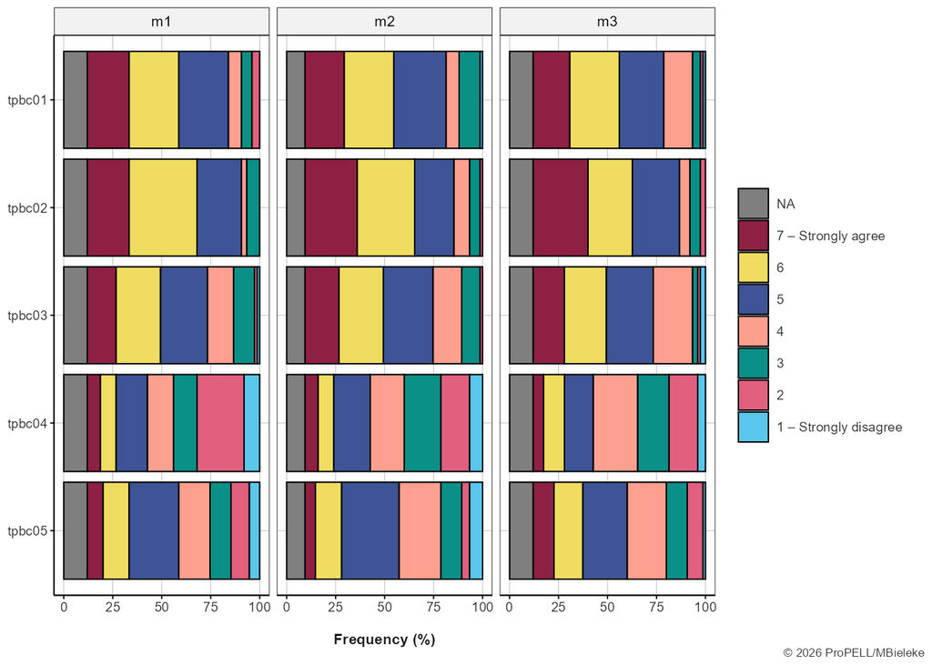

**Scale**

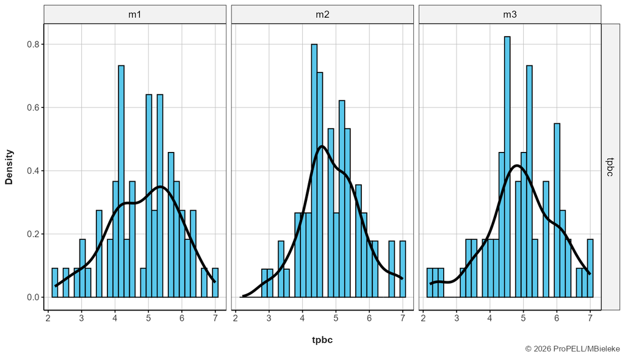

**Statistics**

**Items**

| Variable | N | #Valid | %Valid | Mean | SD | Min | Median | Max |
| --- | --- | --- | --- | --- | --- | --- | --- | --- |
| **tpbc01** |  |  |  |  |  |  |  |  |
| m1 | 75 | 66 | 88.00 | 5.44 | 1.35 | 2 | 6.0 | 7 |
| m2 | 75 | 68 | 90.67 | 5.35 | 1.36 | 1 | 5.5 | 7 |
| m3 | 75 | 66 | 88.00 | 5.35 | 1.33 | 1 | 5.5 | 7 |
| **tpbc02** |  |  |  |  |  |  |  |  |
| m1 | 75 | 66 | 88.00 | 5.70 | 1.11 | 3 | 6.0 | 7 |
| m2 | 75 | 68 | 90.67 | 5.66 | 1.24 | 2 | 6.0 | 7 |
| m3 | 75 | 66 | 88.00 | 5.62 | 1.32 | 2 | 6.0 | 7 |
| **tpbc03** |  |  |  |  |  |  |  |  |
| m1 | 75 | 66 | 88.00 | 5.09 | 1.40 | 1 | 5.0 | 7 |
| m2 | 75 | 68 | 90.67 | 5.22 | 1.30 | 2 | 5.0 | 7 |
| m3 | 75 | 66 | 88.00 | 5.15 | 1.39 | 1 | 5.0 | 7 |
| **tpbc04** |  |  |  |  |  |  |  |  |
| m1 | 75 | 66 | 88.00 | 3.64 | 1.79 | 1 | 3.5 | 7 |
| m2 | 75 | 68 | 90.67 | 3.85 | 1.66 | 1 | 4.0 | 7 |
| m3 | 75 | 66 | 88.00 | 3.94 | 1.58 | 1 | 4.0 | 7 |
| **tpbc05** |  |  |  |  |  |  |  |  |
| m1 | 75 | 66 | 88.00 | 4.35 | 1.65 | 1 | 5.0 | 7 |
| m2 | 75 | 68 | 90.67 | 4.37 | 1.52 | 1 | 5.0 | 7 |
| m3 | 75 | 66 | 88.00 | 4.61 | 1.52 | 1 | 5.0 | 7 |

**Scale**

| Variable | N | #Valid | %Valid | SD | Mean | Min | Median | Max | #Items | Alpha |
| --- | --- | --- | --- | --- | --- | --- | --- | --- | --- | --- |
| **tpbc** |  |  |  |  |  |  |  |  |  |  |
| m1 | 75 | 66 | 88.00 | 1.05 | 4.84 | 2.2 | 5.0 | 7 | 5 | 0.75 |
| m2 | 75 | 68 | 90.67 | 0.88 | 4.89 | 2.8 | 4.8 | 7 | 5 | 0.59 |
| m3 | 75 | 66 | 88.00 | 1.05 | 4.93 | 2.2 | 5.0 | 7 | 5 | 0.79 |

### Mean score of Intention items

**Overview**

- **Variable Stem: `tpbi`**
- **Time Points:** m1, m2, m3
- **Reference:** González et al. (2012)

**Details**

**Items**

| Variable | Prompt |
| --- | --- |
| tpbi01 | I intend to exercise regularly. |
| tpbi02 | I have resolved to exercise regularly. |
| tpbi03 | I will exercise regularly. |
| tpbi04 | My goal is to exercise regularly. |
| tpbi05 | I am determined to exercise regularly. |

Note. Variables with * have been reverse-coded

**Scale**

| Variable | Description |
| --- | --- |
| tpbi | Mean score of Intention items |

**Distribution**

**Items**

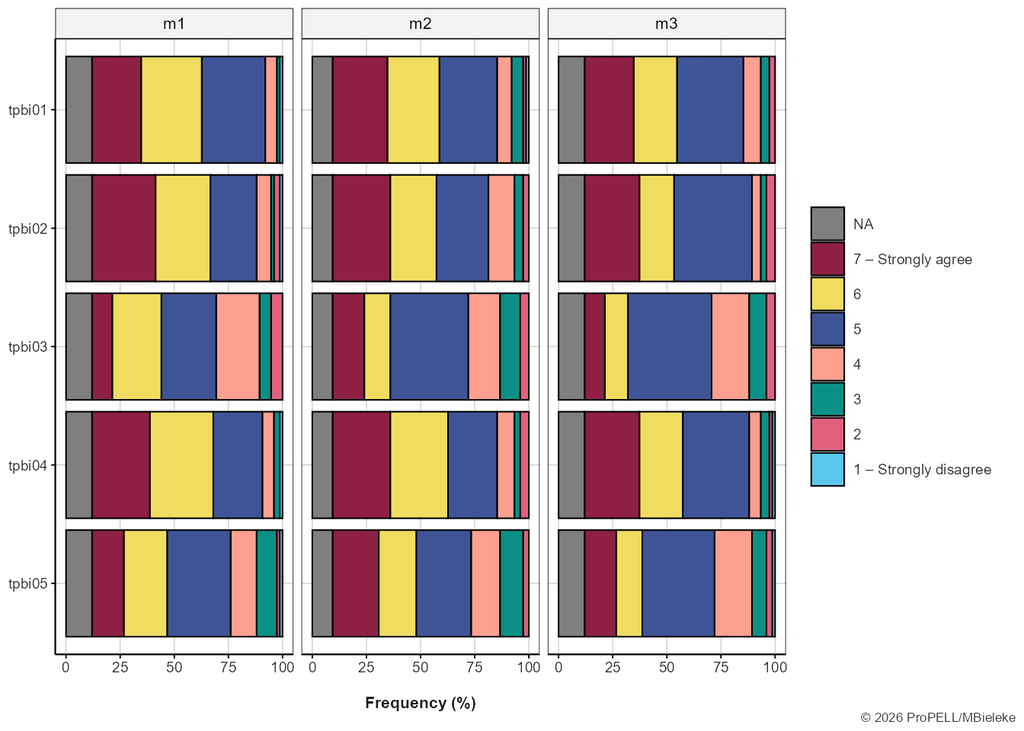

**Scale**

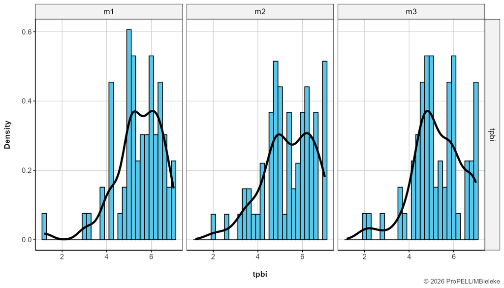

**Statistics**

**Items**

| Variable | N | #Valid | %Valid | Mean | SD | Min | Median | Max |
| --- | --- | --- | --- | --- | --- | --- | --- | --- |
| **tpbi01** |  |  |  |  |  |  |  |  |
| m1 | 75 | 66 | 88.00 | 5.68 | 1.13 | 1 | 6 | 7 |
| m2 | 75 | 68 | 90.67 | 5.53 | 1.34 | 1 | 6 | 7 |
| m3 | 75 | 66 | 88.00 | 5.47 | 1.27 | 2 | 5 | 7 |
| **tpbi02** |  |  |  |  |  |  |  |  |
| m1 | 75 | 66 | 88.00 | 5.70 | 1.35 | 1 | 6 | 7 |
| m2 | 75 | 68 | 90.67 | 5.51 | 1.32 | 2 | 6 | 7 |
| m3 | 75 | 66 | 88.00 | 5.52 | 1.29 | 2 | 5 | 7 |
| **tpbi03** |  |  |  |  |  |  |  |  |
| m1 | 75 | 66 | 88.00 | 4.94 | 1.31 | 2 | 5 | 7 |
| m2 | 75 | 68 | 90.67 | 4.96 | 1.33 | 2 | 5 | 7 |
| m3 | 75 | 66 | 88.00 | 4.82 | 1.23 | 2 | 5 | 7 |
| **tpbi04** |  |  |  |  |  |  |  |  |
| m1 | 75 | 66 | 88.00 | 5.76 | 1.19 | 1 | 6 | 7 |
| m2 | 75 | 68 | 90.67 | 5.60 | 1.32 | 2 | 6 | 7 |
| m3 | 75 | 66 | 88.00 | 5.55 | 1.31 | 1 | 6 | 7 |
| **tpbi05** |  |  |  |  |  |  |  |  |
| m1 | 75 | 66 | 88.00 | 5.11 | 1.36 | 1 | 5 | 7 |
| m2 | 75 | 68 | 90.67 | 5.19 | 1.42 | 2 | 5 | 7 |
| m3 | 75 | 66 | 88.00 | 4.97 | 1.36 | 1 | 5 | 7 |

**Scale**

| Variable | N | #Valid | %Valid | SD | Mean | Min | Median | Max | #Items | Alpha |
| --- | --- | --- | --- | --- | --- | --- | --- | --- | --- | --- |
| **tpbi** |  |  |  |  |  |  |  |  |  |  |
| m1 | 75 | 66 | 88.00 | 1.07 | 5.44 | 1.2 | 5.6 | 7 | 5 | 0.90 |
| m2 | 75 | 68 | 90.67 | 1.16 | 5.36 | 2.0 | 5.4 | 7 | 5 | 0.91 |
| m3 | 75 | 66 | 88.00 | 1.12 | 5.26 | 2.0 | 5.1 | 7 | 5 | 0.92 |